# Platform Requirements

## Electric Motor Editor

[figure not shown]

### Description

The electric motor file defines all parameters relevant for the electric machine. These are the motor’s maximum drive and recuperation torque, the drag torque as well as the electric power map.

### Relative File Paths

It is recommended to use relative filepaths. This way the Job File and all input files can be moved without having to update the paths.

VECTO automatically uses relative paths if the input file (e.g. electric power map) is in the same directory as the Electric Motor File. (The Electric Motor File must be saved before browsing for input files.)

### Main Parameters

**Make and Model**

Free text defining the gearbox model, type, etc.

**EM Type**

Type of the electric motor (ASM, PSM, ESM, RM)

**Inertia [kgm²]**

Rotational inertia of the gearbox (constant for all gears). (Engineering mode only)

**Rated Power [kW]**

The nominal power the electric machine can provide continuously

**Continuous Torque [Nm]**

The nominal torque the electric machine can provide continuously

**Test Speed Continuous Torque [rpm]**

Angular speed at which the continuous torque can be provided

**Overload Torque [Nm]**

Maximum torque above the continuous torque the electric motor can provide for a certain time

**Test Speed Overload Torque [rpm]**

Angular speed at which the overload torque was measured

**Overload Duration [s]**

The time interval the electric machine can operate at its peak performance

**Thermal Overload Recovery Factor**

The accumulated overload energy has to be below the max. overload capacity multiplied by this factor so that the peak power is available again.

**Drag Torque Curve**

The motor’s drag torque over engine speed when the motor is not energized. The torque values in the drag curve have to be negative. (see Electric Motor Drag Curve File (.vemd))

**Max. Drive and Max. Generation Torque Curve**

Torque over engine speed the electric motor can apply on its output shaft. (see Electric Motor Max Torque File (.vemp)). The max drive and max generation torque have to be provided for two different voltage levels.

**Electric Power Consumption Map**

Defines the electric power that is required to provide a certain mechanical power (torque and angular speed) at the motor’s shaft. This map is used to calculate the electric power demand. The electric power consumption map shall cover a torque range exceeding the max. drive and max. generation torque and shall cover the speed range from 0 up to the maximum speed. (see Electric Motor Map (.vemo)). The power map has to be provided for two different voltage levels.

**Voltage Level Low/High**

Applicable voltage level for the electric power consumption map and max drive/generation torque curve

### Chart Area

The Chart Area displays the electric machine’s max. drive curve and max. generation curve (blue), the drag curve (green) and the entries provided in the electric power consumption map (red).

### Controls

**New file**

Create a new empty .vem file

**Open existing file**

Open an existing .vem file

*Save current file*

*Save file as…*

**Send current file to the VECTO Editor**

**Note:** If the current file was opened via the VECTO Editor the file will be sent automatically when saved.

*Open file browser*

*Open file* (see File Open Command).

**Save and close file**

If necessary the file path in the VECTO Editor will be updated.

*Cancel without saving*

## Rechargeable Electric Energy Storage Editor

Two types of rechargeable electric energy storage can be configured in VECTO: either a battery pack or a super capacitor.

### Battery Pack

[figure not shown]

#### Description

The electric energy storage editor allows to edit all model parameters relevant for the electric energy storage.

#### Relative File Paths

It is recommended to use relative filepaths. This way the Job File and all input files can be moved without having to update the paths.

VECTO automatically uses relative paths if the input file (e.g. SoC) is in the same directory as the Battery file. (The Battery File must be saved before browsing for input files.)

#### Main Parameters

**Make and Model**

Free text defining the model, type, etc.

**Capacity [Ah]**

Nominal capacity of the battery

**Testing Temp [°C]**

Battery testing temperature

**Connector Subsystems Included**

Only relevant if representative battery sub-system is tested: Set to ‘true’ if representative cable harness for connecting battery sub-systems was included in testing. Always set to ‘true’ if complete battery system was tested.

**Junctionbox Included**

Only relevant if representative battery sub-system is tested: Set to ‘true’ if representative junction box with shut-off device and fuses was included in testing. Always set to ‘true’ if complete battery system was tested

**SoC min [%]**

Minimum allowed state of charge

**SoC max [%]**

Maximum allowed state of charge

**Max Current Map**

defines the maximum allowed current for a state of charge

**OCV Curve**

Battery internal voltage depending on the battery’s state of charge (see Battery Internal Voltage File (.vbatv))

**Internal Resistance Curve**

Defines the battery’s internal resistance depending on its state of charge. The file must cover the SOC range from 0 to 100%! (see Battery Internal Resistance File (.vbatr))

#### Chart Area

The Chart Area displays the battery’s internal voltage (blue) and the internal resistance (red) over its state of charge.

### SuperCap

[figure not shown]

#### Main Parameters

**Make and Model**

Free text defining the model, type, etc.

**Capacitance [F]**

Nominal capacity of the capacitor

**Min Voltage [V]**

Minimum allowed state of charge

**Max Voltage [v]**

Maximum allowed state of charge

**Internal Resistance [Ω]**

Defines the capacitor’s internal resistance

**Max Current Chg [A]**

Maximum allowed current charge

**Max Current Dischg [A]**

Maximum allowed current discharge

**Testing Temp [°C]**

Super Cap testing temperature

### Controls

**New file**

Create a new empty .vbat file

**Open existing file**

Open an existing .vbat file

*Save current file*

*Save file as…*

**Send current file to the VECTO Editor**

**Note:** If the current file was opened via the VECTO Editor the file will be sent automatically when saved.

*Open file browser*

*Open file* (see File Open Command).

**Save and close file**

If necessary the file path in the VECTO Editor will be updated.

*Cancel without saving*

## IEPC Editor

[figure not shown]

### Description

Integrated electric powertrain component (IEPC) means a combined system of an electric machine system together with the functionality of either a single- or multi-speed gearbox or a differential or both.

An IEPC can be of design-type wheel motor which means that the output shaft (or two output shafts) are directly connected to the wheel hub(s). The IEPC component file defines all parameters relevant for the electric machine. These are the motor’s maximum drive and recuperation torque, the drag torque as well as the electric power map.

An IEPC may have several shiftable transmission steps or only a single gear stage between the output shaft and the electric machine. The electric power consumption map has to be provided for every gear.

### Relative File Paths

It is recommended to use relative filepaths. This way the Job File and all input files can be moved without having to update the paths.

VECTO automatically uses relative paths if the input file (e.g. electric power map) is in the same directory as the Electric Motor File. (The Electric Motor File must be saved before browsing for input files.)

### Main Parameters

**Make and Model**

Free text defining the gearbox model, type, etc.

**EM Type**

Type of the electric motor (ASM, PSM, ESM, RM)

**Inertia [kgm²]**

Rotational inertia of the electric machine at the output shaft of the EM. (Engineering mode only)

**Rated Power [kW]**

The nominal power the electric machine can provide continuously

**Gears**

Gear ratios of the transmission steps of the IEPC

**Continuous Torque [Nm]**

The nominal torque the electric machine can provide continuously

**Continuous Torque Speed [rpm]**

Angular speed at which the continuous torque can be provided

**Overload Torque [Nm]**

Maximum torque above the continuous torque the electric motor can provide for a certain time

**Overload Torque Speed[rpm]**

Angular speed at which the overload torque was measured

**Overload Duration [s]**

The time interval the electric machine can operate at its peak performance

**Thermal Overload Recovery Factor [-]**

The accumulated overload energy has to be below the max. overload capacity multiplied by this factor so that the peak power is available again.

**Full Load Curve**

Torque over speed the IEPC can apply on its output shaft. (see IEPC Max Torque File (.viepcp)). The max drive and max generation torque have to be provided for two different voltage levels.The full load curve is determined at IEPC output shaft using the gear closest to 1 (if two gear ratios have the same distance to a gear ratio of 1, the full load curve shall be declared only for the gear with the higher of the two gear ratios).

**Drag Curves**

The motor’s drag torque over engine speed when the motor is not energized. The torque values in the drag curve have to be negative. (see Electric Motor Drag Curve File (.vemd))

**Power Map Per Gear**

Defines the electric power that is required to provide a certain mechanical power (torque and angular speed) at the motor’s shaft. This map is used to calculate the electric power demand. The electric power consumption map shall cover a torque range exceeding the max. drive and max. generation torque and shall cover the speed range from 0 up to the maximum speed. (see IEPC Map (.viepco)). The power map has to be provided for two different voltage levels and all gears.

**Voltage Level Low/High**

Applicable voltage level for the electric power consumption map and max drive/generation torque curve

### Controls

**New file**

Create a new empty .vem file

**Open existing file**

Open an existing .vem file

*Save current file*

*Save file as…*

**Send current file to the VECTO Editor**

**Note:** If the current file was opened via the VECTO Editor the file will be sent automatically when saved.

*Open file browser*

*Open file* (see File Open Command).

**Save and close file**

If necessary the file path in the VECTO Editor will be updated.

*Cancel without saving*

## IHPC Editor

[figure not shown]

### Description

Integrated hybrid electric vehicle powertrain component (IHPC) means a combined system of multiple electric machine systems together with the functionality of a multi-speed gearbox.

### Relative File Paths

It is recommended to use relative filepaths. This way the Job File and all input files can be moved without having to update the paths.

VECTO automatically uses relative paths if the input file (e.g. electric power map) is in the same directory as the Electric Motor File. (The Electric Motor File must be saved before browsing for input files.)

### Main Parameters

**Make and Model**

Free text defining the gearbox model, type, etc.

**EM Type**

Type of the electric motor (ASM, PSM, ESM, RM)

**Inertia [kgm²]**

Rotational inertia of the electric machine defined at the output shaft of the EM. (Engineering mode only)

**Rated Power [kW]**

The nominal power the electric machine can provide continuously

**Continuous Torque [Nm]**

The nominal torque the electric machine can provide continuously

**Continuous Torque Speed [rpm]**

Angular speed at which the continuous torque can be provided

**Overload Torque [Nm]**

Maximum torque above the continuous torque the electric motor can provide for a certain time

**Overload Torque Speed [rpm]**

Angular speed at which the overload torque was measured

**Overload Duration [s]**

The time interval the electric machine can operate at its peak performance

**Thermal Overload Recovery Factor [-]**

The accumulated overload energy has to be below the max. overload capacity multiplied by this factor so that the peak power is available again.

**Drag Torque Curve**

The motor’s drag torque over engine speed when the motor is not energized. The format is the same as for the normal electric motor (see Electric Motor Drag Curve File (.vemd)), however the values of the drag torque must be set to zero because the drag losses are already included in the IHPC gearbox loss maps due to the virtual split of electric machine and gearbox in the simulation.

**Full Load Curve**

Torque over engine speed the electric motor can apply on its output shaft. (see IEPC Max Torque File (.viepcp)). The max drive and max generation torque have to be provided for two different voltage levels.

**Power Map Per Gear**

Defines the electric power that is required to provide a certain mechanical power (torque and angular speed) at the motor’s shaft. This map is used to calculate the electric power demand. The electric power consumption map shall cover a torque range exceeding the max. drive and max. generation torque and shall cover the speed range from 0 up to the maximum speed. (see IEPC Power Map (.viepco)). The power map has to be provided for two different voltage levels and all gears.

**Voltage Level Low/High**

Applicable voltage level for the electric power consumption map and max drive/generation torque curve

### Controls

**New file**

Create a new empty .vem file

**Open existing file**

Open an existing .vem file

*Save current file*

*Save file as…*

**Send current file to the VECTO Editor**

**Note:** If the current file was opened via the VECTO Editor the file will be sent automatically when saved.

*Open file browser*

*Open file* (see File Open Command).

**Save and close file**

If necessary the file path in the VECTO Editor will be updated.

*Cancel without saving*

## Fuel Cell System Editor

#### Description

**Manufacturer and Model**

Free text defining the model, type, etc.

**Min Electric Power [kW]**

The minimum electric power that can be provided by the fuel cell system

**Max Electric Power [kW]**

The maximum electric power that can be provided by the fuel cell system

**MassFlowMap**

Path to the MassFlowMap file (.vfcm) containing the fuel consumption in g/h depending on the power in kW

#### Massflow Map Graph

In the graph, a preview of the loaded mass flow map file (.vfcm) can be found. The graph only shows the entries of the loaded files, power limits are not considered.

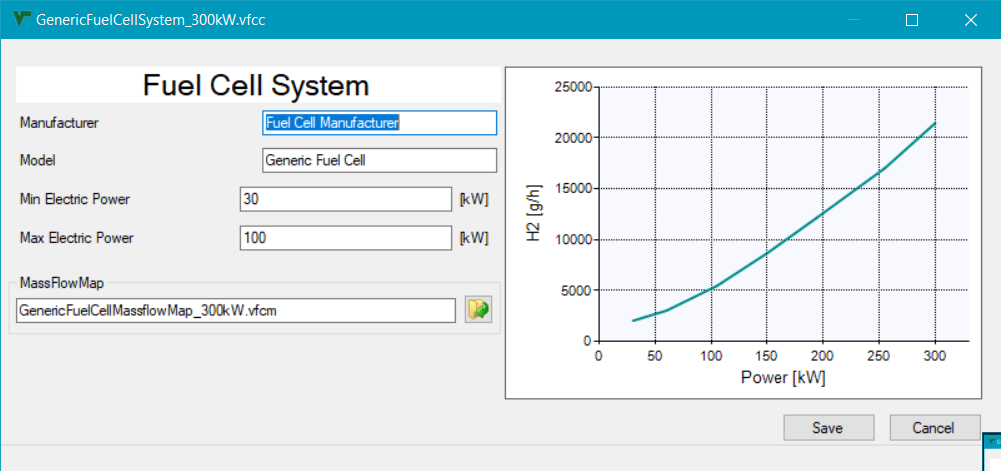

#### Relative File Paths

It is recommended to use relative filepaths. This way the Job File and all input files can be moved without having to update the paths.

## Graph Window

[figure not shown]

### Description

The Graph Window allows to visualize modal results files (.vmod). Multiple windows can be open at the same time to display different files.

Note that the graph does **not** update automatically if the results file has changed.

### Channels

Use the and buttons to add or remove channels. Doubleclick entries to edit existing channels.

Each channel can be plotted either on the left or on the right Y Axis. Use the checkbox to disable channels in the graph.

### X Axis Controls

The X Axis can either show distance or time.

**Min, Max**

Sets the range for the x axis.

**Reset button**

Reset the x axis range to display the complete cycle.

**+, - buttons**

Zoom in/out on the x axis.

**<, > buttons**

Move the x axis range left/right.

### Controls

*Open a .vmod file*

*Open a new Graph Window*

*Reload the currently open file*

## Command Line Arguments

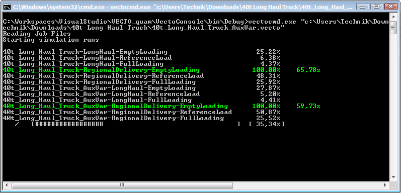

The VECTO 4.x commandline tool can be used to start simulations from the command line and runs without graphical user interface. If multiple job-files are specified or a job-file contains multiple simulation runs (i.e., multiple cycles and/or loadings) these simulations are executed in parallel.

### General Notes

- The order in which the arguments are provided is arbitrary.
- If a file path includes space characters (e.g. “C:\VECTO Test Files\Demo.vecto”) then double quotes have to be used (as in the picture above).
- If not the complete file path is defined (e.g. “file1.vecto” instead of “c:\data\file1.vecto”) then VECTO expects the file in the application directory (where vectocmd.exe is located).
- `ams` command arguments are not arbitrary and should follow the order specified.
- To avoid confirmation for running the simulation in `ams` command prepend yes or no to the tool execution as follows: `"yes"|vectocmd.exe [ARGUMENTS]`

### Basic usage

```
    vectocmd.exe [-h] [-v] [-q] FILE1.(vecto|xml) [FILE2.(vecto|xml) ...]
    vectocmd.exe [-h] [-v] [-q] -ams PREVIOUS_STEP.xml CURRENT_STEP.xml OUTPUT.xml
```

### List of command line arguments

- FILE1.vecto [FILE2.vecto …]: A list of vecto-job files (with the extension: .vecto). At least one file must be given. Delimited by whitespace.
- PREVIOUS_STEP.xml: Previous manufacturing step VIF.
- CURRENT_STEP.xml: Current interim or completed manufacturing step VIF.
- OUTPUT.xml: Output path for the new VIF.
- -ams: Append manufacturing step
- -eng: Switch to engineering mode (implies -mod).
- -mod: Write mod-data in addition to sum-data.
- -1Hz: Convert mod-data to 1Hz resolution.
- -nv: Skip validation of internal data structure before simulation.
- -t: Output information about execution times.
- -v: Shows verbose information (errors and warnings will be displayed).
- -vv: Shows more verbose information (info will be displayed).
- -vvv: Shows debug messages (slow!).
- -vvvv: Shows all verbose information (everything, slow!).
- -q: Disables console output unless verbose information is enabled.
- -V: Show version information.
- -h: Displays this help.

# Calculation Modes

VECTO supports different calculation modes for declaring a vehicle, validation of test-results, or experimenting with different parameters and components. These modes are described here.

- **Declaration Mode**

  In this mode a vehicle can be declared. Many simulation parameters are predefined to provide a generic way of comparing the emissions.
- **Engineering Mode**

  This mode is for experimenting and validation of a vehicle. There exist several options how the driving cycle may be defined (Target speed, Measured Speed, Pwheel).
- **Verification Test Mode**

  This mode is for simulating a vehicle defined in declaration mode for the purpose of verification tests. This mode is similar to the PWheel simulation in engineering mode.
- **Engine Only Mode**

  This mode is for validation of a measured engine component. Only the engine is simulated in this mode.

In the GUI the Calculation Mode can be changed via the Options Tab of the Main Form.

In the Command Line the default Calculation Mode is Declaration, but can be changed to Engineering with the “-eng” flag.

## Engineering Mode

The Engineering Mode lets the user define every aspect in the component models of the vehicle and the driving cycle. This is for experimenting and validation purposes.

In this mode the given list of job files is simulated with the respective driving cycles. Each job file defines a separate vehicle.

### Requirements

- One or more checked job files in the Job List
- Each job file must include at least one driving cycle

### Results

- Modal results (.vmod). One file for each vehicle/cycle combination. Modal results are only written if the modal output is enabled in the ‘Options’ tab on the Main Window
- Sum results (.vsum). One file for each invocation of VECTO.

### Options

The Driving Cycle determines the simulation method in engineering mode. The option depends directly on the driving cycle input and cannot be set explicitly. For more information about the formats see Driving Cycles.

- **Target speed, distance-based**

  This option is the a target vehicle speed distance based cycle (like in Declaration Mode). With this option experiments can be made by the manufacturer.
- **Measured speed, time-based**

  Driving Mode where the actual speed from measurements is simulated.
- **Measured speed with gear, time-based**

  Driving Mode where the actual speed from measurements is simulated. Also defines the chosen gear.
- **Pwheel (SiCo) Mode, time-based**

  In Pwheel mode the measured power at the wheels is given, and the simulation takes that as input.

**Note:** Time-based driving cycles support arbitrary time steps. However, certain actions are simulated within a single simulation interval (e.g. closing the clutch after a gear switch) and may thus result in artifacts during the simulation due to engine inertia, gearbox inertia, etc. Thus **the suggested minimum time interval for time-based cycles is 0.5s!**

## Declaration Mode

In Declaration Mode many input parameters are predefined for the official certification. They are locked in the user interface and will automatically be set by VECTO during calculation. Calculations will be performed for each mission profile (of the corresponding HDV class) with two different loadings: low loading and reference loading.

Declaration Mode can be activated in the Options Tab.

### Requirements

- One or more checked job files in the Job List
- The job files don’t need to include driving cycles. These are automatically assigned.

### Results

- Modal results (.vmod). One file for each vehicle/cycle/loading combination. Modal results are only written if the modal output is enabled in the ‘Options’ tab on the Main Window
- Sum results (.vsum). One file for each invocation of VECTO.
- Results (.xml). One file for each job.

## Verification Test Mode

The purpose of the verification test is to simulate a vehicle defined in declaration mode on a measured real-driving cycle. This simulation mode uses its own cycle format, requiring mainly vehicle speed, wheel speed, wheel torque, engine-fan speed, and engine speed. VECTO then calculates the appropriate gear and simulates the cycle. Auxiliary power is according to the technologies defined in the vehicle. However, the engine fan auxiliary is ignored and the power demand for the engine fan is calcuated based on the engine-fan speed. The power demand for the other auxiliaries depends on the vehicle’s actual speed. The fuel consumption is calculated using the engine speed from the driving cycle and the torque demand as given in the cycle, adding the losses of all powertrain components.

### Requirements

- One or more checked job files in the Job List
- Each job must include a vehicle in declaration mode (XML)
- Each job file must include at least one driving cycle

### Results

- Modal results (.vmod). One file for each vehicle/cycle combination. Modal results are only written if the modal output is enabled in the ‘Options’ tab on the Main Window
- Sum results (.vsum). One file for each invocation of VECTO.

### Requirements

- One or more checked job files in the Job List
- Each job must include a vehicle in declaration mode (XML)
- Each job must include the manufacturer report (XML) of the vehicle as generated for the vehicle declaration
- Each job file must include exactly one driving cycle (in case multiple driving cycles are provided, only the first cycle is simulated!)

### Results

- VTP Report (.xml). Contains a description of the vehicle and its components, the verification test analysis according to the draft legislation, and a validation of the input data digest values
- Modal results (.vmod). One file for each vehicle/cycle combination. Modal results are only written if the modal output is enabled in the ‘Options’ tab on the Main Window
- Sum results (.vsum). One file for each invocation of VECTO.

### Validations

- Before the simulation of the measured VTP cycle starts, the provided cycle data is passed through some sanity checks:
- The cycle is provided in 2Hz
- The ratio of wheel speeds (left/right) should be lower than 1.4 for wheel speeds above 0.1rpm
- The absolute difference of wheel speeds (left/right) should be lower than 1rpm for wheel speeds below 0.1rpm
- The torque ratio (left/right) should be lower than 3 and the absolute difference should be lower than 200Nm.
- The fan speed shall be between 20 and 4000rpm, unless the vehicle is equipped with an electric fan
- The fuel consumption within a window off 10min should be between 180 and 600 g/kWh_(PWheel_pos)

In case the provided cycle exceeds these limits an according warning message is shown in the user interface and written to the report.

## Engine-Only Mode

When this mode is enabled in the Job File then VECTO only calculates the fuel consumption based on a load cycle (engine speed and torque). In the Job File only the following parameters are needed:

- Filepath to the Engine File (.veng)
- Driving Cycles including engine torque (or power) and engine speed

The driving cycle also has to be in a special format which is described here: Engine Only Driving Cycle.

# Simulation Models

In this chapter the used component models for the simulation are described.

- Supported Powertrain Architectures
- Powertrain and Components Structure
- Driver: Acceleration Limiting
- Driver: Look-Ahead Coasting
- ADAS: Overspeed
- ADAS: Engine Stop/Start
- ADAS: Eco Roll
- ADAS: Predictive Cruise Control
- Vehicle: Cross Wind Correction
- Vehicle: Rolling Resistance Coefficient
- Engine: Fuel Consumption Calculation
- Engine: Transient Full Load
- Engine: WHTC Correction Factors
- Fuel properties
- Torque and Speed Limitations
- Gear Shift Model
- Gearbox: AMT Gearshift Rules
- Gearbox: APT Gearshift Rules
- Gearbox: MT Gearshift Rules
- Torque Converter Model
- Auxiliaries
- Engine Only Mode
- Pwheel-Input (SiCo Mode)
- Fuel Cell

## Supported Powertrain Architectures

The following xEV architectures are currently supported in VECTO. All architectures can be used together with the bus auxiliaries model in engineering mode.

### Pure Electric Vehicle Architectures

- E2 + AMT
- E2 + APT-N
- E3
- E4

## Powertrain and Components Structure

The powertrain in Vecto V3 consists of the following components which are generally connected in this order:

[figure not shown]

The engine tries to supply the requested power demand (including all power losses happening in the powertrain and auxiliaries). If the engine can’t supply the given power demand, the driver reduces the accelerating.

### Powertrain Architectures

The following image depicts all Powertrain Architectures covered by VECTO.

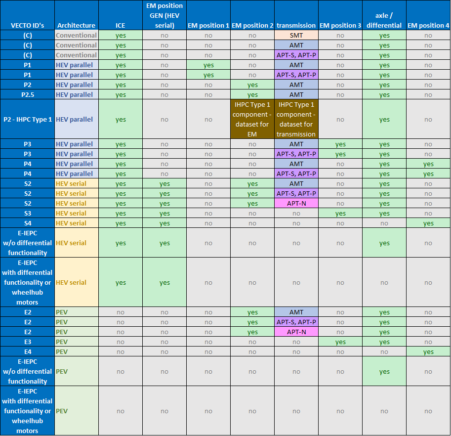

for further details refer to points 10.1.2 and 10.1.3 of Annex III of COMMISSION REGULATION (EU) 2017/2400

### Powertrain Values

The powertrain can be configured to represent different situations depending on the used retarder and gearbox configuration. The output values in the Modfile depict different points in the powertrain depending on the current configuration. Here are some schematic overviews which show the values and the position in the powertrain they represent:

- AMT Transmission Input Retarder
- AMT Transmission Output Retarder
- AT Transmission Input Retarder
- AT Transmission Output Retarder
- Axle

### AMT Transmission Input Retarder

[figure not shown]

### AMT Transmission Output Retarder

[figure not shown]

### AT Transmission Input Retarder

[figure not shown]

### AT Transmission Output Retarder

[figure not shown]

### Axle

[figure not shown]

## Driver: Acceleration Limiting

VECTO limits the vehicle acceleration and deceleration depending on current vehicle speed, to model a realistic driver behavior. These limits are defined in the Acceleration Limiting Input File (.vacc), which can be set in the Job File. In Declaration mode this is already predefined.

- If the engine can’t provide the required power, the vehicle might accelerate slower than the defined driver limit.
- The minimum deceleration can always be maintained via the brakes.
- In Measured Speed Mode these limits are not used, due to the nature of this mode (speeds and accelerations are already real measured values, therefore VECTO uses them directly without limitation).

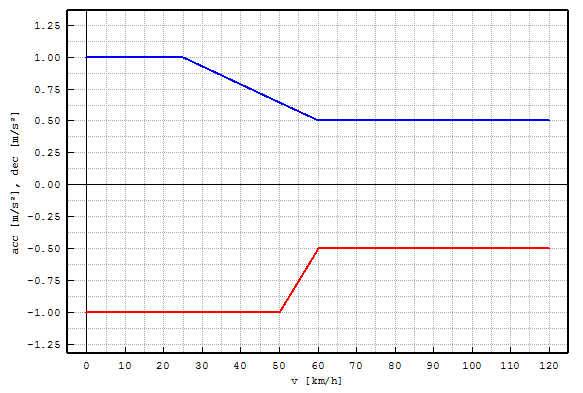

The graph shows the acceleration and deceleration limits depending on the current vehicle speed.

## Driver: Look-Ahead Coasting

Look-Ahead Coasting is a function that aims on modelling real driver behaviour. It is a forward-looking function that detects forthcoming reductions in target speed in the mission profile (e.g. speed limit, etc.) and induces an early deceleration using engine braking before applying mechanical brakes according to the deceleration limit.

[figure not shown]

At the resulting deceleration start point the model calculates the coasting trajectory until it meets the brake deceleration trajectory. The resulting deceleration consists of a coasting phase followed by combined mechanical/engine braking. If Look-Ahead Coasting is disabled only the braking phase according to the deceleration limit will be applied.

Since VECTO 3.0.4 the coasting strategy according to the ACEA White Book 2016 is implemented.

The look ahead coasting functionality represents the driver behavior prior to a deceleration event. Due to information of the route ahead the driver is able to anticipate on the deceleration event by releasing the accelerator pedal.

This pedal release decision is based on an estimation of kinetic and potential (height) energy gain versus the expected dissipated energy due to vehicle resistances during the route section ahead.

For an upcoming target speed change the energy level after the speed change is compared to the vehicle’s current energy level (kinetic and potential energy). The difference of those energy levels is used to estimate the average deceleration force to reach the next target speed. Coasting starts if the vehicle’s (estimated) average resistance force during coasting multiplied by a speed dependent ‘Decision Factor’ becomes smaller than the average deceleration force. (For details on the equations please see the ACEA White Book 2016, Section 8)

The *Decision Factor (DF)* depends on the next target speed and the speed change:

$DF_{Coasting} = 2.5 - 1.5 * DF_{vel} * DF_{vdrop}$

whereas $DF_{vel}$ and $DF_{vdrop}$ are speed dependent and speed change dependent lookup curves, giving a value from 0 and 1.

For the look ahead coasting target speed changes within the preview distance are considered.

$preview distance [m] = 10 * vehicle speed [km/h]$

**Parameters in Job File:**

- **PreviewDistanceFactor**
- **DF_offset**: offset in the equation for DF<sub>coasting</sub> (default 2.5)
- **DF_scaling**: factor in the equation for DF<sub>coasting</sub> (default 1.5)
- **Decision Factor - Target Speed**: csv file for DF<sub>vel</sub> lookup (see below)
- **Decision Factor - Velocity Drop**: csv file for DF<sub>vdrop</sub> lookup (see below)

In engineering mode the parameters can be freely chosen while in declaration mode the default values are used.

[figure not shown]

#### Decision Factor for target velocity lookup (DF<sub>vel</sub>)

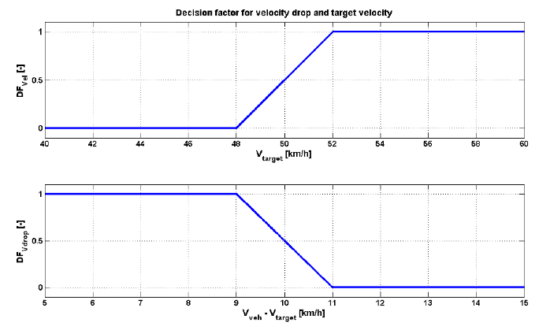

Example (default values):

```
v_target [km/h], decision_factor [-]
0              , 0
48             , 0
52             , 1
100            , 1
```

#### Decision Factor for velocity drop lookup (DF<sub>vdrop</sub>)

Example (default values):

```
v_drop [km/h], decision_factor [-]
-100          , 1
9             , 1
11            , 0
100           , 0
```

## Driver: Overspeed

Overspeed controls the vehicle’s behavior on uneven road sections (slope ≠ 0) and can be configured in the Job File’s Driver Assist Tab. Overspeed is designed to model an average driver’s behavior without the aid of driver assistance systems. Eco-Roll represents an optional driver assistance feature. For this reason vehicles without Eco-Roll should always have the Overspeed function enabled.

Overspeed activates as soon as the total power demand at the wheels (Pwheel) falls below zero, i.e. the vehicle accelerates on a negative slope. The clutch remains closed, engine in motoring operation, and the vehicle accelerates beyond the cycle’s target speed. When the speed limit (target speed plus **Max. Overspeed**) is reached the mechanical brakes are engaged to prevent further acceleration.

[figure not shown]

*Example with target (purple) and actual speed (orange) on the top left axis, slope (brown) on the top right axis. The bottom graph shows engine power (blue), motoring curve (orange) and mechanical brake power (green). In this example Overspeed is allowed until the vehicle’s speed exceeds target speed by 5 [km/h].*

**Parameters in Job File:**

- **Minimum speed [km/h]**. Below this speed the function is disabled.
- **Max. Overspeed [km/h]** (relative to target speed)

## Advanced Driver Assistant Systems: Engine Stop/Start

### Description

If engine stop/start is enabled in the Vehicle, the engine is turned off during vehicle stops to reduce the fuel consumption. During vehicle stops the energy demand for certain auxiliaries and for starting the engine is accumulated. In a post-processing step the final fuel consumption is corrected to consider the energy demand for the auxiliaries and engine start.

### Model Parameters

**Delay engine-off [s]**

if the vehicle stops, the engine is switched off after this timespan

**Max engine-off timespan [s]**

if the engine is switched off at a vehicle halt, the engine is turned on again after this timespan. This basically limits the max. time the engine is switched off at a single engine-off event.

**Engine stop/start utility factor [s]**

In practice, the engine is not switched off at every vehicle stop. This is considered with this utility factor (0…1). Further details are provided below.

- delay engine-off: 2 s
- Max engine-off timespan: 120 s
- Engine stop/start utility factor: 0.8

### Engine Start-Up Energy Demand

The energy demand to ramp-up the engine depends on the engine’s inertia and the engine’s drag torque and is computed according to the following equation:

$E_{ICE,rampUp} = 0.5 * I_{ICE} * n_{idle}^2 + T_{drag}(n_{idle}) * n_{idle} / 2 * t_{ICE,start}$

$E_{ICE,start} = E_{ICE,rampUp} / \eta_{alternator}^2$

### Auxiliaries and Utility Factor

During ICE-off phases the ICE is fully shut of in the simulation (.vmod data). However, in reality the ICE is not always switched off due to certain boundary conditions (e.g. power demand from an auxiliary, temperature, etc.). This is considered in the post-processing. Therefore, the demand for different auxiliaries is balanced in separate columns in the .vmod file for the two cases a) ICE is really off, and b) ICE would be on. This is done for the mechanical auxiliaries, bus-aux electric demand (all different cases like ES connected to the REESS, smart ES, conventional ES, and combinations thereof), bus-aux pneumatic system. A detailed description which auxiliary power demand is balanced in which columns can be found in this spreadsheet for all combinations of conventional vehicles, bus auxiliaries, and hybrid vehicles.

**Auxiliary energy demand**

In Declaration Mode the energy demand of all auxiliaries except the engine cooling fan and the steering pump is considered during vehicle stops.

**Auxiliary energy demand**

In Engineering Mode the energy demand of the auxiliaries can be specified for the cases: - ICE on - ICE off, vehicle standstill - ICE off, vehicle driving

## Advanced Driver Assistant Systems: Eco-Roll

### Description

Eco-roll is a driver assistant system that automatically decouples the internal combustion engine from the power train during specific downhill driving conditions with low negative slopes. The aim is to save fuel during such phases. VECTO supports eco-roll without engine stop/start and eco-roll with engine stop/start. In the former case, the combustion engine is idling during eco-roll phases while in the latter case the combustion engine is turned off during eco-roll events. For vehicles having eco-roll with engine stop/start the fuel consumption is corrected for the engine stop/start events and the auxiliary power demand during engine-off phases.

In case of AT gearboxes eco-roll can either be performed by shifting to neutral, i.e., disengaging the gearbox, or opening the torque converter lockup clutch. Which option is supported by the transmission needs to be specified in the vehicle configuration.

**Auxiliary energy demand**

In Declaration Mode the energy demand of all auxiliaries is applied in the fuel consumption correction during engine-off periods

**Auxiliary energy demand**

In Engineering Mode the energy demand for the different states - ICE on - Vehicle driving, ICE off - Vehicle standstill, ICE off

can be specified. When the ICE is on, the auxiliary energy demand is directly applied. The auxiliary energy demand during ICE-off phases is corrected in post-processing.

### Model Parameters

**Minimum speed [km/h]**

minimum vehicle speed to allow eco-roll to be activated

**Activation delay [s]**

delay between the point in time when all conditions for an eco-roll event are fulfilled until eco-roll is activated

Upper Acceleration Limit [m/s^2]

- Minimum speed: 60 km/h
- Activation delay: 2s
- Underspeed threshold: 0 km/h

### Eco-Roll Model

**Calculations during simulation**

$a_{veh,est} = \frac{F_{grad}(x) + F_{roll}(x) + F_{aero}(v_{veh})}{m_{veh}}$

**Eco-Roll State Diagram**

The following state diagram depicts when eco-roll is activated during the simulation.

[figure not shown]

## Advanced Driver Assistant Systems: AT Gearbox Eco-Roll Release Lockup Clutch

### Description

Eco-Roll Release Lockup Clutch is a functionality only relevant for APT-transmissions which opens the torque converter lock-up clutch during Eco-roll mode. This allows the engine to operate in coast mode at lower engine speeds and reduces or even eliminates fuel injection. This function is only declareable for pure ICE (conventional) vehicles.

## Advanced Driver Assistant Systems: Predictive Cruise Control

### Description

Predictive cruise control (PCC): systems which optimize the usage of potential energy during a driving cycle based on an available preview of road gradient data and the use of a GPS system. A PCC system declared in the input to the simulation tool shall have a gradient preview distance longer than 1000 meters and cover all following use cases:

**Use Case 1: Crest Coasting**

Approaching a crest the vehicle velocity is reduced before the point where the vehicle starts accelerating by gravity alone compared to the set speed of the cruise control so that the braking during the following downhill phase can be reduced.

**Use Case 2: Accelerating without Engine Power**

During downhill driving with a low vehicle velocity and a high negative slope the vehicle acceleration is performed without any engine power usage so that the downhill braking can be reduced.

**Use Case 3: Dip Coasting**

During downhill driving when the vehicle is braking at the overspeed velocity, PCC increases the overspeed for a short period of time to end the downhill event with a higher vehicle velocity. Overspeed is a higher vehicle speed than the set speed of the cruise control system.

In VECTO a vehicle may either support use cases 1 and 2 or all three use cases.

Predictive cruise control is only considered on highway sections of the simulated driving cycle (see distance-based driving cycle.

In declaration mode, the whole long-haul cycle is considered as highway. Moreover, the section from 29760m to 96753m of the regional delivery cycle is considered as highway.

### Model Parameters

- **Allowed underspeed:** Threshold below the target speed the vehicle’s velocity may be reduced to during a PCC event (use-case 1 & 2, $v_{neg}$)
- **Allowed overspeed:** Threshold above the target speed the vehicle’s velocity may reach during a PCC event (use-case 3)
- **PCC enabling velocity:** Only highway sections of the driving cycle with a target velocity greater than or equal to the enabling velocity are considered for PCC events.
- **Minimum speed:** Minimum vehicle speed for allowing PCC use-case 2
- **Preview distance use case 1:** Preview distance for use-case 1 PCC events. After this distance (estimated) after starting the PCC event the vehicle shall reach the target speed again.
- **Preview distance use case 2:** Preview distance for use-case 2 PCC events. After this distance (estimated) after starting the PCC event the vehicle shall reach the target speed again. This distance is typically shorter than the preview distance for use-case 1 as only the acceleration phase is considered.
- Allowed underspeed: 8 km/h
- Allowed overspeed: 5 km/h
- PCC enabling velocity: 80 km/h
- Minimum speed: 50 km/h
- Preview distance use case 1: 1500 m
- Preview distance use case 2: 1000 m

### Predictive Cruise Control Model Use-cases 1 and 2

**Pre-Processing**

1. In a preprocessing step the road gradient where the vehicle would accelerate on its own is computed for certain velocities. If the vehicle is equipped with eco-roll the powertrain is declutched, otherwise the engine is in full drag. The slope is calculated for every simulated cycle as this values vary with the vehicle’s payload, rolling resistance and air drag.
2. All positions in the driving cycle where the slope is lower than the road gradient required that the vehicle accelerates on its own are marked as potential candidates for PCC events. At this distance the vehicle’s velocity shall be a minimum. Denoted as $x_{v_{low}}$.
3. For every potential PCC event, the end position is marked in the driving cycle. This is the first position in the driving cycle after $x_{v_{low}}$ where the slope is greater than the road gradient required that the vehicle accelerates on its own. Latest at this position the vehicle shall reach the target velocity again. Denoted as $x_{end, max}$
4. For every potential PCC event, the earliest start position is marked. This is calculated as $x_{start} = x_{v_{low}} - d_{preview}$.
5. For every potential PCC event, the vehicle’s energy is calculated: $E(x_{v_{low}}) = m \cdot g \cdot h(x_{v{low}}) + \frac{m \cdot (v_{target}(x_{v_{low}}) - v_{neg})^2}{2}$ $E(x_{end, max}) = m \cdot g \cdot h(x_{end, max}) + \frac{m \cdot v_{target}(x_{end, max})^2}{2}$

**Calculations during simulation**

If the vehicle enters a potential PCC section, the following calculations are performed to decide on starting a PCC event:

1. Current vehicle position: $x$
2. Position in the cycle where the PCC event shall be finished: $x_{end} = min(x + d_{preview}, x_{end, max})$
3. Estimation of coasting resistance force:  
   $F_{coast}(x) = \frac{P_{roll}(x) + P_{aero}(x, v_{target}) + P_{ice, drag} + P_{em, drag}}{v_{target}}$  
   $P_{ice, drag}$ is set to 0 in case the vehicle is equipped with eco-roll and pure electric vehicles. $P_{em,drag}$ is set to 0 for conventional vehicles.
4. Energy demand/gain for coasting from the vehicle’s current position to the point with the minimum velocity $x_{v_{low}}$:  
   $E_{coast, v_{low}} = F_{coast} \cdot (x_{v_{low}} - x)$
5. Energy demand/gain for coasting from the vehicle’s current position to the end of the PCC event $x_{end}$:  
   $E_{coast, x_{end}} = F_{coast} \cdot (x_{end} - x)$
6. Vehicle’s current energy:  
   $E_{veh}(x) = m \cdot g \cdot h(x) + \frac{m \cdot v_{veh}^2}{2}$
7. Vehicle’s energy at the end of a PCC event:  
   $E(x_{end}) = m \cdot g \cdot h(x_{end}) + \frac{m \cdot v_{target}(x_{end})^2}{2}$

**PCC State Diagram**

The following state diagram depicts when a PCC event is activated during the simulation for conventional vehicles.

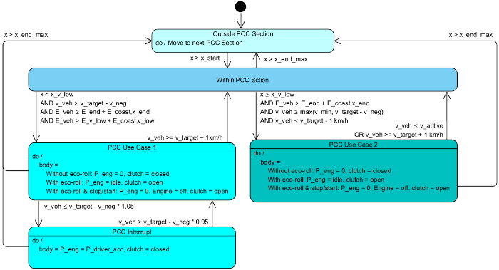

The following state diagram depicts the activation of a PCC event during the simulation for xEV vehicles.

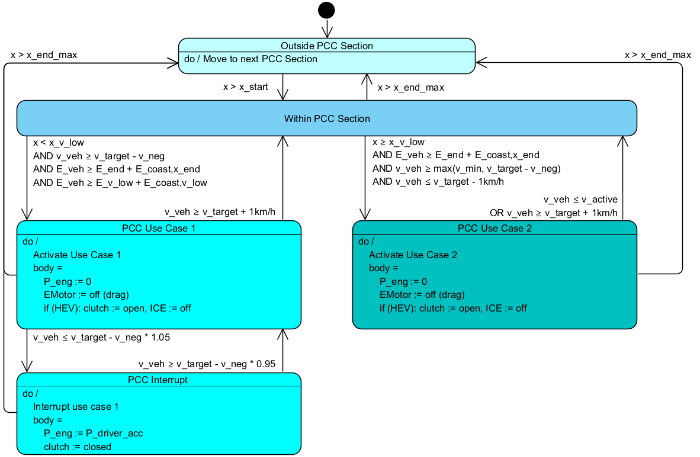

The fuel consumption of vehicles equipped with PCC option 1 & 2 and eco-roll with engine stop/start will be corrected for engine stop/start as described in engine stop/start correction.

### Predictive Cruise Control Model Use-case 3

To consider predictive cruise control use-case 3, the driver model’s allowed overspeed is set to the model parameter *allowed overspeed* in highway sections if the vehicle supports PCC use-case 3.

## Vehicle: Cross Wind Correction

VECTO offers three different modes to consider cross wind influence on the drag coefficient. It is configured in the Vehicle File. The aerodynamic force is calculated according to the following equation:

$F_{aero}=1/2 \rho_{air}(C_{d,v}A(v_{veh})) v_{veh}^2$

The speed dependency of the $C_dA$ value allows for consideration of average cross wind conditions.

### Speed dependent correction (Declaration Mode)

This is the mode which is used in Declaration Mode.

The crosswind correction is based on the following boundary conditions:

1 Average wind conditions: The typical conditions are defined with 3m/s of wind at a height of 4m above ground level, blowing uniformly distributed from all directions. 2 Dependency of $C_dA$ value on yaw angle: The dependency of the $CdA$ value on yaw angle is described by generic $3^{rd}$ order polynomial functions of the form:

$C_dA(\beta) - C_dA(0) = a_1\beta + a_2\beta^2 + a_3\beta^3$

The following table gives the coefficients per vehicle type:

|  | a1 | a2 | a3 |
| --- | --- | --- | --- |
| rigid solo | 0.013526 | 0.017746 | -0.000666 |
| rigid trailer, EMS | 0.017125 | 0.072275 | -0.004148 |
| tractor semitrailer | 0.030042 | 0.040817 | -0.002130 |
| bus, coach | -0.000794 | 0.021090 | -0.001090 |

In a preprocessing step VECTO calculates the function for $C_dA$ value as a function of vehicle speed. This is done by integration of all possible directions of the ambient wind from ground level to maximum vehicle height considering the boundary layer effect based on the following formulas:

$C_{d,v}A(v_{veh}) = \frac{1}{2 \pi v_{veh}^2 h_{veh}}\int_{\alpha = 0^{\circ}}^{\alpha = 360^{\circ}}{\int_{h=0}^{h=h_{veh}}{C_dA(\beta)\cdot v_{air}(h, \alpha)^2} \textit{d}h\ \textit{d}\alpha}$

$v_{air}(h) = \sqrt{(v_{wind}(h)\cdot\cos\alpha + v_{veh})^2 + (v_{wind}(h)\cdot\sin\alpha)^2}$

$v_{wind}(h) = v_{wind}(h_{ref})\cdot \left(\frac{h}{h_{ref}}\right)^{0.2}$

with

$\alpha \ldots \text{direction of ambient wind relative to the vehicle x-axis}$

$h \ldots \text{height above ground}$

$h_{ref} \ldots \text{reference height, 4m, for 3m/s average ambient wind}$

$v_{air} \ldots \text{resulting air flow velocity from vehicle speed and ambient wind}$

$v_{veh} \ldots \text{vehicle speed}$

$v_{wind} \ldots \text{velocity of ambient wind}$

The generation of the $C_{d,v}A(v_{veh})$ curve is demonstrated in this Excel sheet

### Speed dependent correction (User-defined)

The base C<sub>d</sub>A value (see Vehicle File) is corrected with a user-defined speed dependent scaling function. A vcdv-File is needed for this calculation.

The C<sub>d</sub>A value given in the vehicle configuration is corrected depending on the vehicle’s speed and the C<sub>d</sub> scaling factor from the input file as follows:

$C_dA(v_{veh}) = C_dA * F_C_d(v_{veh})$

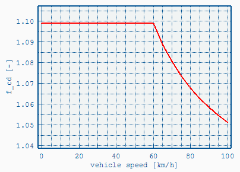

### Correction using Vair & Beta Input

The actual (measured) air speed and direction can be used to correct cross-wind influence if available. A vcdb-File is needed for this calculation. This file defines a ΔC<sub>d</sub>A value in [m²] depending on the wind angle. The driving cycle must include the air speed relative to the vehicle v<sub>air</sub> (<vair_res>) and the wind yaw angle (<vair_beta>).

The C<sub>d</sub>A value given in the vehicle configuration is corrected depending on the wind speed and wind angle (given in the driving cycle) using the input file as follows:

$C_dA(v_veh) = C_dA + {\Delta}C_d(\beta)$

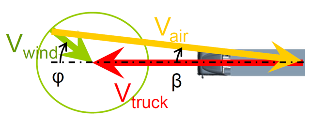

## Vehicle: Rolling Resistance Coefficient

The rolling resistance is calculated using a speed-independent rolling resistance coefficient (RRC). In order to consider that the RRC depends on the vehicle’s mass it is modeled as a function of the total vehicle mass. The total RRC is calculated in VECTO using the following equation (the index i refers to the vehicle’s axle (truck and trailer)):

$RRC = \sum_{i=1}^{n} s_{(i)} \cdot RRC_{ISO(i)} \cdot \left( \frac{s_{(i)} \cdot m \cdot g }{w_{(i)} \cdot F_{zISO(i)} } \right)^{\beta-1}$

with:

| RRC | [-] | Total rolling resistance coefficient used for calculation | [calculated] |
| --- | --- | --- | --- |
| s<sub>(i)</sub> | [-] | Relative axle load. Defined in the Vehicle File. | [user input] |
| RRC<sub>ISO(i)</sub> | [-] | …Tyre RRC according to ISO 28580. Defined in the Vehicle File. | [user input] |
| w<sub>(i)</sub> | [-] | Number of tyres (4 if Twin Tyres, else 2). Defined in the Vehicle File. | [user input] |
| F<sub>zISO(i)</sub> | [N] | Tyre test load according to ISO 28580 (85% of max. load capacity). Defined in the Vehicle File. | [user input] |
| m | [kg] | Vehicle mass plus loading. | [calculated] |
| g | [m/s²] | Earth gravity acceleration (constant = 9.81, Vecto 3.x: 9.80665) | [constant model parameter] |
| β | [-] | Constant parameter = 0.9 | [constant model parameter] |

For each axle the parameters **Relative axle load, RRC<sub>ISO</sub>** and **F<sub>zISO</sub>** have to be defined. Axles with twin tyres have to be marked using the respective checkbox in the Vehicle-Editor.

## Engine: Fuel Consumption Calculation

The base FC value is interpolated from the stationary FC map. If necessary the base value is corrected to compensate for unconsidered auxiliary energy consumption for vehicles with Start/Stop. In Declaration Mode additional correction factors are applied.

The CO<sub>2</sub> result for the actual mission profile is directly derived from the fuel consumption using a gravimetric CO<sub>2</sub>/FC factor.

### Fuel Map Interpolation

The interpolation is based on [Delaunay Triangulation](http://en.wikipedia.org/wiki/Delaunay_triangulation) and works as follows:

1. Triangulate the given rpm/torque/fuel points (= x,y,z) to create a grid of triangles with each point of the map being part of at least one triangle.
2. Find the triangle where the to-be-interpolated load point (x,y) is inside. If no triangle meets the criterion the calculation will be aborted.
3. Calculate the z-value (= fuel) of the given x,y-point in the plane of the triangle

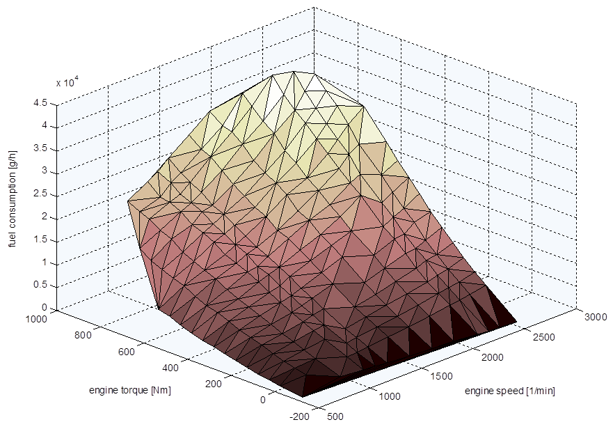

*Delaunay Triangulation Example*

## Engine: Transient Full Load

The engine implements a PT1 behavior to model transient torque build up:

$P_{fld\ dyn_{i}} = \frac{1}{T(n_{i})+1} \cdot \left(P_{fld\ stat}(n_{i})+T(n_{i}) \cdot P_{act_{i-1}}\right)$

with:

- n<sub>i</sub> … current engine speed
- T(n<sub>i</sub>) … PT1 time constant at engine speed n<sub>i</sub> (col. 4 in .vfld file)
- P<sub>fld stat</sub>(n<sub>i</sub>) … Static full load at engine speed n<sub>i</sub> (col. 2 in .vfld file)
- P<sub>act i-1</sub> … Engine power in previous time step

VECTO 3.x uses basically the same PT1 behavior to model transient torque build up. However, due to the dynamic time steps the formula is implemented as follows:

$P_{fld\ dyn_{i}} = P_{fld\ stat}(n_i) \cdot \left(1 - e^{-\frac{t_i^*}{\mathit{PT1}}}\right)$

where t* is computed from the dynamic full-load power in the previous simulation interval:

$t_i^* = t_{i-1}^* + dt$

$t_{i-1}^* = \mathit{PT1} \cdot ln\left(\frac{1}{1 - \frac{P_{eng_{i - 1}}}{P_{fld\ stat}(n_i)}}\right)$

## Engine: Correction Factors

In declaration mode the fuel consumption is corrected as follows:

To prevent inconsistencies of regulated emissions and fuel consumption between the WHTC (hot part) test and the steady state fuel map as well as considering effects of transient engine behavior a “WHTC correction factor” is used.

Based on the target engine operation points of the particular engine in WHTC the fuel consumption is interpolated from the steady state fuel map (“backward calculation”) in each of the three parts of the WHTC separately. The measured specific fuel consumption per WHTC part in [g/kWh] is then divided by the interpolated specific fuel consumption to obtain the “WHTC correction factors” CF<sub>urb</sub> (Urban), CF<sub>rur</sub> (Rural), CF<sub>mot</sub> (Motorway). For the interpolation the same method as for interpolation in VECTO is applied (Delauney triangulation).

All calculations regarding the brake specific fuel consumption from the interpolation as well as from the measurement and the three correction factors CF<sub>urb</sub>, CF<sub>rur</sub>, CF<sub>mot</sub> are fully implemented in the VECTO-Engine evaluation tool.

The total correction factor CF<sub>total</sub> depends on the mission profile and is produced in VECTO by mission profile specific weighting factors listed in the table below.

$CF_{total} = CF_{urb} \cdot WF_{urb} + CF_{rur} \cdot WF_{rur} + CF_{mot} \cdot WF_{mot}$

with the correction factor CF<sub>urb</sub>, CF<sub>rur</sub>, CF<sub>mot</sub> coming from the Engine, and weighting factors WF<sub>urb</sub>, WF<sub>rur</sub>, WF<sub>mot</sub> predefined in the declaration data:

| Mission profile | WF<sub>urb</sub> | WF<sub>rur</sub> | WF<sub>mot</sub> |
| --- | --- | --- | --- |
| Long haul | 0% | 0% | 100% |
| Regional delivery | 17% | 30% | 53% |
| Urban delivery | 69% | 27% | 4% |
| Municipal utility | 98% | 0% | 2% |
| Construction | 62% | 32% | 6% |
| Citybus | 100% | 0% | 0% |
| Interurban bus | 45% | 36% | 19% |
| Coach | 0% | 22% | 78% |

In order to balance the trade-off between emissions and fuel consumption during cold and hot starting conditions an additional balancing factor $CF_{C/H}$ is determined from the overall specific fuel consumption over the cold start and hot start WHTC test. Additional correction factors considered are regarding the net calorific value of the fuel ($CF_{NCV}$) and exhaust after-treatment systems ($CF_{RegPer}$). This values are part of the output from the engine component tool.

$NCV_{stdEngine}$: Net calorific value as defined as reference value for engine testing (Pt. 5.3.3.1 of Annex V), see Fuel properties

$NCV_{stdVECTO}$: Net calorific value defined as reference value for vehicle CO2 certification, see Fuel properties

The WHTC-corrected fuel consumption is then calculated with: $FC_{final} = FC \cdot CF_{total} \cdot CF_{C/H} \cdot CF_{RegPer} \cdot \frac{NCV_{stdEngine}}{NCV_{stdVECTO}}$

In engineering mode a single correction is applied by VECTO. The fuel consumption interpolated from the FC map is multiplied by the engineering correction factor.

$FC_{final} = FC \cdot CF_{Engineering}$

## Dual Fuel Engine

VECTO supports to simulate vehicles equipped with dual-fuel engines, i.e. two different fuels are used simultaneously. Therefore, the engine model contains a second fuel consumption map and VECTO interpolates the fuel consumption from both consumption maps. In the .vmod and .vsum files the consumption of every fuel is reported. The CO2 emissions are the sum of CO2 emissions from both fuels.

In case a WHR system is used with a dual-fuel vehicle the WHR map shall be provided in the fuel consumption map of the primary fuel.

## Torque and Speed Limitations

The torque and speeds in the powertrain can be limited by different components such as the gearbox, the electric motor or the combustion engine, depending on the powertrain configuration.

Some additional limits can be defined in the vehicle configuration as described below.

### Combustion engine limitations / Transmission Limitations

The engine’s maximum speed and maximum torque may be limited by either the gearbox (due to mechanical constraints) or the vehicle control. Engine torque limitations are modeled by limiting the engine full-load curve to the defined maximum torque, i.e., the original engine full-load curve is cropped at the defined maximum torque for a certain gear. Limits regarding the gearbox’ maximum input speed are modeled by intersecting (and limiting) the upshift line with the max. input speed. In the last gear, where no upshifts are possible, the engine speed is limited to the gearbox’ maximum input speed.

Gear shift polygons are calculated by VECTO based on the overall (i.e. from gearbox and vehicle control) cropped engine full load curve.

In Engineering Mode, speed and torque limits can be defined and will be effective for every gear.

In Declaration Mode, the following rules restrict the limitations of engine torque:

#### Transmission Input-Speed Limitations

- Applicable for every gear

#### Transmission Torque Limitations

- For higher 50% of gears (i.e., gears 7 to 12 for a 12-gear transmission):
  - Transmissions max torque > 90% of engine max torque: max. torque limitation *not* applicable (VECTO extrapolates loss-maps)
  - Transmissions max torque <= 90% of engine max torque: max. torque limitation applicable
- For lower 50% of gears (i.e., gears 1 to 6 for a 12-gear transmission):
  - Transmission torque limit is always applicable

#### Vehicle defined Torque Limitations

- For higher 50% of gears (i.e., gears 7 to 12 for a 12-gear transmission):
  - Torque limit > 95% of engine max torque: max. torque limitation *not* applicable (VECTO extrapolates loss-maps)
  - Torque limit <= 95% of engine max torque: max. torque limitation applicable
- For lower 50% of gears (i.e., gears 1 to 6 for a 12-gear transmission):
  - Torque limit is *not* applicable

### Electric Motor Limitations

The electric motor’s maximum drive and maximum recuperation curve can be overridden in the vehicle. Therefore, the same map for maximum drive and maximum recuperation needs to be provided. Such a limit directly overrides the electric motors model parameters.

### Vehicle Propulsion Limitations

For hybrid electric vehicles the electric machine may provide additional torque to the powertrain and thus cause higher accelerations than a conventional vehicle. To limit such boosting by the electric motor.

The input is the additional torque the electric motor is allowed to boost in addition to the ICE over ICE speed.

*Note:* this boosting torque has to be provided from 0 rpm up to the max. ICE speed. The angular speed refers to the gearbox input shaft.

#### Example 1: No boosting

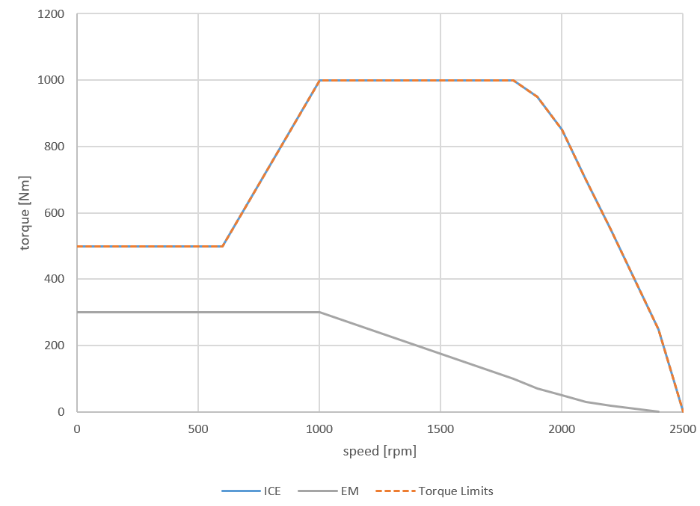

The blue curve shows the ICE’s full-load curve and the gray line represents the electric motors max drive torque.

If the electric motor shall not be allowed to provide additional torque beyond the ICE’s full-load curve the input for the boosting limitation looks as follows:

```
n [rpm] , T_drive [Nm]
0       , 0
2500    , 0
```

For speeds below idle speed the full-load torque available from the ICE equals the ICE full-load torque at engine idling speed due to the modeling of the clutch behavior during vehicle starts.

#### Example 2:

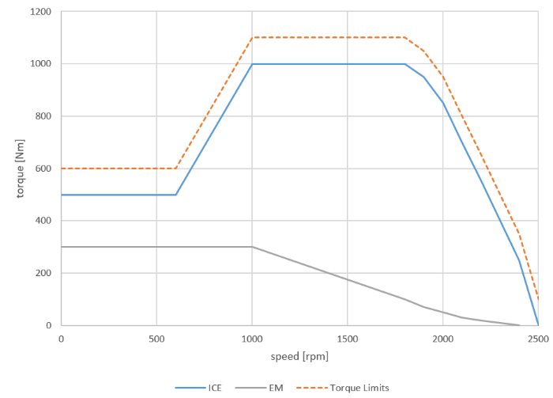

In this example the electric motor is allowed to provide torque in addition to the combustion engine (in this example 100Nm). The boosting limitation for this example looks as follows:

```
n [rpm] , T_drive [Nm]
0       , 100
2500    , 100
```

## Engine Fuel Consumption Correction

The final fuel consumption is corrected in a post-processing to reflect systems not directly modeled in VECTO (e.g. electric waste heat recovery systems) or to account for systems not active all the time for different reasons (e.g., engine stop-start).

### Engine Stop/Start Correction

As the energy demand of auxiliaries is modeled as an average power demand over the whole simulated cycle, the demand of certain auxiliaries during engine-off periods needs to be compensated during engine-on periods. This is done using the Engine-Line approach.

When either the driver model (eco-roll, engine stop/start) or the hybrid controller decides to turn off the combustion engine, it is fully off, i.e. the fuel consumption is 0 and no auxiliary power is provided. In this phases the “missing” auxiliary demand is balanced in separate columns for the cases a) the ICE is really off, and b) the ICE would be on. This allows for an accurate correction of the fuel consumption taking into account that ESS is in reality not active in all possible cases due to e.g. auxiliary power demand, environmental conditions, etc.

A general goal is that the actual auxiliary demand matches the target auxiliary demand over the cycle. So in case the ICE is off, some systems still consume electric energy but no electric energy is generated during ICE-off phases. Or in case of bus auxiliaries the total air demand is pre-calculated and thus leading to an average air demand over the cycle. During ICE-off phases, however, no compressed air is generated. This ‘missing’ compressed air is corrected in the post-processing.

A utility factor (UF) considers that the ICE is not off in all cases. Therefore the fuel consumption for compensating the missing auxiliary demand consists of two parts. The first part considers the fuel consumption required for the ‘missing’ auxiliary demand if the ICE is really off. Here the according auxiliary energy demand is multiplied by the utility factor and the engine line. The second part considers the fuel consumption in case the ICE would not be turned off. Here the ‘missing’ auxiliary energy demand is multiplied by (1 - utility factor) and the engine line and the idle fuel consumption is added for time periods the ICE would be on.

For the post-processing two different utility factors are considered. One for ICE-off phases during vehicle standstill and one for ICE-off phases during driving.

#### ICE Start

$\textrm{E\_ICE\_start} = \sum{\textrm{P\_ICE\_start} \cdot dt}$

$\textrm{FC\_ICE\_start} = \textrm{E\_ICE\_start} \cdot k_\textrm{engline}$

#### Mechanical Auxiliaries

$\textrm{E\_aux\_ESS\_mech\_ICEoff\_standstill} = \sum_{\forall \textrm{v\_act}_i = 0}{\textrm{P\_aux\_ESS\_mech\_ICE\_off} \cdot dt}$

$\textrm{E\_aux\_ESS\_mech\_ICEoff\_driving} = \sum_{\forall \textrm{v\_act}_i > 0}{\textrm{P\_aux\_ESS\_mech\_ICE\_off} \cdot dt}$

$\textrm{E\_aux\_ESS\_mech\_ICEon\_standstill} = \sum_{\forall \textrm{v\_act}_i = 0}{\textrm{P\_aux\_ESS\_mech\_ICE\_on} \cdot dt}$

$\textrm{E\_aux\_ESS\_mech\_ICEon\_driving} = \sum_{\forall \textrm{v\_act}_i > 0}{\textrm{P\_aux\_ESS\_mech\_ICE\_on} \cdot dt}$

$$\begin{align*}
\textbf{\textrm{FC\_ESS}} =\, & \textrm{FC\_ICE\_start} + \\
& \textrm{E\_aux\_ESS\_mech\_ICEoff\_standstill} \cdot
k_\textrm{engline} \cdot \textrm{UF}_\textrm{standstill} + \\
& (\textrm{E\_aux\_ESS\_mech\_ICEon\_standstill} \cdot
k_\textrm{engline} + \textrm{FC}(n_\textrm{idle}, 0) \cdot
\textrm{t\_ICEoff\_standstill}) \cdot (1 -
\textrm{UF}_\textrm{standstill}) \\
& \textrm{E\_aux\_ESS\_mech\_ICEoff\_driving} \cdot
k_\textrm{engline} \cdot \textrm{UF}_\textrm{driving} + \\
& (\textrm{E\_aux\_ESS\_mech\_ICEon\_driving} \cdot
k_\textrm{engline} + \textrm{FC}(n_\textrm{idle}, 0) \cdot
\textrm{t\_ICEoff\_driving}) \cdot (1 - \textrm{UF}_\textrm{driving})
\end{align*}$$

#### Bus Auxiliaries Correction – Electric System

The bus auxiliaries electric system correction is used for conventional vehicles with ESS and buses with smart electric system in the same way.

$\textrm{E\_BusAux\_ES\_consumed} = \sum{\textrm{P\_BusAux\_ES\_consumed} \cdot dt}$

$\textrm{E\_BusAux\_ES\_gen} = \sum{\textrm{P\_BusAux\_ES\_gen} \cdot dt}$

$\Delta\textrm{E\_BusAux\_ES\_mech} = \begin{cases} 0 & \textrm{if Alternator type is none} \\ \frac{\textrm{E\_BusAux\_ES\_consumed} - \textrm{E\_BusAux\_ES\_gen}}{\textrm{AlternatorEfficiency} \cdot \textrm{AlternatorGearEfficiency}} & \textrm{otherwise} \end{cases}$

$\textbf{\textrm{FC\_BusAux\_ES}} = \Delta\textrm{E\_BusAux\_ES\_mech} \cdot k_\textrm{engline}$

*Note:* In case the alternator is simulated without alternator, the power generated by the alternator is always 0 and the auxiliaries are supplied from the high-voltage REESS via the DC/DC converter. In this case, no correction for the electric system needs to be applied because the energy is either taken from the REESS already during the simulation or corrected via DCDC_missing (see below).

#### Bus Auxiliaries Correction – Electric System Supply from REESS

$\textrm{E\_DCDC\_missing} = \textrm{P\_DCDC\_missing} \cdot dt$

$\textrm{E\_DCDC\_missing\_mech} = \textrm{E\_DCDC\_missing} / \textrm{DCDC\_ConverterEfficiency} / \eta_{\textrm{EM}_\textrm{chg}}$

$\textbf{\textrm{FC\_DCDCMissing}} = \textrm{E\_DCDC\_missing\_mech} \cdot k_\textrm{engline}$

#### Bus Auxiliaries Correction – Pneumatic System

For the pneumatic system the goal of the post-processing correction is that the correct amount of compressed air is generated, even when the ICE is off. As the average air demand is calculated with an estimated cycle driving time, the first step is to correct the air demand using the actual cycle driving time. The missing (or excessive) amount of air is transferred into mechanical energy demand using $k_\textrm{Air}$. This value depicts the delta energy demand for a certain delta compressed air. $k_\textrm{Air}$ is derived from two points. on the one hand the compressor runs in idle mode, applying only the drag load and producing no compressed air and the second point is that the compressor is always on, applying the always-on mechanical power demand and generating the maximum possible amount of compressed air. The mechanical energy is then corrected using the engineline (below).

$\textrm{E\_busAux\_PS\_drag} = \sum_{\textrm{Nl\_busAux\_consumed}_i = \textrm{Nl\_busAux\_gen}_i}{\textrm{P\_busAux\_PS\_drag}\cdot dt}$

$\textrm{E\_busAux\_PS\_alwaysOn} = \sum_{\textrm{Nl\_busAux\_consumed}_i = \textrm{Nl\_busAux\_gen}_i}{\textrm{P\_busAux\_PS\_alwaysOn} \cdot dt}$

$\textrm{Nl\_alwaysOn} = \sum_{\textrm{Nl\_busAux\_consumed}_i = \textrm{Nl\_busAux\_gen}_i}{\textrm{Nl\_busAux\_gen\_max}}$

$k_\textrm{Air} = \frac{\textrm{E\_busAux\_PS\_alwaysOn} - \textrm{E\_busAuxPS\_drag}}{\textrm{Nl\_alwaysOn} - 0}$

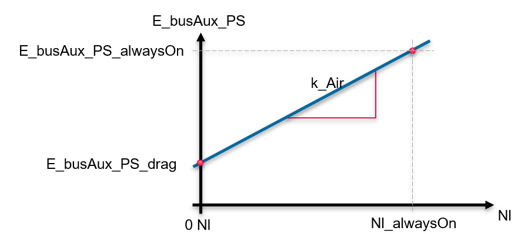

$\textrm{CorrectedAirDemand} = \textrm{[Calculate Air demand with actual cycle time]}$

$\textrm{AirGenerated} = \sum{\textrm{Nl\_busAux\_PS\_gen}}$

$\Delta\textrm{Air} = \textrm{CorrectedAirDemand} - \textrm{AirGenerated}$

$\textrm{E\_busAux\_PS\_corr} = \Delta\textrm{Air} \cdot k_\textrm{Air}$

$\textrm{FC\_BusAux\_PS\_AirDemand} = \textrm{E\_busAux\_PS\_corr} \cdot k_\textrm{engline}$

$\textrm{FC\_BusAux\_PS\_Drag\_ICEoff\_driving} = \textrm{P\_PS\_drag}(n_\textrm{idle}) \cdot k_\textrm{engline} \cdot \textrm{t\_ICEoff\_driving} \cdot (1 - \textrm{UF}_\textrm{driving})$

$\textrm{FC\_BusAux\_PS\_Drag\_ICEoff\_standstill} = \textrm{P\_PS\_drag}(n_\textrm{idle}) \cdot k_\textrm{engline} \cdot \textrm{t\_ICEoff\_standstill} \cdot (1 - \textrm{UF}_\textrm{standstill})$

$$\begin{align*}
\textbf{\textrm{FC\_BusAux\_PS}} =\,
& \textrm{FC\_BusAux\_PS\_AirDemand} + \\
& \textrm{FC\_BusAux\_PS\_Drag\_ICEoff\_driving} + \\
& \textrm{FC\_busAux\_PS\_Drag\_ICEoff\_standstill} \\
\end{align*}$$

#### Bus Auxiliaries Correction – Aux Heater

The power demand for an additional fuel-fired heater is calculated in the post-processing. The HVAC steady state model calculates the heating demand (weighted sum of different climatic conditions) and based on the engine’s average waste heat over the cycle the power demand for the aux heater is calculated. The fuel consumption for the aux heater is only added for the primary fuel:

$E_\textrm{ice,waste heat} = \sum_\textrm{fuels} FC_\textrm{final,sum}(fuel) * NCV_\textrm{fuel}$

$\overline{P}_\textrm{ice,waste heat} = E_\textrm{ice, waste heat} / t_\textrm{cycle}$

$\textrm{E\_auxHeater} = \textrm{HVACSSM}_\textrm{AuxHtr}(\overline{P}_\textrm{ice,waste heat}) * t_\textrm{cycle}$

$\textbf{\textrm{FC\_BusAux\_AuxHeater}} = \textrm{E\_auxHeater} \cdot \textrm{NCV}_\textrm{main fuel}$

#### Waste Heat Recovery Systems

$\textrm{E\_WHR\_mech} = \sum{\textrm{P\_WHR\_mech} \cdot dt}$

$\textrm{E\_WHR\_el} = \sum{\textrm{P\_WHR\_el} \cdot dt}$

$$\textrm{E\_WHR\_el\_mech} = \begin{cases}
\textrm{E\_WHR\_el} / \textrm{AlternatorEfficiency} & \textrm{if
conventional truck} \\
\textrm{E\_WHR\_el} / \eta_{\textrm{EM}_\textrm{chg}} & \textrm{if
bus with ES connected to REES and smart alternator} \\
\textrm{E\_WHR\_el} / \textrm{BusAlternatorEfficiency} &
\textrm{otherwise}
\end{cases}$$

$\textbf{\textrm{FC\_WHR}} = - (\textrm{E\_WHR\_mech} + \textrm{E\_WHR\_el\_mech}) \cdot k_\textrm{engline}$

#### Parallel Hybrid Vehicles: REESS SoC Correction

$$\textbf{\textrm{FC\_SoC}} = -\frac{\Delta\textrm{E\_REESS} \cdot
k_\textrm{engline}}{\eta_{\textrm{EM}_\textrm{chg}} \cdot
\eta_{\textrm{REESS}_\textrm{chg}}}$$

If the REESS Soc at the end of the simulation is lower than the initial SoC the correction is done according to:

$$\textbf{\textrm{FC\_SoC}} = - \Delta\textrm{E\_REESS} \cdot
k_\textrm{engline} \cdot \eta_{\textrm{EM}_\textrm{dischg}} \cdot
\eta_{\textrm{REESS}_\textrm{dischg}}$$

$\eta_{\textrm{REESS}_\textrm{chg}} = \frac{\textrm{E\_REESS\_INT\_CHG}}{\textrm{E\_REEES\_T\_CHG}}$

$\eta_{\textrm{REESS}_\textrm{dischg}} = \frac{\textrm{E\_REESS\_T\_DISCHG}}{\textrm{E\_REEES\_INT\_DISCHG}}$

#### Serial Hybrid Vehicles: REESS SoC Correction

If the REESS Soc at the end of the simulation is different than the initial SoC the correction is done according to:

$FC_\textrm{gen,charging} = \sum{FC_\textrm{mod,final}\cdot dt}$

$E_\textrm{gen,el} = \sum{P_\textrm{em,el}\cdot dt}$

If the GenSet was on during the cycle, the SoC correction is done according to:

$\textrm{FC\_SOC} = \Delta\textrm{E\_REESS} \cdot \frac{FC_\textrm{gen,charging}}{E_\textrm{gen,el}}$

If the GenSet was never on during the cycle, the SoC correction is done according to:

$\textrm{FC\_SOC} = \Delta\textrm{E\_REESS} \cdot \frac{FC_\textrm{gen,optimal}}{E_\textrm{gen,el,optimal}}$

where $FC_\textrm{gen,optimal}$ and $E_\textrm{gen,el,optimal}$ are the fuel consumption and generated electric power in the optimal operating point of the GenSet

### Corrected Total Fuel Consumption

The final fuel consumption after all corrections are applied is calculated as follows:

$$\begin{align*}
\textrm{FC\_FINAL} =\;& \textrm{FC\_ModSum} \;+ \\
& \textrm{FC\_ESS} \;+ \\
& \textrm{FC\_DCDCMissing} \;+ \\
& \textrm{FC\_BusAux\_PS} \;+ \\
& \textrm{FC\_BusAux\_ES} \;+ \\
& \textrm{FC\_WHR} \;+ \\
& \textrm{FC\_BusAux\_AuxHeater} \;+ \\
& \textrm{FC\_SoC} \\
\end{align*}$$

### Engine-Line Approach

The total fuel consumption is corrected in a post-processing step according to the *engine-line* approach. Therefore, for every engine operating point where the engine is on and has a positive fuel consumption the fuel consumption is plotted over the engine power. The slope (k) of the linear regression of the fuel consumption is used to compute the additional fuel that is needed for the energy demand during engine-off periods and engine starts.

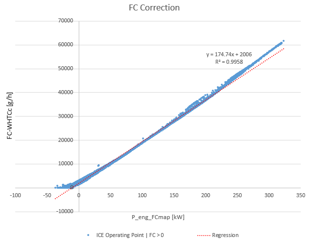

## Engine Waste Heat Recovery Systems

VECTO is able to consider energy recovered from the combustion engine’s waste heat either as mechanical power or as electrical power. The following options for waste-heat recovery system are available:

- Mechanical WHR system included in the FC measurements
- Mechanical WHR system not connected to the crankshaft
- Electrical WHR system

The first type of WHR systems do not require a dedicated simulation as this is already covered in the combustion engine’s fuel consumption map. The output power at the crankshaft is usually higher when such a WHR system is active, or for a certain measurement setpoint (torque and engine speed) the fuel consumption is lower compared to an engine without waste-heat recovery system.

For the other two types of WHR systems where the recovered energy is not directly connected to the engine’s crankshaft the generated power needs to be provided in the combustion engine’s fuel consumption map (see .vmap file. The final fuel consumption is corrected for the latter two WHR systems via the engine-line approach, taking into account the accumulated power generated by the WHR system during the cycle. In case of an electrical WHR system the electric energy is converted to the equivalent mechanical energy that the combustion engine “does not need to provide” considering the alternator’s efficiency.

The power generated by a WHR system is interpolated from the engine’s WHR map (part of the fuel consumption map) multiplied by a correction factor similar to the WHTC correction for the fuel consumption.

## Fuel Properties

| FuelType | Tanksystem | FuelDensity [kg/m3] | CO2 per FuelWeight [kgCo2/kgFuel] | NCV_stdEngine [kJ/kg] | NCV_stdVecto [kJ/kg] | Note |
| --- | --- | --- | --- | --- | --- | --- |
| Diesel CI |  | 836 | 3.13 | 42700 | 42700 |  |
| Ethanol CI |  | 820 | 1.81 | 25700 | 25400 |  |
| Petrol PI |  | 748 | 3.04 | 41500 | 41500 |  |
| Ethanol PI |  | 786 | 2.10 | 29100 | 29300 |  |
| LPG PI |  |  | 3.02 | 46000 | 46000 |  |
| NG PI | compressed |  | 2.69 | 45100 | 48000 | H-Gas |
| NG PI | liquefied |  | 2.77 | 45100 | 49100 | EU mix 2016/2030 |

Specifications are based on an analysis (2018) performed by CONCAWE/EUCAR and shall reflect typical fuel on the European market. The data was in the context of the study: Well-To-Wheels Analysis Of Future Automotive Fuels And Powertrains in the European Context – Heavy Duty vehicles ([doi:10.2760/100379](http://dx.doi.org/10.2760/100379))

### VECTO Input for CNG/LNG Vehicles

Currently only the fuel type ‘NG PI’ for the engine certification is allowed according to Regulation (EU) 2017/2400. For LNG vehicles, therefore, the engine fuel type has to be set to ‘NG PI’ and at the vehicle level NgTankSystem has to be set to ‘liquefied’. For CNG vehicles the same engine fuel type is provided but NgTankSystem has to be set to ‘compressed’.

## Transmission Losses

Every transmission component (gearbox, angledrive, axle gear, …) uses the following formula for calculating the torques at input and output side of the component:

$T_{output} = (T_{input} - T_{loss}) * r_{gear}$

with:

- T<sub>output</sub> … Output torque
- T<sub>input</sub> … Input torque
- T<sub>loss</sub> … Torque loss (from e.g. a loss map or efficiency for that component)
- r<sub>gear</sub> … The transmission ratio for the current gear (if the component has ratios)

The following components are accounted as transmission components (see Powertrain and Components Structure for a complete overview over all components in the powertrain):

- Gearbox
- Axle Gear (see Gearbox)
- Angledrive (see Vehicle)

## Gearbox: AT Gearbox Model

VECTO supports both, AT gearboxes with serial torque converter and AT gearboxes with power split. Internally, both gearbox types are simulated using a power train architecture with the torque converter in series.

[figure not shown]

Automatic transmission with torque converter in series

[figure not shown]

Automatic transmission with parallel torque converter

In the input data Gearbox File **only the mechanical gears need to be specified**. Depending on the gearbox type (AT-S or AT-P) VECTO adds the correct virtual ‘torque converter gear’.

For AT gearbox with serial torque converter, the torque converter uses the same ratio and mechanical losses as the first gear (and second, depending on the gear ratios), and adds the torque converter.

For AT gearboxes using power split the torque converter characteristics already takes the transmission ratio and mechanical losses into account. Hence, VECTO sets the ratio for the mechanical gear to 1 without additional losses.

The .vmod file for vehicles with AT gearboxes contains an additional column that indicates if the torque converter is locked or not.

### Gearshift losses for AT Gearboxes

For AT gearboxes the losses during a power-shift are modeled according to the following equations

#### Basic assumptions

- Only power-shifts with positive power at gearbox output side are considered.
- Both upshifts and downshifts with positive power at gearbox output side have to be considered.
- The power at gearbox output side is assumed to be constant during a power-shift

#### Power-shift loss computation

Model parameters: shift time ($t_s$), inertia factor ($f_I$)

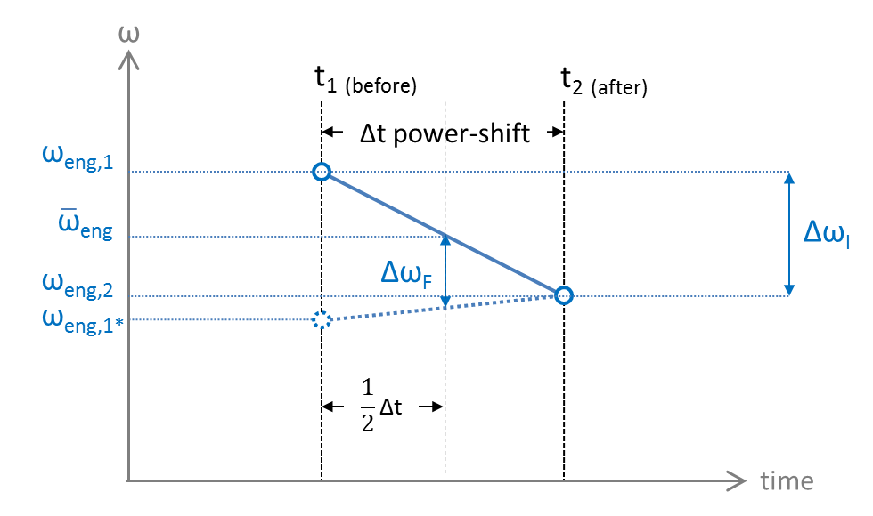

Engine speed, clutch speed during power-shift

$T_{PS,loss} = |T_{GBX,in} * \Delta\omega_F| * t_s / dt$

$\Delta\omega_I = \omega_{engine,1} - \omega_{engine,2}$

$\Delta\omega_F = (\omega_{engine,1} - \omega_{engine,1^*}) / 2$

## Gear Shift Model

This VECTO version contains a new shift strategy called EffShift.

The shift strategy is on a first level based on gearshift lines for upshift and downshift (similar to the classic VECTO gearshift strategy). Additionally “Efficiency shifts” can be triggered between the shift lines, if the fuel efficiency (g/kWh cardan) in a candidate gear is better than in the current gear. In order to cover a large range of the engine map with the “Efficiency shifts”, the area between the downshift and upshift line has to be of sufficient size. Hence, the shift lines are defined as shown in the figure below, with the downshift line (green) to the left and the up-shift line (red) to the right. Due to the superposition of the gear-shift lines with the EffShift algorithm as described below the upshift line is not relevant for upshifts in most cases.

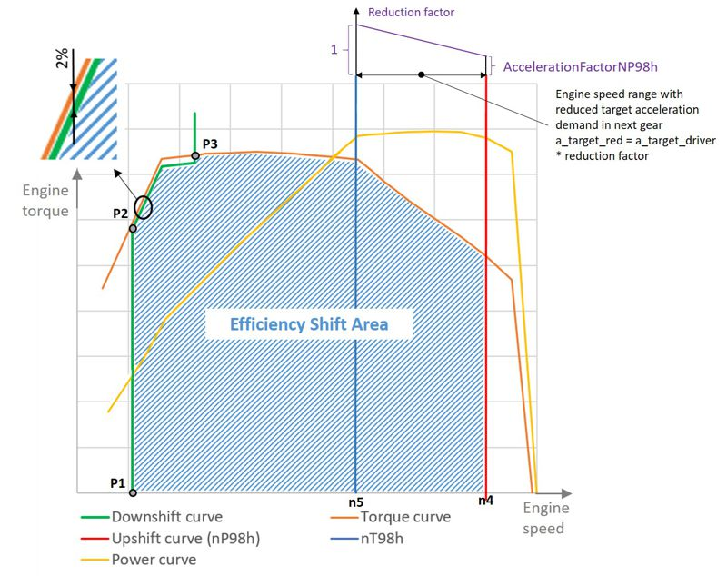

The definition of the upshift line depends on the transmission type: for AMT, the pre-shift engine speed is considered for the upshift line and for AT the post-shift engine speed is used. Additionally, the demanded acceleration to be available after a gearshift is reduced compared to the current acceleration: This is done for engine speeds between $n_{T98h}$ and $n_{P98h}$. This shall reduce reving up the engine during full-load accelerations. The demanded acceleration is calculated as follows:

$a_{demand} = a_{act} * a_{red}$ for $(n_{act} > n_{T98h})$

$a_{red} = 1+ (\textrm{AccelerationFactorNP98h} - 1) / (n_{P98h} - n_{T98h}) * (n - n_{T98h})$ for $(n_{act} > n_{T98h})$

## PEV Gear Shift Model

The gear shift lines for pure electric vehicles is different than for conventional vehicles and HEV as the shape of maximum torque curve is typically very different.

The figure below depicts a typical maximum torque curve (orange) and maximum power curve (blue) for an electric motor. The downshift and upshift lines are plotted with a dot-dashed green line.

**Basics:**

- Downshift for operation point left of green dot-dashed downshift lines
- Upshift for operation point right of green dot-dashed upshift line
- EffShift method applied for operation point between downshift and upshift lines (refer to user manual)

**Driving:**

- Maximum downshift speed always located at n_P80low (where 80% of max power is available)
- For EM in de-rating n_P80low is calculated from the de-rated power curve

**Braking:**

- EffShift is suppressed for operation point within red shaded area (2% below max recuperation power)
- New gear after downshift is selected so that operation point is closest to and above n_brake_target_norm (or only closest to n_brake_target_norm in case no operation point with higher speed exists)

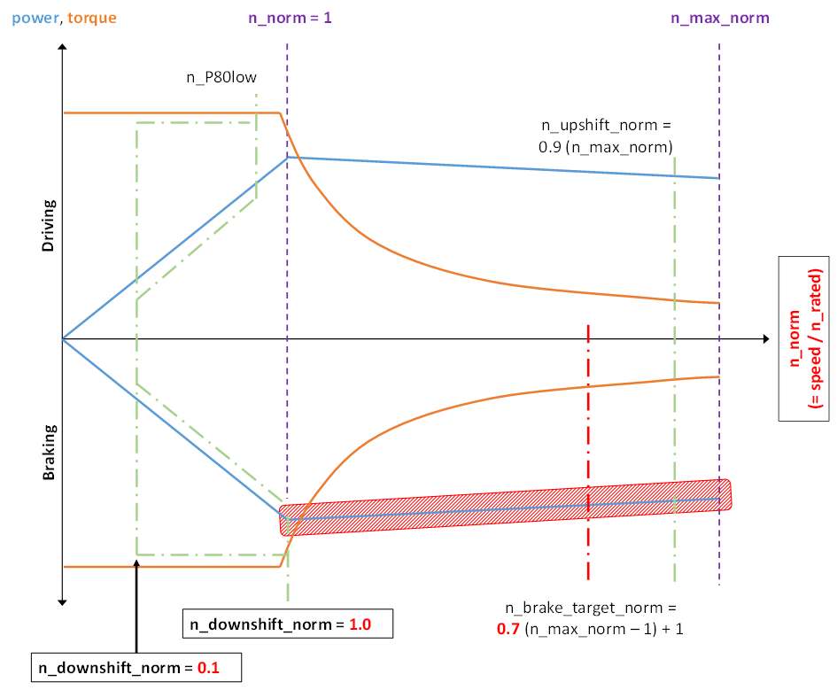

## Shift Strategy: AMT Gearshift Rules

This section describes the gearshift rules for automatic manual transmission models. When a gearshift is triggered, gears may be skipped.

The Effshift control algorithm differentiates between the shift rules:

- emergency shifts,
- polygon shifts, and
- efficiency gear shifts.

For the EffShift model general shift conditions apply regardless of the shift rule, with exception of emergency shifts, these have always priority.

The general gearshift conditions for downshifting are:

- $t_{lastshift} + t_{between shifts} < t_{act}$
- $t_{lastUpshift} + Downshift delay < t_{act}$

The general gearshift conditions for upshifting are:

- Driver behavior is accelerating or driving
- $t_{lastshift} + t_{between shifts} < t_{act}$
- $t_{lastDownshift} + Upshift delay < t_{act}$

The general shift conditions are checked first in the shift algorithm. The following table lists the generic values for the parameters used in the declaration mode settings of current version of the AMT Effshift model.

| **Parameter** | **Value** |
| --- | --- |
| $t_{between shifts}$ | 2 [s] |
| Downshift delay | 6 [s] |
| Upshift delay | 6 [s] |
| Allowed gear range | 2 |
| RatioEarlyDownshift, RatioEarlyUpshift | 24 |
| Rating current gear | 0.97 |
| $T_{reserve}$ | 0 |

### Emergency shifts

Emergency shifts depend on the current gear and the engine speed. The shifting rules for emergency shifts have been adopted from the “Classic” gearshift strategy in VECTO. In case of application of emergency rule no skipping of gears is applied.

Shift to neutral, if:

- Current gear = 1 and
- $n_{eng} < n_{idle}$

Downshift conditions:

- Current gear > 1 and
- $n_{eng} < n_{idle}$

### Polygon shifts

The second level of the gearshift algorithm is the polygon shift rule. If the current operating point is outside of the shift polygons, the polygon shift rule applies:

Downshift behavior:

- If the operating point (Teng, neng) is left the downshift line, shift to the next lower gear

Upshift behavior:

- If the operating point (Teng, neng) is right to the upshift line, shift to the highest gear which is right to the downshift line and below the full load torque considering similar engine power output.

It should be noted, that there is no skip gears at downshifting in the polygon shift mode.

### Efficiency shifts

The efficiency shift rule is added on top of the polygon shift rule. The EffShift strategy allows gear shifts if the current engine operating point is inbetween the gearshift lines and a certain threshold above the engine’s drag curve and the combined fuel efficiency considering engine and gearbox characteristics in the candidate gear is better than in the current gear. Therefore the fuel consumption of the current gear and the gears within an allowed gear shift range (parameter allowed +/- gears) is calculated. For AMT transmissions, the current operating point is used for this efficiency evaluation. Since, the velocity drop due to traction interruption is not relevant for this evaluation as this operating point only occurs for a short period of time. Efficiency shifts are only allowed below a certain gear ratio (gearbox + axle) to prevent frequent gear changes in the very lowest gears.

$FC_{gear}=min(FC_{gear + i}) \forall i \in \textrm{Allowed gear range}$

Additionally the following boundary conditions must be fulfilled for an efficiency upshift to happen:

- $i_{gear + axle} \leq \textrm{RatioEarlyUpshift}$
- Not left to downshift line
- $1-P_{eng}(candidate gear) / P_{eng,max}(candidate gear) > T_\textrm{reserve}$ ($T_\textrm{reserve}$ is set to 0 for efficiency shifts)
- $P_{eng,act } \leq P_{eng,post_shift}$ This condition is based on the assumption that sufficient power for the current acceleration is available in the next gear. The check for sufficient power in a candidate gear considers the velocity drop during traction interruption.
- $FC_{gear} < FC_{current gear} * \textrm{RatingFactor}$

For an efficiency downshift following conditions are met:

- $i_{gear + axle} \leq \textrm{RatioEarlyDownshift}$
- Not right upshift line
- $1-P_{eng}(next gear) / P_{eng,max} > T_{reserve}$ ($T_{reserve}$ is set to 0 for efficiency shifts)
- $FC_{gear} < FC_{current gear} * \textrm{RatingFactor}$

## Shift Strategy: APT Gearshift Rules

For APT gearboxes gear skipping is only allowed for transmissions with more than 6 gears. Otherwise, the gears are shifted strictly sequentially:

- 1C -> 1L -> 2L -> … (torque converter only in 1st gear)
- 1C -> 2C -> 2L -> … (torque converter in 1st and 2nd gear)

The model structure for shifting between “locked” gears for APT does not differ from the AMT algorithm. That means that the shift logic also differentiates between emergency shifts, polygon gearshifts and efficiency shifts which are processed in the same sequence.

In addition rules for shifting from torque converter (TC) to locked gears apply. These rules are described below. First step in the algorithm is the check of general conditions.

General gearshift conditions for downshifting:

- $t_{lastshift} + t_{between shifts} < t_{act}$

General gearshift conditions for the upshift in a locked gear (1C -> 1L, 2C ->2L, L ->L):

- $t_{lastshift} + t_{between shifts} < t_{act}$

Parameters used in the APT Effshift model:

| **Parameter** | **Value** |
| --- | --- |
| t_(between shifts) | 1.8 [s] |
| Downshift delay | 6 [s] |
| Upshift delay | 6 [s] |
| Allowed gear range (skip of gears) | Total number of mechanical gears ≤ 6: 1, else 2 |
| CCMinAcceleration | 0.1 [m/s²] |
| CLMinAcceleration | 0.1 [m/s²] |
| UpshiftMinAcceleration | 0.1 [m/s²] |
| RatioEarlyDownshift | 24 |
| RatioEarlyUpshift | 24 |
| Rating current gear | 0.97 |
| T_reserve | 0 |

For triggering gear shifts between gears “1C” and “2C” (if applicable for a certain transmission) the same function as in the VECTO Classic model is applied.

Upshift between TC gears (1C -> 2C):

- $n_{eng} > min(700, (n_{80h} - 150) * i_{nextGear} / i_{currentGear}$
- $T_{eng} < T_{max,stat} - T_{eng,inertia}
- $a_{estimated} > min(\textrm{CCMinAcceleration},\textrm{DriverAcceleration})$

With:

- $a_{estimated} = P_{acc} / (v_{act} * (m_{veh} + m_{red.wheels}))$

and

- $P_{acc} = P_{eng,max} - P_{Gb_loss} - P_{Axle_loss} - P_{Air drag_loss} - P_{RR} - P_{slope}$

### Emergency shifts

The Emergency shift strategy for APT transmission looks as follows.

Downshift:

- $n_{eng} < n_{idle}$

Upshift (all conditions are met):

- $n_{eng} > min(n_{max,gear}, n_{95h})$
- gear < maxGear
- $a_{estimated} > 0$
- TC = locked
- Gear + 1 is above downshift line

### Polygon shifts

The Polygon shift rule for APT works on the same principle as for AMT. But, as already mentioned above the calculation of the upshift line is based on the post-shift engine speed. If the general requirements are fulfilled and it is not an emergency shift, the algorithm of the EffShift model uses the polygon shift rule. In this regard, two different cases related to a downshift are distinguished.

Conditions for downshift case 1:

- Operation point (Teng, neng) before downshift is left to downshift line.

Conditions for downshift case 2 (all conditions have to be met):

- DriverAction = Accelerating
- $a_{act} < 0$
- $v_{veh} < v_{target} - 10km/h$
- Locked gear
- DeltaFullLoad(gear – 1) < DeltaFullLoad(gear)

Conditions for an upshift:

- Operation point (Teng, neng) before upshift is right to upshift line.
- $a_{estimated} > min(\textrm{UpshiftMinAcceleration}, \textrm{DriverAcceleration})$ (if TC is locked)

  Or $a_{estimated} > min(\textrm{CLUpshiftMinAcceleration}, \textrm{DriverAcceleration})$ (if TC is unlocked)

### Efficiency shifts

The efficiency shift algorithm for APT works similar to the AMT algorithm in case of locked gears. In order to depict differences in gear selection which result from the different shifting sequences (APT: powershift, AMT: traction interruption) the operation points used for rating of fuel efficiency and for checking the power requirements in a candidate gear are calculated differently. More specifically, this assessment looks 0.8 seconds into the future, so that a relevant operating point after the shift is considered.

For up-shifts from a torque converter gear (“C”) to a locked gear (“L”) the estimated engine speed in the locked gear has to be above a certain threshold. This threshold depends on the engine’s load stage and the road gradient.

**Shift rules for L -> L shifts (Efficiency shifts):**

The search algorithm for the next gear is as follows:

$FC_{gear} = min(FC_{gear + i}) \forall i \in \textrm{Allowed gear range}$

Additionally the candidate gear has to fulfill the boundary conditions below for an efficiency upshift.

- $i_{gear + axle} \leq \textrm{RatioEarlyDownshift}$
- Not left to downshift line
- $1 - (P_{eng} / P_{eng,max}) > T_{reserve} ($T_{reserve}$ is set to 0)
- $FC_{gear} < FC_{current gear} * \textrm{Rating current gear}$

For an efficiency downshift following conditions are met for the potential gear:

- $i_{gear + axle} \leq \textrm{RatioEarlyDownshift}$
- Not right upshift line
- $1 - (P_{eng} / P_{eng,max}) > T_{reserve}$ ($T_{reserve}$ is set to 0)
- $FC_{gear} < FC_{current gear} * \textrm{Rating current gear}$

**Shift rules for C -> L shifts (Efficiency shifts):**

The used algorithm can be summarized as follows:

Definitions:

| **Parameter** | **Unit** | **Description** |
| --- | --- | --- |
| torque ratio | [%] | current engine torque / maximum engine torque at actual engine speed |
| a_min | [ m/s²] | available acceleration at actual engine torque for maximum loaded vehicle |
| a_max | [m/s²] | available acceleration at actual engine torque for empty vehicle |
| a_curr | [m/s²] | available acceleration at actual engine torque for current vehicle mass |

In each time-step a target post-shift engine speed from the shift strategy is calculated in a three step approach: * The current engine load stage is determined based on current torque ratio and a set of hysteresis thresholds * For the current engine load stage and the current slope each a rpm value is interpolated from a parameter table * The final value for target post-shift engine speed is interpolated for the current value of a_curr from the results of the previous step

If the estimated engine speed after a C -> L shift is calculated to be equal or higher than the target engine speed as calculated above, the gear shift is initiated. This approach in combination with the proposed parameters as shown below reflects the strategy that shifts from C -> L are performed with absolute priority in order to minimize driveline losses from torque converter operation.

Boundary values between engine load stages (values for torque ratio in [%]) (relevant for C -> L shifts)

| Load stage | 1<->2 | 2<->3 | 3<->4 | 4<->5 | 5<->6 |
| --- | --- | --- | --- | --- | --- |
| Hysteresis upper | 19.70 | 36.34 | 53.01 | 69.68 | 86.35 |
| Hysteresis lower | 13.70 | 30.34 | 47.01 | 63.68 | 80.35 |

Matrix with target post-shift engine speed offset above idling speed (values in rpm, relevant for C -> L shifts)

| engine load stage | a_max, slope +5% | a_max, slope 0% | a_max, slope -5% | a_min, slope +5% | a_min, slope 0% | a_min, slope -5% |
| --- | --- | --- | --- | --- | --- | --- |
| 1 | 90 | 120 | 165 | 90 | 120 | 165 |
| 2 | 90 | 120 | 165 | 90 | 120 | 165 |
| 3 | 90 | 120 | 165 | 90 | 120 | 165 |
| 4 | 90 | 120 | 165 | 110 | 140 | 185 |
| 5 | 100 | 130 | 175 | 120 | 150 | 195 |
| 6 | 110 | 140 | 185 | 130 | 160 | 205 |

## Shift Strategy: MT Gearshift Rules

This section describes the gearshift rules for manual transmission models. When a gearshift is triggered, gears may be skipped for (see Gearbox: Gear Shift Model).

### Shift Polygons in Declaration Mode (According to ACEA Whitebook 2016)

#### 1. Computation of Characteristic Points

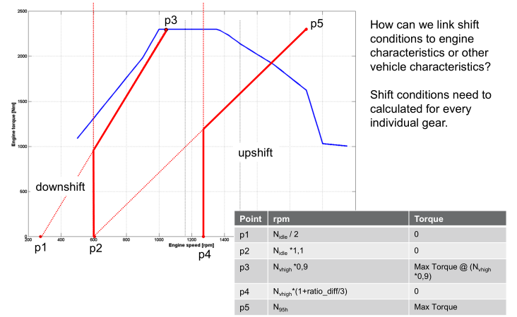

#### 2. Definition of Shift Lines

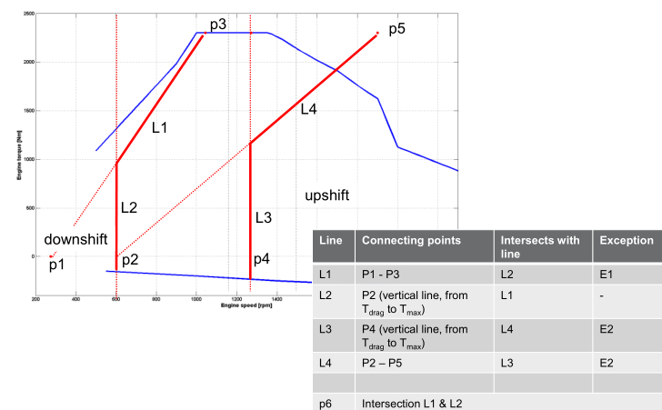

#### 3. Exception 1: Margin to Max-Torque line (Downshift)

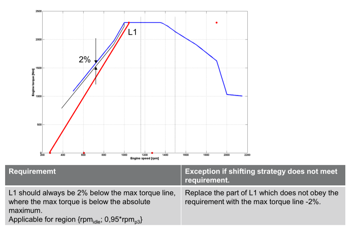

#### 4. Exception 2: Minimal Distance between Downshift and Upshift Lines

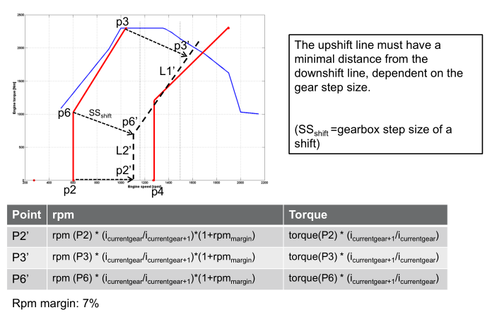

#### 5. Final Gearshift Lines (Example)

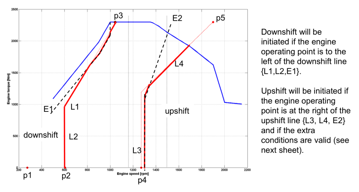

If the gearbox defines a maximum input speed for certain gears the upshift line may further be intersected and limited to the gear’s maximum input speed.

### Upshift rules

- If the engine speed is higher than the gearbox maximum input speed or engine n_{95h} speed (whichever is lower)
- If all of the following conditions are met:
  - The vehicle is not decelerating AND
  - Engine operation point (speed and torque) is above (right of) the upshift line AND
  - The acceleration in the next gear is above a certain threshold if the driver is accelerating, i.e., acceleration_nextGear > min(Min. acceleration threshold, Driver acceleration) AND
  - The last gearshift was longer than a certain threshold (Declaration Mode: 2s) ago AND
  - The last downshift was longer than a certain threshold (Declaration Mode: 10s) ago

### Downshift

- If the engine speed is lower than the engine’s idle speed
- If all of the following conditions are met:
  - Engine operation point (speed and torque) is below (left of) the downshift line AND
  - The last gearshift was longer than a certain threshold (Declaration Mode: 2s) ago AND
  - The last upshift was longer than a certain threshold (Declaration Mode: 10s) ago

### Shift parameters

- Gearshift lines
- Engine idle speed
- Gearbox max. input speed
- Engine n_{95h} speed
- Min. time between two consecutive gearshifts.
- Min. time for upshift after a downshift
- Min. time for downshift after an upshift
- Min. acceleration in next gear

## Torque Converter Model

The torque converter is defined as (virtual) separate gear. Independent of the chosen AT gearbox type (serial or power split), VECTO uses a powertrain architecture with a serial torque converter. The mechanical gear ratios and gears with torque converter are created by VECTO depending on the gearbox type and gear configuration.

While the torque converter is active engine torque and speed are computed based on TC characteristic.

[figure not shown]

### Torque converter characteristics file (.vtcc)

The file is described here.

This file defines the torque converter characteristics as described in VDI 2153:

- **Speed Ratio** ($\nu$) = Output Speed / Input Speed
- **Torque Ratio** ($\mu$) = Output Torque / Input Torque
- **Input Torque** ($T_{ref}(\nu)$) is the input torque (over ν) for a specific reference engine speed (see below).

The Input Torque at reference engine speed is needed to calculate the actual engine torque using this formula:

$T_{in} = T_{ref}(\nu) \cdot ( \frac{n_{in}}{n_{ref}} )^{2}$

$\mu(\nu) = \frac{T_{out}}{T_{in}}$

with:

- T<sub>in</sub> = engine torque [Nm]
- T<sub>ref(ν)</sub> = reference torque at reference rpm (from .vtcc file) [Nm]
- n<sub>in</sub> = engine speed [1/min]
- n<sub>ref</sub> = reference rpm [1/min] (see below)

The torque converter characteristics must also be defined for speed ratios greater than one (ν>1) in order to calculate overrun conditions or engine drag (torque<0).

**Note:** The torque converter characteristics must not contain parts where either the torque ratio or the input torque are constant!

In declaration mode, the torque converter for drag points is automatically appended by VECTO. Input data with a speed ratio ≥ 1 are skipped.

For Power Split transmissions, where the torque converter characteristics already includes the gearbox losses and transmission ratio, the generic drag points are adapted according to the following equations:

$\nu_{PS} = \nu / ratio_i$

$\mu_{PS} = \mu \cdot ratio_i$

In engineering mode the drag points for the torque converter can be specified. If so, the input data has to cover at least the speed ratio up to 2.2.

If the torque converter characteristics for drag are not specified, the generic points are appended as described above for declaration mode.

The torque converter has a separate Shift Polygon which defines the conditions for switching from torque converter gear to locked gear.

## Auxiliaries

In Declaration mode the auxiliaries are predefined and the power demand is defined based on the vehicle category and mission. For every type of auxiliary (fan, steering pump, HVAC, electric system, pneumatic system) the user can select a technology from a given list.

In Engineering mode the auxiliary power demand for the following states of the vehicle can be defined:

- ICE On
- Vehicle driving, ICE off
- Vehicle standstill, ICE off

If the ICE is on, the auxiliary power demand is directly applied to the combustion engine. In case the ICE is off, the according power demand is balanced in the modal data and the fuel consumption is corrected in post processing.

## Bus Auxiliaries

*Note:* Bus auxiliaries in declaration mode are only available via XML input files.

The general approach for bus auxiliaries is that depending on the simulated driving cycle, number of passengers and selected auxiliary technologies the average power demand is calculated and applied during simulation. In case of smart auxiliaries (smart air compressor or smart alternator) the smart systems are only active during braking events if there is enough excessive power to provide the increased power demand for the smart systems. This reduces the amount of mechanical braking power required. Thus, during braking events the smart air compressor may produce more compressed air than required on average and the smart alternator may generate more electric power than required on average. The final fuel consumption is corrected for the excessive compressed air volume and electric energy in a post processing step.

### Engine Cooling Fan

The power demand for the engine cooling fan depends on the selected technology of the cooling fan.

### Steering Pump

The power demand of the steering pump can either be electrical or mechanical. The actual demand depends on the selected technology, vehicle dimensions and number of steered axles.

### Pneumatic System

The air demand depends on the one hand on the cycle (number of braking events, number of stops, number of kneeling events, etc) and the vehicle configuration. Depending on the compressor technology a generic compressor map is used to calculate the power demand for a certain air demand.

### Electric System

Depending on the vehicle group and mission profile a generic electric load is applied. Certain technologies can be selected in the input (LED lamps).

### HVAC

#### Model Parameters:

- Bus body
  - Length $l_\textrm{Bus}$
  - Width $b_\textrm{Bus}$
  - Height $h_\textrm{Bus}$
  - Double decker
  - Floor type (low floor, raised floor)
- Auxiliary heater power
- HVAC system configuration
- Number of passengers
- Fuel saving technologies
- Environmental conditions map

The environmental conditions map contains a list of environmental conditions (environmental temperature, solar factor) and a weighting factor. The power demand for the HVAC system (separated into mechanical and electrical power demand) is calculated for every environmental condition in the map and summed up with the according weighting factor.

#### Calculation of HVAC Power Demand

$P_\textrm{HVAC,mech,sum} = \sum_\textrm{env} w_\textrm{env} * min(P_\textrm{HVAC,mech}(T_\textrm{env}, S_\textrm{env}) * (1 - \textrm{TechBenefitsMech}), P_\textrm{HVAC,max}) / \textrm{COP}$

$P_\textrm{HVAC,el,sum} = \sum_\textrm{env} w_\textrm{env} * min(P_\textrm{HVAC,el}(T_\textrm{env}, S_\textrm{env}) * (1 - \textrm{TechBenefitsEl}), P_\textrm{HVAC,max}) / \textrm{COP} + P_\textrm{ventilation,heating}(T_\textrm{env}, S_\textrm{env}) * (1 - \textrm{TechBenefitsElHeatingVent}) + P_\textrm{ventilation,cooling}(T_\textrm{env}, S_\textrm{env}) * (1 - \textrm{TechBenefitsElCoolingVent})$

$P_\textrm{HVAC,mech}(T, S) = \left\{ \begin{array}{ll} 0 & : T < 17^{\circ}C\\ 0 & : \textrm{electric compressor}\\ min( P_\textrm{HVAC}(T, S, T_\textrm{low}) , P_\textrm{HVAC}(T, S, T_\textrm{high}(T))) & : P_\textrm{HVAC}(T, S, T_\textrm{low}) > 0 \;\textrm{and}\; P_\textrm{HVAC}(T, S, T_\textrm{high}(T)) > 0 \\ 0 & : \textrm{otherwise} \end{array} \right.$

$P_\textrm{HVAC,el}(T, S) = \left\{ \begin{array}{ll} 0 & : T < 17^{\circ}C\\ 0 & : \textrm{mechanical compressor}\\ min( P_\textrm{HVAC}(T, S, T_\textrm{low}) , P_\textrm{HVAC}(T, S, T_\textrm{high}(T))) & : P_\textrm{HVAC}(T, S, T_\textrm{low}) > 0 \;\textrm{and}\; P_\textrm{HVAC}(T, S, T_\textrm{high}(T)) > 0 \\ 0 & : \textrm{otherwise} \end{array} \right.$

$P_\textrm{ventilation,heating}(T_\textrm{env}, S_\textrm{env}) = \left\{ \begin{array}{ll} V_\textrm{Bus} * r(\textrm{true}) * 0.56 Wh/m^3 & : P_\textrm{HVAC}(T, S, T_\textrm{low}) < 0 \;\textrm{and}\; P_\textrm{HVAC}(T, S, T_\textrm{high}(T)) < 0 \\ 0 & : \textrm{otherwise} \end{array} \right.$

$P_\textrm{ventilation,cooling}(T_\textrm{env}, S_\textrm{env}) = \left\{ \begin{array}{ll} V_\textrm{Bus} * r(\textrm{false}) * 0.56 Wh/m^3 & : T_\textrm{env} \geq 17^{\circ}C \;\textrm{and}\; P_\textrm{HVAC}(T, S, T_\textrm{low}) > 0 \;\textrm{and}\; P_\textrm{HVAC}(T, S, T_\textrm{high}(T)) > 0 \\ 0 & : \textrm{otherwise} \end{array} \right.$

$r(\textrm{heating}) = \left\{\begin{array}{ll} 7 \;1/h & : \textrm{HVAC Configuration 1 \& 2}\\ 10 \;1/h & : \textrm{heating} \;\textrm{and}\; \textrm{HVAC Configuration 3 -- 9} \\ 20 \;1/h & : \textrm{HVAC Configuration 3 -- 9} \\ \end{array} \right.$

$T_\textrm{low} = 18^{\circ}C$

$T_\textrm{high}(T_\textrm{env}) = \left\{\begin{array}{ll} max(23^{\circ}C, T_\textrm{env} - 3^{\circ}C) & : \textrm{Low floor bus}\\ 23^{\circ}C & : \textrm{otherwise} \end{array} \right.$

$P_\textrm{HVAC}(T_\textrm{env}, S, T_\textrm{calc}) = Q_\textrm{Wall}(T_\textrm{env}, T_\textrm{calc}) + P_\textrm{Passenger}(T_\textrm{env}) + P_\textrm{Solar}(T_\textrm{env}, S)$

$Q_\textrm{Wall}(T_\textrm{env}, T_\textrm{calc}) = (T_\textrm{env} - T_\textrm{calc}) * A_\textrm{BusSurface} * U$

$P_\textrm{Passenger}(T_\textrm{env}) = \#_\textrm{Passenger} * \left\{\begin{array}{ll} 50\; W & : T_\textrm{env} < 17^{\circ}C\\ 80\; W & : \textrm{otherwise} \end{array} \right.$

$P_\textrm{Solar}(T_\textrm{env}, S) = S * A_\textrm{Windows} * G * S_\textrm{clouding}(T_\textrm{env}) * 0.25$

$S_\textrm{clouding}(T_\textrm{env}) = \left\{\begin{array}{ll} 0.65 & : T_\textrm{env} < 17^{\circ}C\\ 0.8 & : \textrm{otherwise} \end{array} \right.$

$U = \left\{\begin{array}{ll} 4\; W/Km^2 & : \textrm{Low floor bus}\\ 3\; W/Km^2 & : \textrm{Raised floor bus} \end{array} \right.$

$G = 0.95$

$V_\textrm{Bus} = l_\textrm{HVAC} * b_\textrm{Bus} * h_\textrm{Bus}$

$A_\textrm{BusSurface} = 2 * (l_\textrm{HVAC} * b_\textrm{Bus} + l_\textrm{HVAC} * h_\textrm{Bus} + b_\textrm{Bus} * h_\textrm{Bus})$

$A_\textrm{Window} = l_\textrm{HVAC} * h_\textrm{Windows} + A_\textrm{Front\&Rear}$

$l_\textrm{HVAC} = \left\{\begin{array}{ll} 2 * 1.2 \;m & : \textrm{HVAC Configuration 2}\\ l_\textrm{Bus} & : \textrm{otherwise} \\ \end{array} \right.$

$h_\textrm{Windows} = \left\{\begin{array}{ll} 2.5 \;m & : \textrm{Double Decker}\\ 1.5 \;m & : \textrm{Single Decker} \end{array} \right.$

$A_\textrm{Front\&Rear} = \left\{\begin{array}{ll} 8 \;m^2 & : \textrm{Double Decker}\\ 5 \;m^2 & : \textrm{Single Decker} \end{array} \right.$

$P_\textrm{HVAC,max} = P_\textrm{HVAC,max,passenger} + P_\textrm{HVAC,max,driver}$

$P_\textrm{HVAC,max,passenger} = \textrm{Lookup}_\textrm{passenger}(\textrm{HVAC Configuration}, \textrm{driving cycle}) * V_\textrm{passenger}$

$V_\textrm{passenger} = l_\textrm{internal} * h_\textrm{internal} * b_\textrm{Bus}$

$l_\textrm{internal} = \left\{\begin{array}{ll} 2 * l_\textrm{Bus} & : \textrm{low floor} \;\textrm{and}\; \textrm{double decker}\\ l_\textrm{Bus} & : \textrm{low floor} \;\textrm{and}\; \textrm{single decker}\\ 1.5 * l_\textrm{Bus} & : \textrm{raised floor} \;\textrm{and}\; \textrm{double decker} \;\textrm{and}\; \#_\textrm{passengers lower deck} > 6\\ l_\textrm{Bus} + 2.4 \;m & : \textrm{raised floor} \;\textrm{and}\; \textrm{double decker} \;\textrm{and}\; \#_\textrm{passengers lower deck} \leq 6\\ l_\textrm{Bus} & : \textrm{raised floor} \;\textrm{and}\; \textrm{single decker}\\ \end{array} \right.$

$h_\textrm{internal} = \left\{\begin{array}{ll} 1.8 \;m & : \textrm{double decker} \\ h_\textrm{Bus} - 0.5 \;m & : \textrm{single decker} \;\textrm{and}\; \textrm{raised floor} \\ h_\textrm{Bus} & : \textrm{single decker} \;\textrm{and}\;\textrm{low floor} \end{array} \right.$

$P_\textrm{HVAC,max,driver} = \textrm{Lookup}_\textrm{driver}(\textrm{HVAC Configuration}, \textrm{driving cycle})$

**Aux Heater Power**

$P_\textrm{HVACSSM,auxHtr}(\overline{P}_\textrm{ice,waste heat}) = \sum_\textrm{env} w_\textrm{env} * P_\textrm{auxHtr}(T_\textrm{env}, S_\textrm{env}, \overline{P}_\textrm{ice,waste heat}) * 0.2 * 0.75)$

$P_\textrm{auxHtr}(T, S, P_\textrm{wasteHeat}) = \left\{ \begin{array}{ll} |max( P_\textrm{additionalHeating}(T, S, T_\textrm{low}, P_\textrm{wasteHeat}) , P_\textrm{additionalHeating}(T, S, T_\textrm{high}(T), P_\textrm{wasteHeat}))| & : P_\textrm{HVAC}(T, S, T_\textrm{low}) < 0 \;\textrm{and}\; P_\textrm{HVAC}(T, S, T_\textrm{high}(T)) < 0 \\ 0 & : \textrm{otherwise} \end{array} \right.$

$P_\textrm{additionalHeating}(T, S, T_\textrm{calc}, P_\textrm{wasteHeat}) = \left\{ \begin{array}{ll} P_\textrm{HVAC}(T, S, T_\textrm{calc}) * (1 - \textrm{TechBenefitsFuelHeater})) + P_\textrm{wasteHeat} & : P_\textrm{HVAC}(T, S, T_\textrm{calc}) * (1 - \textrm{TechBenefitsFuelHeater})) < 0 \;\textrm{and}\; P_\textrm{HVAC}(T, S, T_\textrm{calc}) * (1 - \textrm{TechBenefitsFuelHeater})) < -P_\textrm{wasteHeat} \\ 0 & : \textrm{otherwise} \end{array} \right.$

[figure not shown]

In Engineering Mode the electrical and mechanical power demand for the electric system, the pneumatic system and the HVAC can be provided.

#### Electric System

**Current Demand Engine On [A]**

Demand of the electric system when the ICE is on. The current is multiplied with the nominal voltage of 28.3V.

**Current Demand Engine Off Driving [A]**

Demand of the electric system when the ICE is off and the vehicle is driving. The current is multiplied with the nominal voltage of 28.3V.

**Current Demand Engine Off Standstill [A]**

Demand of the electric system when the ICE is off and the vehicle is at standstill. The current is multiplied with the nominal voltage of 28.3V.

**Alternator Efficiency [-]**

The electric power demand is divided by the alternator efficiency to get the mechanical power demand at the crank shaft

**Alternator Technology**

The “conventional alternator” generated exactly the electric power as demanded by the auxiliaries. The “smart alternator” may generate more electric power than needed during braking phases. The excessive electric power is stored in a battery. In case “no alternator” is selected (only available for xEV vehicles) the electric system is supplied from the high voltage REESS via a DC/DC converter.

**Max Recuperation Power [W]**

In case of a smart alternator, defines the maximum electric power the alternator can generate during braking phases.

**Useable Electric Storage Capacity [Wh]**

In case of a smart alternator, defines the storage capacity of the battery. In case the battery is not empty, the electric auxiliaries are supplied from the battery. Excessive electric energy from the smart alternator during braking phases is stored in the battery.

**Electric Storage Efficiency [-]**

This efficiency is applied when storing electric energy from the alternator in the battery.

**ES supply from HEV REESS**

If selected, the low-voltage electric auxiliaries can be supplied from the high voltage REESS via the DC/DC converter. Needs to be selected in case “no alternator” is chosen as alternator technology. In case of a smart alternator, the low-voltage battery is used first and if empty the energy is drawn from the high voltage system.

**DC/DC Converter Efficiency [-]**

In case the electric system is supplied by the high voltage REESS, the efficiency of the DC/DC converter can be defined via a constant efficiency value

#### Pneumatic System

**Compressor Map**

Compressor map file defining the mechanical power demand and the air flow depending on the compressor speed.

**Average Air Demand [NI/s]**

Defines the average demand of compressed air throughout the cycle.

**Compressor Ratio [-]**

Defines the ratio between the air compressor and combustion engine

**Smart Air Compressor**

If enabled, the air compressor may generate excessive air during braking events. The air consumed and generated are corrected in post processing.

#### HVAC System

**Mechanical Power Demand [W]**

Power demand of the HVAC system directly applied at the crank shaft

**Electric Power Demand [W]**

Electric power demand of the HVAC system. This is added to the current demand of the electric system

**Aux Heater Power [W]**

Maximum power of the auxiliary heater

**Average Heating Demand [MJ]**

Heating demand for the passenger compartment. This demand is primary satisfied from the combustion engines waste heat. In case the heating demand is higher, the auxiliary heater may provide additional heating power. The fuel consumption of the aux heater is corrected in post processing.

## P<sub>wheel</sub>-Input (SiCo Mode)

For verification tasks it is possible to manually input the power at wheels (P<sub>wheel</sub>) which is normally calculated via longitudinal dynamics. In this case VECTO only calculates the losses between wheels and engine and adds auxiliary power demand. This mode is active as soon as P<sub>wheel</sub>, Gear and Engine Speed are defined in the driving cycle.

### Requirements

- Driving Cycle must include t, P<sub>wheel</sub> (Pwheel), Gear (Gear) and Engine Speed (n), see Driving Cycle (.vdri) format.
- The driving cycle must be time-based.

**Example driving cycle with P<sub>wheel</sub> input.**

| <t> | <Pwheel> | <gear> | <n> |
| --- | --- | --- | --- |
| 1 | 0.0 | 0 | 560.0 |
| 2 | 0.0 | 0 | 560.0 |
| 3 | 14.0 | 1 | 593.2 |
| 4 | 51.9 | 1 | 705.5 |
| … | … | … | … |

## Fuel Cell

```
flowchart TB
    subgraph Composite Fuel Cell System
        subgraph Fuel Cell System String 1
            direction LR
            FCS1.1-.-FCS1.2:::dot-.-FCS1.3:::dot
        end
        subgraph Fuel Cell System String 2
            direction LR
            FCS2.1:::dot-.-FCS2.2:::dot-.-FCS2.3:::dot
        end
    end


    classDef dot stroke-width:2px,stroke-dasharray: 5 5
```

The Composite Fuel Cell System (CFCS) can constist of up to two Fuel Cell System Strings (FCS String) with up to three Fuel Cell Systems (FCS) in each string.

### General approach

Fuel cell vehicles are simulated in a two-step approach. The first step is intended to obtain the optimal fuel cell power over the cycle. This is detemined in a pre-simulation run with extensive post-processing of these results. The second step is the simulation of the actual fuel cell vehicle with the fuel cell power trace obtained from the first simulation step. The goal is to operate the CFCS as stationary as possible (i.e., avoid dynamic changes in the requested power) and to operate the individual FCS as close to their optimal operating point as possible.

#### Pre-simulation run

In the pre-simulation run the fuel cell vehicle is modeled and simulated as a PEV vehicle in charge depleting mode wit ha modified battery system (See pre run battery). The power demand of the propulsion system is used to determine the fuel cell power demand over the distance in the driving cycle.

#### Determining the power of the fuel cell system

The fuel cell power at a given distance equals the average electric power demand over a certain distance window. The window size is mainly influenced by the battery size. VECTO aims to use the largest possible window size without violating the SoC limits at any given time or distance.

The start SoC is also adapted to the specific mission in order to maximize the usage of the battery as a buffer. For further details see window algorithm

#### Actual Simulation

During the actual simulation the power that is provided by the fuel cell system is already known. Deviations from the electric power demand are covered by the battery.

If the power demain for propulsion is higher than the power provided by the fuel cell, the battery is discharged, while if the fuel cell provides more power than the powertrail requires the battery is charged.

If the fuel cell system consists of more than one fuel cell the most efficient power distribution between the fuel cell strings is used (see power distribution)

#### Post Processing

In a post processing step $\Delta$ SoC is corrected to account for deviations from neutral SoC behaviour over the cycle.

##### Pre-run battery

The prerun battery constists of the battery that is provided with the vehicle and a second battery that reflects the power of the fuel cell. The second battery has a discharging power equal to the maximum power of the fuel cell system and a charging power of 0 Watt.

To avoid violating the SoC-limits both of the batteries have infinite capacity.

##### Window algorithm

The power that should be provided by the fuel cell at a certain distance $s$ is calculated for a window size $s_w$ based on the trace of the electric power demand $P_{el}$ determined in the pre-run. The maximum window size is equal to the length of the cycle ($s_{cycle}$) At the beginning (and the end) of the cycle the window expands over the actual cycle, therefore $P_{el}$ is augmented with $P_{el}$ shifted to the left by $s_{cycle}$ (or to the right at the end of the cycle)

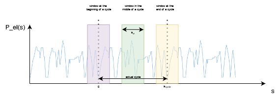

Given a window size $s_w$ and the power trace $P_{el}$. The fuel cell power at distance $s$ is the average $P_{el}$ inside the window.

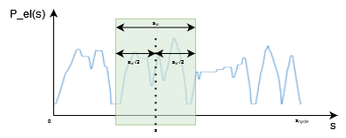

##### Window search algorithm

The window size is determined using the following algorithm, starting with the window size set to the cycle distance (which is the maximum possible window size).

```
flowchart LR
    SInit["Simulate(s_cycle, P_el)"]
    Dec["Decrease window size s_w"]
    Inc["Increase window size s_w"]
    Simulate["Simulate(s_w, P_el)"]
    AccI{"Accepted?"}
    Acc2{"Accepted?"}
    Dev{"Close enough?"}
    D["✔"]
    SInit --> AccI --"yes"-->D
    AccI --"no"--> Dec

    Dec --> Simulate

    Simulate --> Acc2
    Acc2 -- "yes" --> Dev --"yes"--> D
    Dev -- "no" --> Inc
    Acc2 -- "no" --> Dec
    Inc --> Simulate
```

**Close enough**: If the deviation of the last rejected window size and the last accepted window size is < 5% the search aborts and the largest accepted window size is used for further calculations.

**Increase/Decrease window size** The window size is increased/decreased to $s_{w} = (s_{w, last \ accepted} + s_{w, last \ rejected})/2$

**Abort criterion** If the window size gets smaller than 5 m the simulation of the FCHV is aborted.

```
flowchart TB
    subgraph "Simulate(s_w, P_el)"
    C["Calculate fuel cell power
    trace P_FC for s_w"]
    SI["Simulate with infinity battery"]
    SR["Simulate with real battery"]
    Shift["Shift initial SoC"]
    V{"SoC limits
    violated?"}
    A[Accept]
    R[Reject]

    C--->SI
    SI--->Shift
    Shift-->SR
    SR --> V
    V --"yes"--> R
    V --"no" --> A
    end
```

**Calculate fuel cell power trace $P_{FC}$ for $s_{w}$** For each distance s in the cycle, the average electric power demand (=$P_{fc,raw}$) in the window is calculated.

The difference between the actual electric power demand $P_{el}[s]$ of the vehicle and the power that should be provided by the fuel cell $P_{fc, raw}[s]$ must be compensated by the battery, which leads to losses.

The losses of the battery as well as the maximum fuel cell power are considered when the final power of the fuel cell ($P_{fc}[s]$) is determined.

**Simulate with infinity battery** Given the fuel cell power trace $P_{fc}[s]$ for each distance the remaining power is requested from the battery and VECTO keeps track of the current SoC.

Note: The SoC is always kept at CenterSoC. VECTO keeps track of a virtual SoC which is then used to calculate the new initial SoC.

**Shift initial SoC** Using the virtual SoC range VECTO tries to set the initial SoC so that the SoC limits of the battery are not violated. If this is not possible (virtual SoC range is larger than the SoC range of the real battery) the window is too large and therefore rejected.

**Simulate with real battery** Finally a request for each distance is send to the real battery starting with the updated initial SoC. If the SoC limits are violated the window size is rejected.

#### Power distribution

The trace of the fuel cell power reflects the power that has to be provided by the CFCS. If there are several FCS Strings, the power must be split between the individual FCS. Since the power of the CFCS is known before the actual simulation run for each distance in the cycle, the power distribution can also be calculated before the final simulation run.

Inside a FCS String the power is always equally distributed among the switched on fuel cell systems.

##### Power distribution among strings

For each distinct $P_{FC}$ occuring in the cycle the shares a (share of FCS String 1) and b (share of FCS String 2) are calculated.

$P_{FC} = a P_{FC} + b P_{FC} a + b = 1 $

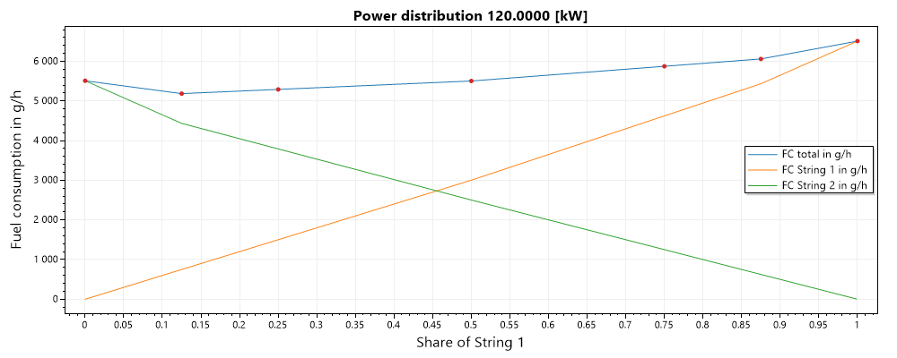

VECTO minimizes the fuel consumption $FC(P) = FC_{1}(a \cdot P) + FC_{2}(b \cdot P)$ at each operating point in the cycle.

##### Power distribution inside a string

Taking into account the power limits, VECTO calculates the number of active FCSs in an FCS string that lead to the lowest fuel consumption.

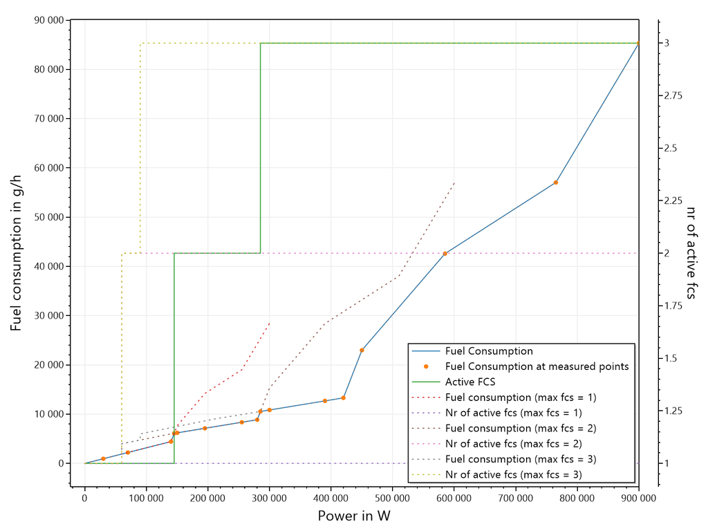

##### Time splitting

If the requested power on a string is lower than the power at the best efficiency point of a single FCS. In this case, a virtual “time splitting” is carried out, i.e. for the time step the FCS is operated at the best efficiency point for a fraction of the time corresponding to the requested power. For the rest of the time step, the FCS is considered switched off.

## PTO

VECTO supports the simulation of PTO related components and losses in the powertrain. Structurally this consists of 2 components (PTO transmission, PTO consumer) and 3 different kind of losses (transmission, idling, cycle).

### Structural Overview of PTO Components

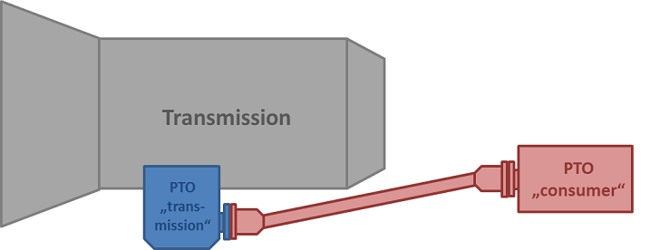

#### Losses in the PTO “Transmission” part (blue)

This is considered by constant power consumption as a function of the PTO type. The power consumption is added in all vehicle operation conditions, due to VECTO not differentiating between clutch open/closed and gear engaged/disengaged. The PTO type is configurable in the Vehicle Editor. The exact values are shown in the following table:

| Technology | Power Loss [W] |
| --- | --- |
| None | 0 |
| only the drive shaft of the PTO - shift claw, synchronizer, sliding gearwheel | 50 |
| only the drive shaft of the PTO - multi-disc clutch | 1000 |
| only the drive shaft of the PTO - multi-disc clutch, oil pump | 2000 |
| drive shaft and/or up to 2 gear wheels - shift claw, synchronizer, sliding gearwheel | 300 |
| drive shaft and/or up to 2 gear wheels - multi-disc clutch | 1500 |
| drive shaft and/or up to 2 gear wheels - multi-disc clutch, oil pump | 3000 |
| drive shaft and/or more than 2 gear wheels - shift claw, synchronizer, sliding gearwheel | 600 |
| drive shaft and/or more than 2 gear wheels - multi-disc clutch | 2000 |
| drive shaft and/or more than 2 gear wheels - multi-disc clutch, oil pump | 4000 |

#### Idling losses of the PTO “Consumer” (red)

The idling losses are a function of speed as determined by the DIN 30752-1 procedure. If the PTO transmission includes a shifting element (i.e. declutching of consumer part possible) the torque losses of the consumer in VECTO input shall be defined with zero. This is only used outside of PTO cycles, since the PTO cycles already include these losses. The idling losses are defined as a lossmap dependent on speed which is configurable in the Vehicle Editor. The file format is described in PTO Idle Consumption Map.

#### Cycle losses during the PTO cycle of the PTO “Consumer” (red)

A specific PTO cycle (time-based, engine speed and torque from PTO consumer as determined by the DIN 30752-1 procedure) is simulated during vehicle stops labeled as “with PTO activation”. The execution of the driving cycle stops during this time and the pto cycle is executed. Afterwards the normal driving cycle continues.

Power consumption in the PTO transmission part added to power demand from the PTO cycle. The cycle is configurable in the Vehicle Editor and follows the file format described in PTO-Cycle (.vptoc) in case of mechanical PTOs or PTO Cycle (.vptoel) in case of electrical PTOs. The latter can only be decalred for battery electric and serial hybrid electric vehicles. The timings in the PTO cycle get shifted to start at 0.

### Behavior During PTO Driving Cycles

A PTO cycle can only be activated during a stop phase in the driving cycle. When the PTO cycle is activated VECTO exhibits the following behavior: Half of the stop time is added before the pto cycle, and the other half is added afterwards. If the halved stop times are still longer than 3 seconds, they get divided even further to 3 intervals in order to achieve a more appealing visualization in the output (falling down, low baseline, rising again). It is recommended to have a stop time of at least 2 seconds.

The following image shows the behavior of running PTO cycles during a normal driving cycle:

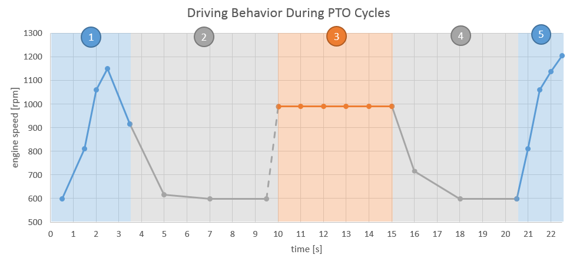

1. Normal driving behavior.
2. The first half of the stop phase begins, the vehicle stops and the engine speed goes down to idle speed (if there is enough time).
3. The PTO cycle continues from the last engine speed in stop phase and sets it to the engine speed of the first entry in the PTO cycle.
4. After the PTO cycle ends, the second half of the stop phase begins and the engine speed again goes to idle speed (if enough time passes).
5. After the stop phase the normal driving behavior starts again - the vehicle drives off.

### Additional PTO activations in Engineering mode

In engineering mode additional PTO activations are available to simulate different types of municipal vehicles. It is possible to add a certain PTO load during driving while the engine speed and gear is fixed (to simulate for example roadsweepers), or to add PTO activation while driving (to simulate side loader refuse trucks for example). In both cases the PTO activation is indicated in the driving cycle.

The .vmod file file contains additional columns with the PTO power applied during driving (P_PTO_RoadSweeping, P_PTO_DuringDrive) and is also included in P_PTO_CONSUM. In the .vsum file the energy demand for both PTO modes is provided in the columns E_aux_PTO_RoadSweeping and E_aux_PTO_DuringDrive.

#### Roadsweeper

PTO activation mode 2 simulates PTO activation while driving at a fixed engine speed and gear. The minimum engine speed and working gear is entered in the PTO tab of the Vehicle editor.

[figure not shown]

PTO mode 2 activation is indicated in the driving cycle by a value of ‘2’ in the PTO column for as long as the PTO shall be active. Additionally, the PTO power applied during driving has to be provided in the driving cycle in the column P_PTO. The actual PTO power demand applied is interpolated from the entries in the driving cycle over distance.

If the defined gear and minimum engine speed leads to a higher vehicle speed than provided in the driving cycle the target speed is increased accordingly. If the vehicle speed with the defined gear and minimum engine speed is below the target speed, the vehicle is simulated with the original target speed.

#### Sideloader

PTO activation mode 3 simulates a time-based PTO activation while driving. Therefore, a separate PTO cycle (.vptor) containing the PTO power over time has to be provided. The start of PTO activation is indicated with a ‘3’ in the ‘PTO’ column of the driving cycle.

[figure not shown]

In case the vehicle stops and the PTO cycle is not finished the PTO power demand is applied during standstill as well. A warning is shown in the message panel.

## Electric Motor

The electric motor is modeled by basically 4 map files:

- Maximum drive torque over motor speed for two different voltage levels
- Maximum generation torque over motor speed for two different voltage levels
- Electric power map ($P_\textrm{map,el}$) for two different voltage levels
- Drag curve (i.e., the motor is not energized) over motor speed
- Continuous torque ($T_\textrm{cont}$)
- Engine speed for continuous torque ($n_\textrm{T,cont}$)
- Overload torque ($T_\textrm{ovl}$)
- Engine speed for overload torque ($n_\textrm{T,ovl}$)
- Maximum overload time ($t_\textrm{ovl}$)

The first two curves are read from a .vemp file (see Electric Motor Max Torque File (.vemp)). The drag curve is provided in a .vemd file (see Electric Motor Drag Curve File (.vemd)) and the electric power map in a .vemo file (see Electric Motor Map (.vemo)).

During the simulation the maximum drive torque, maximum generation torque, and electric power map is interpolated for both voltage levels and the actual value used is interpolated between both voltage levels with the current internal voltage of the REESS.

The drag curve is used to add additional drag to the powertrain in case the electric motor is turned off.

The convention for all input files is that positive torque values drive the vehicle while negative torque values apply additional drag and generate electric power.

The follwing picture shows the signals used in VECTO and provided in the .vmod file. The VECTO convention is that positive torque adds additional drag to the drivetrain. Thus, if the electric motor propels the vehicle it applies negative torque.

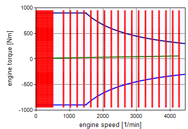

### Electric Motor Model

The VECTO component for the electric motor contains the electric motor itself which is connected via a transmission stage to the drivetrain. The ratio and efficiency of the transmission stage can be defined in the vehicle model.

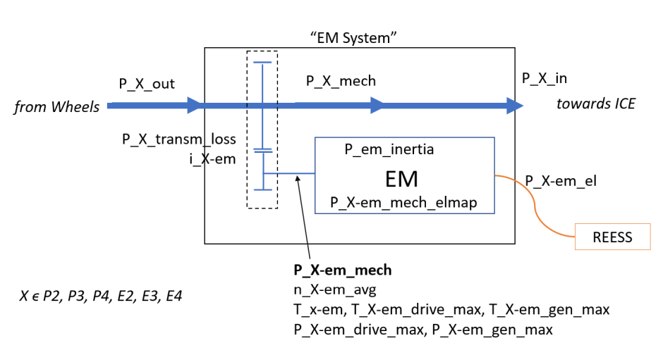

The naming convention for the signals is that ‘X’ denotes the position of the EM in the powertrain. P_X_… denotes signals related to the drivetrain speed while P_X-em_… denotes signals to the electric motor shaft.

P_X_in = P_X_out + P_X_mech

P_X_mech = P_X-em_mech + P_X_transm_loss

P_X-em_mech = P_X-em_mech_elmap + P_X-em_inertia

P_X-em_mech_elmap = P_X-em_el + P_X-em_loss

P_X-em_mech_elmap = n_X-em * T_X-em_map

P_X-em_el = PowerMap(n_X-em, T_X-em_map)

P_X_loss = P_X_mech - P_X-em_el

### Electric Power Map Interpolation

The electric power demand of the electric machine is not directly interpolated in the provided power map. Due to the characteristic of the map (increasing electric power with both, torque and speed) the resulting delaunay map may cause deviations from the assumed electric power demand depending on how the triangles are actually added to the delaunay map.

Therefore, the electric power map is converted to a “virtual torque loss” map similar to the transmission loss-maps. For every entry in the electric power map, the virtual torque loss is calculated as follows:

$T_\textrm{loss,em-map} = \frac{P_\textrm{el}(n_\textrm{em}, T_\textrm{em}) - n_\textrm{em} \cdot T_\textrm{em}}{n_\textrm{em}}$

From the tuple $(n_\textrm{em}, T\textrm{em}, T_\textrm{loss,em-map})$ a Delaunay map is created. In the simulation the actual electric power is then calculated as follows:

$P_\textrm{el}(n_\textrm{em}, T_\textrm{em}) = \textrm{Delaunay}_\textrm{EM-Map}(n_\textrm{em}, T_\textrm{em}) \cdot n_\textrm{em} + n_\textrm{em} \cdot T_\textrm{em}$

### Thermal De-Rating

The electric machine can be overloaded for a certain period. In addition to the maximum drive and generation torque (which already is in overload condition) the mechanical power the electric machine can generate is required.

The basic principal of the thermal de-rating is as follows: based on the continuous power and the angular velocity for the continuous power as well as the maximum overload time a thermal energy buffer is calculated. During the simulation the difference between the current losses in the electric machine and the losses at the continuous power operating point are integrated over time. If this value reaches the capacity of the thermal energy buffer the electric machine can only deliver the specified continuous torque until the thermal energy buffer goes below a certain threshold.

$E_\textrm{th,buf} = (P_\textrm{loss,ovl} - P_\textrm{loss,cont}) \cdot t_\textrm{ovl}$

$P_\textrm{loss,ovl} = P_\textrm{map, el}(T_\textrm{ovl}, n_\textrm{T, ovl}) - n_\textrm{T,ovl} \cdot T_\textrm{ovl}$

$P_\textrm{loss,cont} = P_\textrm{map, el}(T_\textrm{cont}, n_\textrm{T, cont}) - n_\textrm{T,cont} \cdot T_\textrm{cont}$

The overload buffer is calculated for both voltage levels of the electric motor. Both, the overload buffer and continuous losses used in the simulation are interpolated with the voltage level of the REESS at average usable SoC level.

In every simulation step the losses of the electric machine are accumulated:

$E_{\textrm{ovl,} i + 1} = E_{\textrm{ovl,} i} + (P_\textrm{loss, i} - P_\textrm{loss,cont}) \cdot dt$

$P_\textrm{loss, i} = P_\textrm{map, el}(T_\textrm{em, mech}, n_\textrm{em}) - n_\textrm{em} \cdot T_\textrm{em, mech}$

If $E_\textrm{ovl, i}$ reaches the overload capacity $E_\textrm{th,buf}$ the power of the electric machine is limited to the continuous torque until $E_\textrm{ovl,i}$ goes below the overload capacity multiplied by the thermal overload recovery factor. Then the maximum torque is available again.

## Integrated Electric Powertrain Component (IEPC)

Integrated electric powertrain component (IEPC) means a combined system of an electric machine system together with the functionality of either a single- or multi-speed gearbox or a differential or both.

An IEPC can be of design-type wheel motor which means that the output shaft (or two output shafts) are directly connected to the wheel hub(s).

The IEPC is modeled by the following parameters and map files:

- Maximum drive torque over rotational speed (related to the output shaft)
- Maximum generation torque over rotational speed (Related to the output shaft)
- Gear ratios of all gears (electric motor to out shaft)
- Drag curve. either for a single gear (measured with the gear with the ratio closest to 1) or all gears
- Electric power map for all mechanical gears
- Continuous torque and rotational speed (output shaft), measured with the gear with the ratio closest to 1
- Overload torque and rotational speed (output shaft), measured with the gear with the ratio closest to 1
- Maximum overload time

The first two curves are read from a .viepcp file (see IEPC Max Torque File (.viepcp)). The drag curve(s) are provided in .viepcd file(s) (see IEPC Drag Curve File (.viepcd)) and the electric power maps in .viepco file(s) (see IEPC Power Map (.viepco)). It is important to note that for the IEPC all maps are related to the output shaft speed (including all integrated components of the IEPC).

The following paragraph should provide a clear understanding on the modeling aproach and the implementations/adaptions made in VECTO in order to properly depict the functionality of IEPCs.

In the VECTO simulation, the IEPC component is virtually split up into the electric machine (with gear-dependent electric power maps), an APT-N gearbox in case of a multi-speed gearbox and optionally an axle gear using already available models and the same shift strategy as for E2/S2 architectures. All speed and torque values from the component certification are automatically converted from the measurement reference point at the output shaft of the IEPC via the respective gear ratios for each forward gear to the input shaft of the “virtual” transmission component used in VECTO (which is also reflecting the output shaft of the “virtual” EM inside the IEPC). In case of a single-speed IEPC, a simplified transmission component was implemented which requires only one single transmission ratio as compared to the shiftable transmission. Since the measured component data of the IEPC includes also the losses of the gearbox specific parts, the existing VECTO transmission component model is automatically parameterized with a generic dataset depicting a loss-free transmission component, which is only responsible for handling the different transmission ratios for the gear shifting process. Thus, the simulation of an IEPC is similar to E2 vehicles in case of a multi-speed gearbox or an E3 vehicle in case of a single-speed gearbox. For IEPCs with no differential included, in addition to the functions covered by the IEPC (EM and gearbox), an axle component must be configured for the vehicle. However, in the existing architecture of VECTO, input to gearbox and axle are linked. Therefore, to enable the input of an axle component without the need to define at additional gear ratios, as those are already implicitly defined by the IEPC inputs, a dummy gearbox is provided by VECTO.

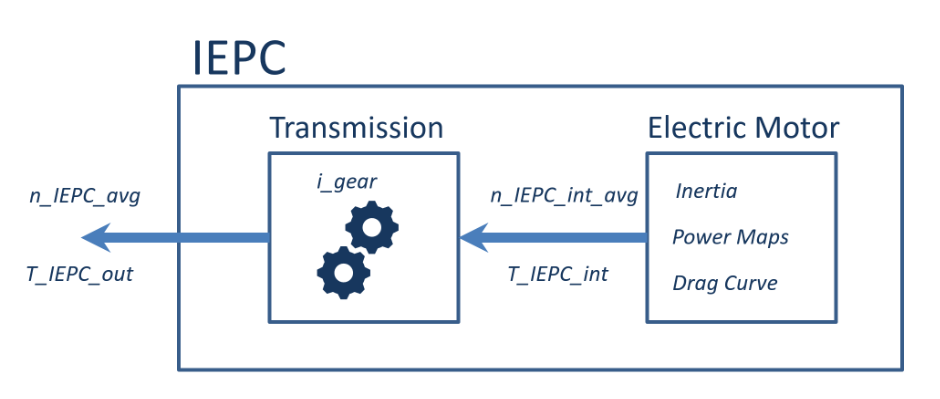

All signals with the suffix “_int” refer to the electric motor, while signals without this suffix refer to the whole component.

## Integrated Hybrid Electric Powertrain Component (IHPC)

Integrated hybrid electric powertrain component (IHPC) means a combined system of multiple electric machine systems together with the functionality of a multi-speed gearbox. An electric machine of type IHPC has to be used together with a gearbox of type IHPC.

The IHPC is modeled by the following parameters and map files:

- Maximum drive torque over rotational speed (related to the output shaft)
- Maximum generation torque over rotational speed (Related to the output shaft)
- Drag curve (shall be 0 as the drag losses are covered by the gearbox model)
- Electric power map for all mechanical gears
- Continuous torque and rotational speed (output shaft), measured with the gear with the ratio closest to 1
- Overload torque and rotational speed (output shaft), measured with the gear with the ratio closest to 1
- Maximum overload time

The first two curves are read from a .viepcp file (see IEPC Max Torque File (.viepcp)). The drag curve(s) are provided in .vemd file(s) (see Electric Motor Drag Curve File (.vemd)) and the electric power maps in .viepco file(s) (see IEPC Power Map (.viepco)). For IHPCs all maps and max. drive/generation torque files refer to the output shaft just like for IEPCs. The values of the drag torque must be set to zero because the drag losses are already included in the IHPC gearbox loss maps due to the virtual split of electric machine and gearbox in the simulation.

The following paragraph should provide a clear understanding on the modeling aproach and the implementations/adaptions made in VECTO in order to properly depict the functionality of IHPCs.

An IHPC is a component in a parallel HEV powertrain which combines the functionality of the EM with a shiftable transmission in one single unit. The exact characteristics of this system are defined in point 2(38) of Annex Xb of Commission Regulation (EU) 2017/2400. The figure below shows the principles of the arrangement of an IHPC in a vehicle powertrain.

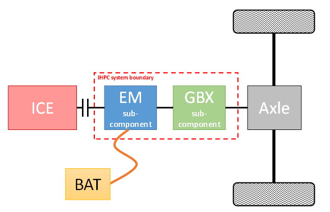

The IHPC is treated for the component test as a black box with three interfaces to other components of the powertrain over which power can be transferred. Two of those are of mechanical type and connected to the ICE and the axle of the vehicle. The third one is of electrical type and connected to the REESS.

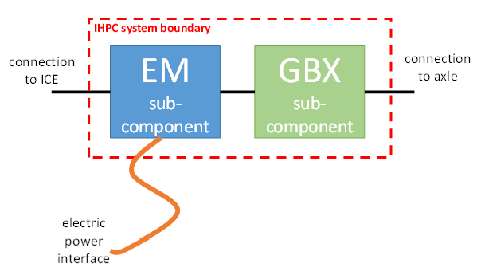

As the IHPC system operates predominantly as a parallel HEV in the relevant driving situations represented in the VECTO simulation, it is treated as such in order to fit into the established modular powertrain design of VECTO. Therefore, the individual functionalities of the black box IHPC have to be split into two virtual separate systems, represented by the parallel powertrain architecture ID “P2” - the one that most closely resembles the IHPC architecture. This means that instead of a single IHPC component, there are two separate standalone components - i.e. EM and transmission - in the vehicle powertrain as simulated by VECTO. In order to be able to parameterize those two standalone components, two separate testruns are required which are based on already existing tests for the components substituting the IHPC:

1. The total system performance and losses (sum of EM and gearbox losses) are determined following the Annex Xb procedure for EM – but measured separately for each gear at the output shaft of the system. The boundary conditions of this testrun are that the system shaft for connecting the ICE is allowed to rotate freely (no torque fed into the system) and the system is only driven by electric power supplied.

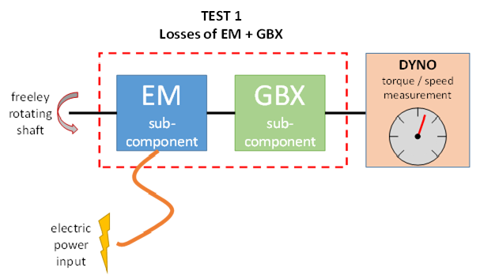

2. The gearbox specific losses are determined in accordance with Annex VI for transmissions of Commission Regulation (EU) 2017/2400. The boundary conditions of this testrun are that the system shaft for connecting the ICE is driven by a dyno (specific propulsion torque fed into the system to maintain a defined operation point at the output) whereas the electric power supply is disconnected. Meaning the difference in power between the two dynos at the input and output side represents the drag losses of the EM as well as the gearbox specific losses.

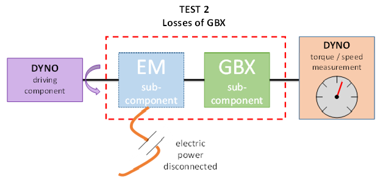

Based on the results of these two testruns, the specific component characteristics for EM and transmission used as substitute for the IHPC are determined by the following post-processing steps:

- All EM data measured at the IHPC output shaft needs to be converted to the EM shaft and the gearbox losses need to be deducted:
  - $\textrm{T}_\textrm{EM} = \textrm{T}_{out-meas} / \textrm{i}_\textrm{GBX} - \textrm{T}_{loss-GBX} (\textrm{n}_{EM},\textrm{T}_{EM})$
  - $\textrm{n}_\textrm{EM} = \textrm{n}_{out-meas} * \textrm{i}_\textrm{GBX}$
- For the transmission component, the losses determined in testrun 2 can be applied directly following the provisions in Annex VI of Commission Regulation (EU) 2017/2400 for transformation of the losses referring to the conditions at the gearbox input side.
- The drag torque curve of the EM component is set to zero since these losses are already included in the transmission losses determined in testrun 2 (as described above).

The specific rules for parameterization of an IHPC on vehicle level using the two separate components substituting the IHPC are described in point 10 of Annex III as well as point 4.4.3 of Annex Xb of Commission Regulation (EU) 2017/2400.

## RESS

### Battery

The battery model uses the following model parameters:

- Capacity of the battery pack
- Maximum current for charging and discharging over the state of charge
- Minimum state of charge
- Maximum state of charge
- Voltage of the battery pack over state of charge
- Internal resistance of the battery pack over state of charge. The internal resistance can either be constant over the pulse duration or depending on the length of the pulse duration (see .vbatr Battery Internal Resistance)

The voltage curve over state of charge is described in Battery Internal Voltage File (.vbatv) and the internal resistance curve over state of charge is described in Battery Internal Resistance File (.vbatr). The file format of the maximum current map is described in Battery Max Current Map (.vimax).

During the simulation the battery’s state of charge must always be between the minimum and maximum SoC threshold.

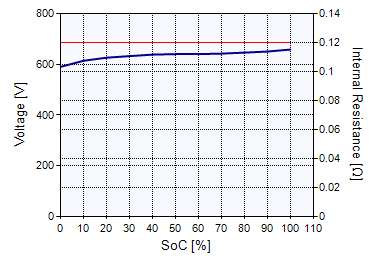

The maximum discharge current is further limited by the battery’s internal resistance:

$I_\textrm{disch,max} = \frac{U(\textrm{SoC})}{4 * R_i(\textrm{SoC})}$

#### Time-dependent Internal Resistance

If the internal resistance is provided for different pulse durations, the actual internal resistance is interpolated between the provided resistance values with the current pulse duration. No extrapolation is applied. For pulses below Ri_2, Ri_2 is applied, for pulse durations longer then Ri_20 (or Ri_120 if provided) this value is used. The pulse duration is reset every time the current changes its sign.

### Modular Battery System

VECTO allows to connect multiple batteries together to a single battery system. Therefore, every battery has assigned a stream identifier. All batteries with the same stream identifier are connected in series. All battery strins are then connected in parallel.

The following picture shows 4 batteries in series (3x Bat A + Bat B) and Bat C parallel to this. So two different streams need to be defined.

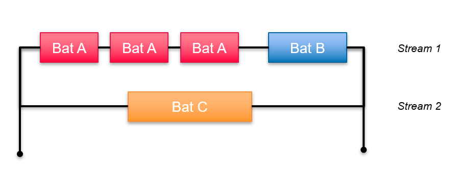

All batteries of a string of the modular battery system are aggregated to a single “big battery”. In the example above, BigBattery1 consists of (Bat A, Bat A, Bat A, Bat B), and BigBattery2 consists of (Bat C). Nevertheless, the state of charge is calculated for each battery module independently.

The capacity of a BigBattery is the capacity of the smallest of all modules on a string. The maximum current of a BigBattery is also the lowest maximum current of all modules on a string. The open circuit voltage is the sum of all modules on a string and the internal resistance is also the sum of all modules on a string.

The maximum charge and discharge power of the whole REESS is the sum of the maximum charge/discharge power of all BigBatteries in the system. The actual power demand is distributed to the BigBatteries as follows:

$P_i = \frac{C_i}{\sum_{j}{C_j}} \cdot \delta_i \cdot P_\textrm{act}$

$\delta_i = 1 - \textrm{sgn}(P_\textrm{act})\frac{\textrm{SoC}_i - \textrm{SoC}_\textrm{avg}}{\textrm{SoC}_\textrm{avg}}$

$\textrm{SoC}_\textrm{avg} = \frac{\sum_j{\textrm{SoC}_j \cdot C_j}}{\sum_j{C_j}}$

$\textrm{SoC}_i = \frac{\min_{B \in BB}(\textrm{SoC}_B \cdot C_B)}{C_i}$

$P_i$ … Power for BigBattery i

$C_i$ … Nominal capacity of BigBattery i.

$P_\textrm{act}$ … actual power demand

In case a BigBattery reaches its max. power, the power for this BigBattery is limited to its max. power and then the power distribution is re-calculated with the remaining power demand.

To update the state of charge of each battery, the current $I_i$ for each BigBattery is computed from the following equation:

$P_i = (U_i + R_i \cdot I_i) \cdot I_i$

And then the power demand for every single battery can be computed from

$P_{B_i} = (U_{B_i} + R_{B_i} \cdot I_i) \cdot I_i$

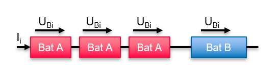

### Super Capacitor

The super capacitor model uses the following model parameters:

- Capacity of the SuperCap in Farad
- Internal resistance
- Minimum voltage
- Maximum voltage
- Maximum current charging
- Maximum current discharging

The values of maximum charging current and maximum discharging current need to be positive!

## Parallel Hybrid Control Strategy

The basic principle of the hybrid control strategy is to evaluate different options of operating modes, i.e., different splits of the demanded torque at the wheels among the electric motor and the combustion engine. For every option a cost function is calculated, taking onto account the required electric energy and the fuel consumption. Out of the examined operating modes the best option, i.e, the option with the lowest cost value is selected.

The hybrid control is located in the simulated power train right after the wheels. Hence, the hybrid control strategy gets the torque and angular velocity at the wheels as input.

### Model Parameters

#### Hybrid Strategy

- MinICEOnTime
- MinSoC
- MaxSoC
- TargetSoC
- EquivalenceFactor
- Cost Factor SoC Exponent $e$
- AuxReserveTime
- AuxReserveChargeTime

#### Gear Selection

- MinTimeBetweenGearshifts
- DownshiftAfterUpshiftDelay
- UpshiftAfterDownshiftDelay
- AllowedGearRangeUp
- AllowedGearRangeDown

### Evaluation of different options

Note: The convention is that for all powertrain components (except the ICE) a positive torque loss means an additional drag while a negative torque loss means the component contributes to propel the vehicle. So all passive components can only apply positive torque losses and only active components such as electric motors can propel the vehicle which means it has a negative torque loss.

The variable u is used to identify the different evaluated options. The value of u denotes the factor how much of the torque at the output shaft of the electric motor is applied by the electric motor. A u value of -1 thus means the electric motor provides the full torque demanded at its output shaft and the torque at the input shaft is 0. A positive value of u means that the electric motor acts as generator and applies a torque demand in addition.

In case the driver’s action is to accelerate the vehicle, the hybrid control strategy performs the following steps to obtain a list of potential configurations:

1. Issue a dry-run request with the currently demanded torque and angular speed.

   For this request the electric motor is switched off. The purpose of this request is to get the resulting power demand at the combustion engine and more importantly, to get the minimum/maximum torque the electric motor can provide and the maximum/minimum torque the combustion engine can provide. This is also a viable configuration and thus added to the list of evaluated configurations
2. Evaluate options where the electric motor contributes to propel the vehicle.
   1. Iterate over all negative u values with a certain step size (typically 0.1) up to u_maxDrive u_maxDrive is determined by the torque demanded at the out shaft of the electric motor and the maximum drive torque of the electric motor – whichever is lower.
   2. If the case where the electric motor applies its maximum drive torque is not already covered by the  
      iteration of u values in the previous step, calculate the maximum drive configuration explicitly
   3. If it is allowed to turn off the electric motor or the electric motor can propel during gear shifts, search the torque the electric motor needs to provide so that the torque at the gearbox input gets 0. This means the electric motor provides more torque than demanded in order to overcome losses of components later in the powertrain. If this torque value is within the limits of the electric motor, calculate the corresponding u value and add this option to the list of evaluated configurations.
3. Evaluate options where the electric motor acts as generator and applies additional drag losses.
   1. Iterate over all positive u values with a certain step size (typically 0.1) up to the electric motor’s maximum generation torque.
   2. For vehicles of configuration P2 evaluate the configuration where the electric motor’s generation torque equals the torque demanded at the electric motor’s output shaft (i.e., the torque at the electric motor’s input shaft is 0) if it is allowed to turn of the ICE.
   3. For vehicles of configuration P3 and P4 search for the torque the electric motor has to apply as a generator so that the resulting torque at the combustion engine is 0. If this torque value is within the limits of the electric motor, calculate the corresponding u value and add this option to the list of evaluated configurations.

In case of a coast or roll action (e.g. during look-ahead coasting dur during traction interruption) the electric motor is turned off.

In case the driver performs a brake action the following options are considered

1. In case of vehicle configurations P3 or P4, or vehicle configuration P2 and the gearbox is engaged:
   1. If the combustion engine is on and the torque demand at the combustion engine is above the drag curve, switch the electric motor off.
   2. If the torque demand at the combustion engine is below the drag curve, evaluate all options as described for the case the driver accelerates (see above).
2. In case of vehicle configuration P2 and the gearbox is not engaged, turn the electric motor off

### Gear selection

For hybrid vehicles it is not possible to decouple gear selection from the electric motor’s operating point because the gearshift strategy only considers the çombustion engine’s operating point. In some situations it is more efficient to select a different gear which results in an overall more efficient operating point (considering both, electric motor and combustion engine).

The hybrid strategy combines the main ideas of the EffShift gearshift strategy and the selection of the best operating point.

Depending on the last gearshift the allowed gear range for upshifts and downshifts is determined. For every allowed gear all possible settings of the hybrid powertrain as describe above are evaluated.

### Cost Function

A cost value is calculated for every evaluated solution described above. In case the configuration results in an invalid operating point the cost value is set to invalid. Reasons for invalid configurations are that the engine operating point is outside the shift polygons, the engine speed is too high or too low, the electric power demand is too high or too low, the battery’s SoC would go below the $\textrm{SoC}_{low}$ threshold, etc.

For all valid configurations a cost function is calculated which basically considers the fuel consumption and the electric power:

$C = \sum_{i \in \textrm{Fuels}}{FC_{i} \cdot NCV_{i} \cdot dt} + f_{\textrm{equiv}} \cdot (P_\textrm{Bat} \cdot dt + C_{\textrm{Pen1}}) \cdot f_{SoC} + C_{\textrm{Pen2}}$

- FC is the combustion engine’s fuel consumption for the current simulation interval
- NCV denotes the fuel’s net calorific value
- $P_\textrm{Bat}$ is the power drawn from the battery. Positive values denote the battery is discharged
- $f_\textrm{equiv}$ is the equivalence factor to compare energy from the ICE and energy from the electric system. Typically in the range of 2.5
- $f_\textrm{SoC}$ is a cost factor that depends on the battery’s state of charge.
- $C_\textrm{Pen1}$ is a penalty for starting the combustion engine. It is set to 0.1 times the energy required to ramp up the combustion engine. The ramp-up energy is calculated the same way as for the engine stop/start correction - see Advanced Driver Assistant Systems: Engine Stop/Start.

  If the combustion engine is currently off and is off in the considered configuration $P_\textrm{Pen1}$ is set to 0.

  If the battery’s SoC is below the lower SoC threshold $\textrm{SoC}_{low}$ then $P_\textrm{Pen1}$ is set to 0.
- $C_\textrm{Pen2}$ is a penalty considering idling costs of the combustion engine, currently set to 0.

$f_\textrm{SoC} = 1 - \left(\frac{\textrm{SoC} - \textrm{TargetSoC}}{0.5 \cdot (\textrm{SoC}_\textrm{max} - \textrm{SoC}_{min}} \right)^e + C_\textrm{SoC}$

$C_\textrm{SoC} = \left\{ \begin{array}{ll} \frac{C_\textrm{minSoC}}{\textrm{SoC}_\textrm{min} - \textrm{SoC}_{low}} \cdot \textrm{SoC} + p_\textrm{minSoC} - \frac{C_\textrm{minSoC}}{\textrm{SoC}_\textrm{min} - \textrm{SoC}_{low}} \cdot \textrm{SoC}_{min} : \textrm{SoC} < \textrm{SoC}_{low}\\ 0 : \textrm{otherwise} \end{array} \right.$

$\textrm{SoC}_\textrm{low} = \textrm{SoC}_{min} + 0.1 \cdot \left(\textrm{SoC}_{max} - \textrm{SoC}_{min}\right)$

$C_\textrm{minSoC} = 10$

The following graph depicts the shape of $f_\textrm{SoC}$ (red line) and both summands separately (blue: polynomial function, orange: C_) for a minimum SoC of 20%, maximum SoC of 80% and a target SoC of 50%;

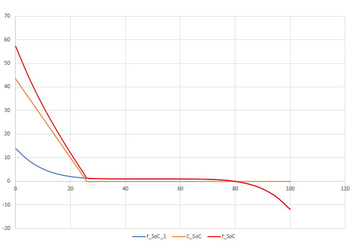

#### Flags for ignoring a evaluated hybrid configuration

- *EngineSpeedTooLow*: the engine speed is below the engine idle speed
- *EngineSpeedTooHigh*: the engine speed is above the engine’s $n_{95h}$ speed
- *EngineTorqueDemandTooHigh*: the torque demanded from the engine is above the dynamic full-load
- *EngineTorqueDemandTooLow*: the torque demanded from the engine is below the drag-torque
- *EngineSpeedAboveUpshift*: the engine operating point is right of the upshift line of the current gear
- *EngineSpeedBelowDownshift*: the engine operating point is left of the downshift line of the current gear
- *BatteryBelowMinSoC*: the battery’s state of charge falls below the allowed minimum SoC
- *BatteryAboveMaxSoC*: the battery’s state of charge exceeds the allowed maximum SoC
- *BatterySoCTooLow*: the strategy may add a certain safety margin to the minimum SoC for certain reasons. Set if the SoC falls below the lower boundary $\textrm{SoC}_\textrm{low}$

### Selection of the best option.

From the list of possible hybrid powertrain configurations with its cost value the best option is selected according to the following list of conditions. If one or many configurations match the criteria listed in a step, the first configuration is used. If no configuration matches the criteria the next step is evaluated.

1. Select all configurations with a valid score (i.e. the score is not NaN).
   - If the vehicle speed is above the gearbox’ start speed no flag to ignore the configuration must be set.
   - If the vehicle speed is below the gearbox’ start speed (i.e. the vehicle is accelerating from standstill) the engine speed must not be too high.
   - Order the configurations by score
2. Select all configurations with a valid score and the engine speed is valid (i.e., not too high, nor too low and within the shift lines) and order by score
3. Select all configurations with a valid score and order by score
4. If the driver is accelerating and in all evaluated configurations the engine’s torque demand is above the engine’s maximum torque filter the possible configurations according to the following criteria
   1. If the electric motor can propel during traction interruptions (i.e., P4 and P3 configurations) or the gearbox is engaged (P2 configuration) select all configurations where the battery SoC is within the allowed range, order the configurations by difference in gear to the current gear and then order the configurations by the mechanical torque the electric motor can provide
5. If the driver is accelerating and in all evaluated configurations the engine’s torque demand is below the engine’s drag torque filter the possible configurations according to the following criteria. If the electric motor can propel during traction interruptions (i.e., P4 and P3 configurations) or the gearbox is engaged (P2 configuration)
   1. Select all configurations where the engine speed is valid and the battery’s SoC is within the allowed range and order the configurations by the difference in gear to the current gear and then by the mechanical torque the motor can provide
   2. Select all configurations where the battery’s SoC is within the allowed range and order the configurations by the difference in gear to the current gear and then by the mechanical torque the motor can provide
6. If the driver is accelerating and the gearbox is engaged filter the possible configurations according to the following criteria.
   1. Select all configurations where the engine speed is not too low nor too high and order the configurations by the difference in gear to the current gear
   2. If no entries match the previous criteria order all configurations by the difference in gear to the current gear
   3. Order the configurations by the mechanical torque provided by the electric motor
7. If the driver is braking and the gearbox is engaged select all configurations where the battery SoC is within the allowed range and order by the torque the electric motor can apply for braking

## Serial Hybrid Control Strategy

The basic principle of the serial hybrid strategy is to operate the GenSet in three different states, depending on the power demand of the drivetrain and the REESS’ state of charge. So the serial hybrid strategy operates as a three-point controller with a hysteresis.

The following picture illustrates the basic idea. If the SoC is above the target SoC, the GenSet is off and the vehicle drives solely from the battery. When the SoC gets lower and reaches the SoC_min threshold, the GenSet is switched on. As long as the SoC is between SoC_min and SoC_target, the GenSet operates in the optimal operating point. When the upper threshold SoC_target is reached, the GenSet is switched off. In case the power demand from the drivetrain is higher than what the GenSet can provide in the optimal point and the SoC falls below the lower threshold SoC_min, the GenSet operates either in the maximum power operating point (if the drivetrain power demand is higher than the power generated in the optimal point) or in the optimal point.

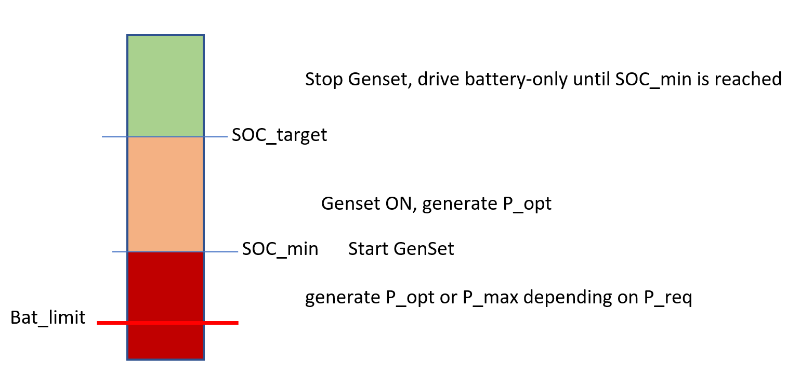

The state machine for the serial hybrid control strategy is depicted here:

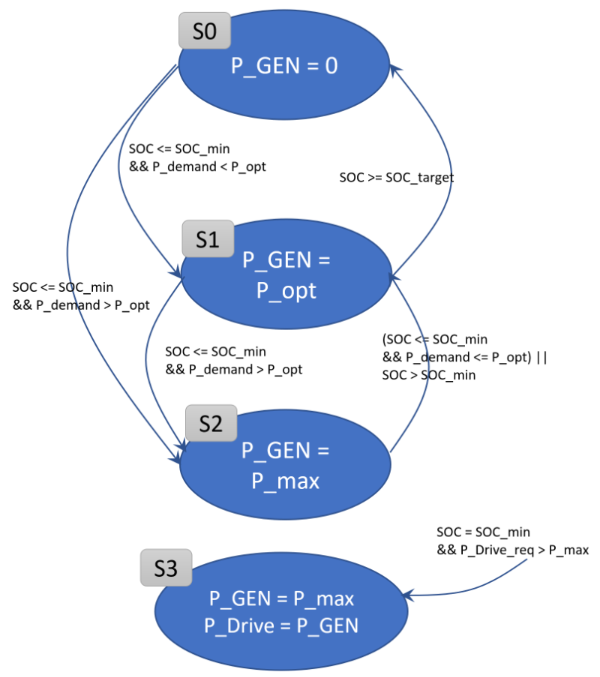

**Note:** The SoC boundaries (SoC_target and SoC_min) shall be narrower than the batteries SoC limits so that on the one hand the vehicle can still recuperate even in case the REESS is charging and reaching the target SoC and on the other hand that there is a buffer available if the drivetrain power demand is high and the GenSet needs some time to ramp up to the maximal power operating point.

### GenSet Pre-Processing

The optimal and maximal GenSet operating points are calculated in a preprocessing step. The fuel consumption and generated electric power is calculated for 400 different operating points: from ICE idle speed up to the maximum speed (minimum of ICE and electric motor), and from 0 mechanical power up to the maximum mechanical power of the ICE. Out of this set of operating points the one with the highest electrical power and the operating point with the best fuel efficiency is selected. This is done for the GenSet operating in de-rating or not.

## In-Motion Charging

Vehicles with in-motion charging are simulated in VECTO in a twofold approach. The effect of the additional air-drag when in-motion charging is active (e.g. pantograph, etc) is considered in the in-the-loop simulation. The effect of additional electric driving range and electric energy consumption from the grid is considered in a post-processing step.

In engineering mode only the effect of the additional air-drag when in-motion charging is active can be considered. The following model parameter are necessary for IMC in engineering mode:

- Share of in-motion charging infrastructure available on total mission distance
- Delta CdxA with active in-motion charging feature
- In-motion charging feature only available on motorway sections

**Note:** In case “In-motion charging feature only applicable on motorway sections” is selected, the value for “Share of in-motion charging infrastructure available on total mission distance” must be aligned with the distance shares declared as “highway” in the driving cycle.

If “In-motion charging feature only available on motorway sections” is selected, then the additional CdxA is only applied to when driving on highway sections. The additional CdxA is calculated from the “Share of in-motion charging infrastructure available on total mission distance” and “Delta CdxA with active in-motion charging feature”.

In engineering mode, no post-processing for the electric range and electric energy consumption is done as the mission parameters and usage parameters are not known.

In declaration mode the technology for in-motion charging can be selected. Depending on the technology, delta CdxA is looked up from the generic parameters. Also the share of in-motion charging infrastructure availability is generic per mission.

The generic values can be found in the *Declaration* folder and in the Excel file for in-motion post-processing.

The post-processing for the utility factor (OVC-HEV) and electric energy consumption and electric range (OVC-HEV, PEV) is described in a separate Excel file

# Input and Output

Vecto uses data files for input and output of data. These are stored in different formats which are listed here.

**Input:**

- JSON
- Vecto CSV
- XML

**Output:**

- JSON
- Vecto CSV
- XML Declaration Report

## XML Job-File (Declaration Mode)

For vehicle certification the input data (vehicle data) has to be provided in XML format. Please see the following resources for more information:

- XML schema description
- XML schema diagram
- Example of an XML Job-File

## XML Declaration Report

In Declaration Mode VECTO generates two reports according to the Technical Annex for vehicle certification:

- Manufacturer Report
- Customer Information Report

Both reports are in XML format and contain a description of the simulated vehicle and the simulation results. The format is described in the following resources:

- Manufacturer Report XML schema
- Manufacturer Report XML schema diagram
- Customer Report XML schema
- Customer Report XML schema diagram

Sample reports are distributed with the generic vehicles.

**Note:** For better readability and improved presentation, the XML has attached a style sheet that allows nice rendering in web-browsers. If you open an XML report in your browser, you may be asked the credentials for the CITnet SVN server (same credentials as you need for downloading VECTO) as the CSS is hosted on CITnet.

## CSV

Many data files in VECTO use CSV (Comma Separated Values) as common file format. They consist of a header which defines the columns and data entries which are separated by a comma (“,”).

In VECTO 3 the order of the columns is arbitrary if the column header matches the header definitions described in this user manual. If the column header does not match, a warning is written to the log file and the columns are parsed in the sequence as described in this manual as a fall-back.

### Definition

| **Header:** | VECTO CSV needs exactly one header line with the definition of the columns at the beginning of the file. Columns can be surrounded with “<” and “>” to mark them as identifiers (which makes them positi… |
| --- | --- |
| **Column Separator:** | **,** (Comma. Separates the columns of a data line.) |
| **Decimal-Mark:** | **.** (Dot. Splits numbers into integer part and decimal part.) |
| **Thousand-Separator:** | VECTO CSV does not allow a thousand-separator. |
| **Comments:** | **#** (Number sign. Declares text coming afterwards in the current line as comment.) |
| **Whitespace:** | Whitespaces between columns will be stripped away. Therefore it is possible to align the columns for better readability, if desired. |

**Note:** All column headers are case insensitive.

**Note:** Unit information in the column header (enclosed in “[” and ”]”) are only information for the user. VECTO does **not** read the unit string nor convert between units. The values are expected to be in the units as specified in the user manual.

Following files use the csv:

- Speed Dependent Cross Wind Correction Input File (.vcdv)
- Vair & Beta Cross Wind Correction Input File (.vcdb)
- Retarder Loss Torque Input File (.vrlm)
- Full Load and Drag Curves (.vfld)
- Fuel Consumption Map (.vmap)
- Shift Polygons Input File (.vgbs)
- Transmission Loss Map (.vtlm)
- Torque Converter Characteristics (.vtcc)
- Driving Cycles (.vdri)
- Acceleration Limiting Input File (.vacc)
- Modal Results (.vmod)
- Summary Results (.vsum)

### Examples

#### Exampl 1: Acceleration Limiting File

```
v [km/h],acc [m/s^2]     ,dec [m/s^2]
0       ,1.01570922360353,-0.231742702878269
5       ,1.38546581120225,-0.45346198022574
10      ,1.34993329755465,-0.565404125020508
15      ,1.29026714002479,-0.703434814668512
```

#### Example 2: Driving Cycle

```
<s>,<v>,<grad>      ,<stop>,<Padd>,<Aux_ALT1>,<Aux_ALT2>,<Aux_ALT3>
0  ,0  ,-0.020237973,2     ,6.1   ,0.25      ,0.25      ,0.25
1  ,64 ,-0.020237973,0     ,6.1   ,0.25      ,0.25      ,0.25
2  ,64 ,-0.020237973,0     ,6.1   ,0.25      ,0.25      ,0.25
3  ,64 ,-0.020237973,0     ,6.1   ,0.25      ,0.25      ,0.25
```

#### Example 3: Transmission Loss Map

```
Input Speed [rpm],Input Torque [Nm],Torque Loss [Nm]
0                ,-2500            ,77.5
0                ,-1500            ,62.5
0                ,-500             ,47.5
0                ,500              ,47.5
```

## JSON

Configuration and component files in VECTO use JSON as common file format.

Following files use JSON:

- Job
- Vehicle
- Engine
- Gearbox
- Shift Parameters

## Job File

File for the definition of an job in VECTO. A job contains everything what is needed to run a simulation. Can be created with the Job Editor.

- File format is JSON.
- Filetype ending is “.vecto”

Refers to other files:

- Vehicle (VVEH)
- Engine (VENG)
- Gearbox (VGBX)
- Driving Cycle (VDRI)
- Acceleration Limiting (VACC)

**Example:**

```json
{
  "Header": {
    "CreatedBy": "",
    "Date": "2020-09-07T15:36:16.4539236Z",
    "AppVersion": "3",
    "FileVersion": 8
  },
  "Body": {
    "SavedInDeclMode": false,
    "EngineOnlyMode": false,
    "VehicleFile": "Group5_HEV.vveh",
    "EngineFile": "Engine_325kW_12.7l.veng",
    "GearboxFile": "AMT_12.vgbx",
    "TCU": "AMT_12.vgbx",
    "ShiftStrategy": "TUGraz.VectoCore.Models.SimulationComponent.Impl.AMTShiftStrategy",
    "HybridStrategyParams": "Hybrid_Parameters.vhctl",
    "AuxiliaryAssembly": "Classic",
    "AuxiliaryVersion": "CLASSIC",
    "AdvancedAuxiliaryFilePath": "",
    "Aux": [],
    "Padd": 5000.0,
    "Padd_electric": 0.0,
    "VACC": "Truck.vacc",
    "EngineStopStartAtVehicleStopThreshold": 2.0,
    "EngineStopStartMaxOffTimespan": 120.0,
    "EngineStopStartUtilityFactor": 1.0,
    "EcoRollMinSpeed": 0.0,
    "EcoRollActivationDelay": 0.0,
    "EcoRollUnderspeedThreshold": 0.0,
    "EcoRollMaxAcceleration": 0.0,
    "PCCEnableSpeed": 0.0,
    "PCCMinSpeed": 0.0,
    "PCCUnderspeed": 0.0,
    "PCCOverSpeed": 5.0,
    "PCCPreviewDistanceUC1": 0.0,
    "PCCPreviewDistanceUC2": 0.0,
    "LAC": {
      "Enabled": true,
      "PreviewDistanceFactor": 10.0,
      "DF_offset": 2.5,
      "DF_scaling": 1.5,
      "DF_targetSpeedLookup": "",
      "Df_velocityDropLookup": "",
      "MinSpeed": 50.0
    },
    "OverSpeedEcoRoll": {
      "Mode": "Overspeed",
      "MinSpeed": 50.0,
      "OverSpeed": 2.5
    },
    "Cycles": [
      "LongHaul.vdri",
      "RegionalDelivery.vdri",
      "UrbanDelivery.vdri"
    ]
  }
}
```

## VTP-Job File

File for the definition of a verification test job in VECTO. A job contains everything what is needed to run a simulation. Can be created with the Verification Test Job Editor.

- File format is JSON.
- Filetype ending is “.vecto”

Refers to other files:

- Vehicle (XML)
- Gearbox (VGBX)
- Driving Cycle (VDRI)

**Example:**

```json
{
  "Header": {
    "CreatedBy": "VECTO 3.2",
    "Date": "2017-11-14T13:16:31.7337506Z",
    "AppVersion": "3",
    "FileVersion": 4
  },
  "Body": {
    "SavedInDeclMode": false,
    "DeclarationVehicle": "SampleVehicle.xml",
    "ManufacturerRecord": "SampleVehicle.MRF.xml",
    "Mileage": 30000.0,
    "FanPowerCoefficients": [
      0.00000055,
      14.62,
      108.5
    ],
    "FanDiameter": 0.225,
    "FuelNCVs": [
      {
        "Type": "Diesel CI",
        "NCV": 42.7
      },
      {
        "Type": "NG CI",
        "NCV": 48.0
      }
    ],
    "TorqueDriftLeftWheel": 0.0,
    "TorqueDriftRightWheel": 0.0,
    "Cycles": [
      "VTP-cycle.vdri"
    ]
  }
}
```

## Vehicle File (.vveh)

File for the definition of a vehicle in VECTO. Can be created with the Vehicle Editor.

- File format is JSON.
- Filetype ending is “.vveh”

Refers to other files:

- Cross Wind Correction (VCDV, VCDB)
- Retarder Loss Map (VRLM)
- Transmission Loss Map (for Angular Gear) (VTLM)

**Example:**

```json
{
  "Header": {
    "CreatedBy": "",
    "Date": "2020-09-07T15:36:11.4469594Z",
    "AppVersion": "3",
    "FileVersion": 10
  },
  "Body": {
    "SavedInDeclMode": false,
    "VehCat": "Tractor",
    "LegislativeClass": "Unknown",
    "CurbWeight": 8229.0,
    "CurbWeightExtra": 7500.0,
    "MassMax": 18.0,
    "Loading": 19300.0,
    "rdyn": 492.0,
    "CdCorrMode": "CdofVdecl",
    "CdCorrFile": "",
    "AxleConfig": {
      "Type": "4x2",
      "Axles": [
        {
          "Inertia": 14.9,
          "Wheels": "315/70 R22.5",
          "AxleWeightShare": 0.2,
          "TwinTyres": false,
          "RRCISO": 0.0055,
          "FzISO": 33350.0,
          "Type": "VehicleNonDriven"
        },
        {
          "Inertia": 14.9,
          "Wheels": "315/70 R22.5",
          "AxleWeightShare": 0.25,
          "TwinTyres": true,
          "RRCISO": 0.0065,
          "FzISO": 33350.0,
          "Type": "VehicleDriven"
        },
        {
          "Inertia": 19.2,
          "Wheels": "385/65 R22.5",
          "AxleWeightShare": 0.18333,
          "TwinTyres": false,
          "RRCISO": 0.0055,
          "FzISO": 41690.0,
          "Type": "Trailer"
        },
        {
          "Inertia": 19.2,
          "Wheels": "385/65 R22.5",
          "AxleWeightShare": 0.18333,
          "TwinTyres": false,
          "RRCISO": 0.0055,
          "FzISO": 41690.0,
          "Type": "Trailer"
        },
        {
          "Inertia": 19.2,
          "Wheels": "385/65 R22.5",
          "AxleWeightShare": 0.18334,
          "TwinTyres": false,
          "RRCISO": 0.0055,
          "FzISO": 41690.0,
          "Type": "Trailer"
        }
      ]
    },
    "EngineStopStart": true,
    "EcoRoll": "None",
    "PredictiveCruiseControl": "None",
    "ATEcoRollReleaseLockupClutch": false,
    "CdA": 5.3,
    "VehicleHeight": 4.0,
    "IdlingSpeed": 600.0,
    "Retarder": {
      "Type": "None",
      "Ratio": 1.0,
      "File": ""
    },
    "Angledrive": {
      "Type": "None",
      "Ratio": 0.0,
      "LossMap": ""
    },
    "PTO": {
      "Type": "None",
      "LossMap": "",
      "Cycle": ""
    },
    "TorqueLimits": {},
    "MaxDrivetrainPower": 1000.0,
    "InitialSoC": 50.0,
    "PowertrainConfiguration": "ParallelHybrid",
    "ElectricMotors": [
      {
        "Count": 1,
        "Ratio": 1.0,
        "MechanicalEfficiency": 1.0,
        "Position": "P2",
        "MotorFile": "GenericEMotor_140kW_936Nm.vem"
      }
    ],
    "Battery": {
      "NumPacks": 1,
      "BatteryFile": "GenericBattery_10kWh_658V.vbat"
    }
  }
}
```

## Speed Dependent Cross Wind Correction Input File (.vcdv)

The file is needed for speed dependent Cross Wind Correction. The file uses the VECTO CSV format.

- Filetype: .vcdv
- Header: **v_veh [km/h], Cd [-]**
  - **v_veh [km/h]**: the vehicle speed
  - **Cd [-]**: the scaling factor which will be multiplied with the base C<sub>d</sub>A value.
- Requires at least 2 data entries

**Example:**

```
v_veh [km/h],Cd [-]
0           ,1.173
5           ,1.173
10          ,1.173
15          ,1.173
20          ,1.173
25          ,1.173
30          ,1.173
35          ,1.173
40          ,1.173
45          ,1.173
50          ,1.173
55          ,1.173
60          ,1.173
65          ,1.153
70          ,1.136
75          ,1.121
80          ,1.109
85          ,1.099
90          ,1.090
95          ,1.082
100         ,1.07
```

## Vair & Beta Cross Wind Correction Input File (.vcdb)

The file is needed for Vair & Beta Cross Wind Correction. The file uses the VECTO CSV format.

- Filetype: .vcdb
- Header: **beta [°], delta CdA [m^2]**
  - **beta [°]**: the wind yaw angle (0° means that the wind comes directly from the front)
  - **delta CdA [m^2]**: The ΔC<sub>d</sub>A value which will be added to the base C<sub>d</sub>A value.
- Requires at least 2 data entries

**Example:**

```
beta [°],delta CdA [m^2]
0       ,0.00
1       ,0.07
2       ,0.21
3       ,0.40
4       ,0.64
5       ,0.90
6       ,1.19
7       ,1.48
8       ,1.76
9       ,2.02
10      ,2.25
20      ,3.14
40      ,3.24
60      ,-0.76
80      ,-4.76
100     ,-9.01
120     ,-15.01
140     ,-21.01
160     ,-20.86
180     ,-16.15
```

## Retarder Loss Torque Input File (.vrlm)

This file is used to define retarder idling losses. It can be used for primary and secondary retarders and must be set in the Vehicle File. The file uses the VECTO CSV format.

- Filetype: .vrlm
- Header: **Retarder Speed [1/min], Torque Loss [Nm]**
- Requires at least 2 data entries

**Example:**

```
Retarder Speed [1/min],Torque Loss [Nm]
0                     ,10
100                   ,10.02
200                   ,10.08
300                   ,10.18
...
```

## Engine File (.veng)

File for the definition of an engine in VECTO. Can be created with the Engine Editor.

- File format is JSON.
- Filetype ending is “.veng”

Refers to other files:

- Full Load And Drag Curve (VFLD)
- Fuel Consumption (VMAP)

**Example:**

```json
{
  "Header": {
    "CreatedBy": "",
    "Date": "2019-12-03T16:57:31.6048929Z",
    "AppVersion": "3",
    "FileVersion": 5
  },
  "Body": {
    "SavedInDeclMode": false,
    "ModelName": "325kW 12.7l Engine",
    "Displacement": "12740",
    "IdlingSpeed": 600.0,
    "Inertia": 5.1498,
    "Fuels": [
      {
        "WHTC-Urban": 0.0,
        "WHTC-Rural": 0.0,
        "WHTC-Motorway": 0.0,
        "WHTC-Engineering": 1.0,
        "ColdHotBalancingFactor": 0.0,
        "CFRegPer": 1.0,
        "FuelMap": "325kW_WHR.vmap",
        "FuelType": "EthanolPI"
      },
      {
        "WHTC-Urban": 1.0,
        "WHTC-Rural": 1.0,
        "WHTC-Motorway": 1.0,
        "WHTC-Engineering": 1.024,
        "ColdHotBalancingFactor": 1.0,
        "CFRegPer": 1.0,
        "FuelMap": "325kW_DF.vmap",
        "FuelType": "DieselCI"
      }
    ],
    "RatedPower": 0.0,
    "RatedSpeed": 0.0,
    "MaxTorque": 0.0,
    "FullLoadCurve": "325kW.vfld",
    "WHRType": [
      "ElectricalOutput"
    ],
    "WHRCorrectionFactors": {
      "Electrical": {
        "Urban": 0.0,
        "Rural": 0.0,
        "Motorway": 0.0,
        "ColdHotBalancingFactor": 0.0,
        "CFRegPer": 0.0,
        "EngineeringCorrectionFactor": 1.02
      }
    }
  }
}
```

## Full Load and Drag Curves (.vfld)

This file contains the full load and drag curves and the PT1 values for the transient full load calculation. The file uses the VECTO CSV format.

- Filetype: .vfld
- Header: **engine speed [1/min], full load torque [Nm], motoring torque [Nm], PT1 [s]**
  - **engine speed [1/min]**: the engine speed in rpm.
  - **full load torque [Nm]**: the maximum possible full load for the engine speed.
  - **motoring torque [Nm]**: the minimum possible drag load in motoring for the engine speed.
  - **PT1 [s]**: the PT1 constant for the transient full load calculation.
- Requires at least 2 data entries

**Note:** The PT1 column is not required in Declaration Mode! Pre-defined values are used.

**Example:**

```
engine speed [1/min],full load torque [Nm],motoring torque [Nm],PT1 [s]
560                 ,1180                 ,-149                ,0.6
600                 ,1282                 ,-148                ,0.6
800                 ,1791                 ,-149                ,0.6
...
```

## Fuel Consumption Map (.vmap)

The FC map is used to interpolate the base fuel consumption before corrections are applied. For details see Fuel Consumption Calculation. The file uses the VECTO CSV format.

- Filetype: .vmap
- Header: **engine speed [rpm], torque [Nm], fuel consumption [g/h]**, *whr power electrical [W]*, *whr power mechanical [W]* (required only if an electric or mechanical WHR system is used)
- Requires at least 3 data entries
- The map must cover the full engine range between full load and motoring curve.

Extrapolation of fuel consumption map is possible in Engineering Mode (with warnings!). In Declaration Mode it is not allowed.

**Example:**

```
engine speed [rpm],torque [Nm],fuel consumption [g/h]
600               ,-45        ,0
600               ,0          ,767
600               ,100        ,1759
600               ,200        ,2890
600               ,300        ,4185
600               ,400        ,5404
600               ,500        ,6535
600               ,600        ,7578
...
```

**Example with electric WHR***

```
engine speed [rpm] , torque [Nm] , fuel consumption [g/h] , whr power electric [W]
500                , -135.5      , 0                      , 200
500                , 0           , 1355                   , 200
500                , 213.4       , 3412.291               , 200
500                , 426.8       , 5830.1                 , 200
500                , 640.2       , 8316.426               , 200
500                , 853.6       , 10439.87               , 200
500                , 1067        , 12823.69               , 200
500                , 1188        , 14228.79               , 200
500                , 1401.4      , 16628.66               , 200
600                , -138        , 0                      , 200
600                , 0           , 1355                   , 200
600                , 213.4       , 3412.291               , 200
600                , 426.8       , 5830.1                 , 200
...
```

## Electric Motor Max Torque File (.vemp)

This file contains the electric motor’s maximum drive torque and maximum recuperation torque depending on the motor’s angular speed. The file uses the VECTO CSV format.

- Filetype: .vemp
- Header: **n [rpm] , T_drive [Nm] , T_drag [Nm]**
- Requires at least 2 data entries

**Example:**

```
n [rpm] , T_drive [Nm] , T_drag [Nm]
0       , 802.14       , -802.14
1600    , 802.14       , -802.14
1665    , 802.14       , -802.14
1675    , 798.16       , -798.16
1685    , 793.42       , -793.42
1695    , 788.74       , -788.74
...
```

## Electric Motor Drag Curve File (.vemd)

This file contains the electric motor’s drag torque (i.e. the electric motor is not energized) depending on the motor’s angular speed. The file uses the VECTO CSV format.

- Filetype: .vemd
- Header: **n [rpm] , T_drag [Nm]**
- Requires at least 2 data entries

**Example:**

```
n [rpm] , T_drag [Nm]
0       , -10
5000    , -50
```

## Electric Motor Power Map (.vemo)

This file is used to interpolate the electric power required for a certain mechanical power at the electric motor’s shaft. The file uses the VECTO CSV format.

- Filetype: .vemo
- Header: **n [rpm] , T [Nm] , P_el [kW]**
- Requires at least 2 data entries

**Example:**

```
n [rpm], T [Nm], P_el [kW]
0      , -1600 , 19.6898
0      , -1550 , 18.5438
0      , -1500 , 17.4322
...
0      , 1450  , 16.9496
0      , 1500  , 18.0462
0      , 1550  , 19.177
0      , 1600  , 20.342
47.746 , -1600 , 11.6734
47.746 , -1550 , 10.7802
...
47.746 , -100  , -0.19622
47.746 , -50   , -0.064626
47.746 , 0     , 0.1449
...
```

## IEPC Max Torque File (.viepcp)

This file contains the IEPC’s maximum drive torque and maximum recuperation torque depending on the motor’s angular speed. The file uses the VECTO CSV format.

- Filetype: .viepcp
- Header: **n_out [rpm] , T_drive_out [Nm] , T_recuperation_out [Nm]**
- Requires at least 2 data entries

**Example:**

```
n_out   , T_drive_out , T_recuperation_out
0.00    , 4027.80     , -4193.88
14.96   , 4027.80     , -4193.88
151.09  , 4027.80     , -4193.88
302.19  , 4027.80     , -4193.88
452.92  , 4027.80     , -4193.88
604.01  , 4027.80     , -4193.88
755.11  , 4027.80     , -4193.88
906.20  , 3356.50     , -3494.90
1057.30 , 2876.98     , -2995.60
1208.03 , 2517.38     , -2621.17
1359.12 , 2237.68     , -2329.95
1510.22 , 2013.90     , -2096.94
...
```

## IEPC Drag Curve File (.viepcd)

This file contains the IEPC’s drag torque (i.e. the electric motor is not energized) depending on the motor’s angular speed. The file uses the VECTO CSV format.

- Filetype: .viepcd
- Header: **n_out [rpm] , T_drag_out [Nm]**
- Requires at least 2 data entries

**Example:**

```
n_out   , T_drag_out
0.00    , -8.02
15.10   , -8.28
151.02  , -10.62
302.05  , -13.22
453.07  , -15.82
604.09  , -18.45
755.11  , -21.05
906.14  , -23.65
1057.16 , -26.25
1208.18 , -28.85
...
```

## IEPC Power Map (.viepco)

This file is used to interpolate the electric power required for a certain mechanical power at the IEPC’s output shaft. The file uses the VECTO CSV format.

- Filetype: .viepco
- Header: **n_out [rpm] , T_out [Nm] , P_el [kW]**
- Requires at least 2 data entries

**Example:**

```
n [rpm], T [Nm], P_el [kW]
0.00   , -12984.38 , 0.00
0.00   , -12335.16 , 0.00
0.00   , -11685.94 , 0.00
0.00   , -11036.72 , 0.00
...
0.00   , 10171.44  , 11.99
0.00   , 10769.76  , 12.87
0.00   , 11368.08  , 13.76
0.00   , 11966.40  , 14.67
4.98   , -12984.38 , 0.00
4.98   , -12335.16 , 0.00
4.98   , -11685.94 , 0.00
...
995.92 , 10171.44  , 1271.27
995.92 , 10769.76  , 1347.52
995.92 , 11368.08  , 1424.25
995.92 , 11966.40  , 1501.45
...
```

## Vehicle Boosting Limits (.vtqp)

This file contains the vehicle’s boosting limits depending on the combustion engine’s angular speed. The file uses the VECTO CSV format.

- Filetype: .vtqp
- Header: **n [rpm] , T_drive [Nm]**
- Requires at least 2 data entries

**Example:**

```
n [rpm]             , T_drive [Nm]
0                   , 1200
600                 , 0
3000                , 0
```

## Battery Internal Voltage File (.vbatv)

This file contains the battery’s internal voltage as function of the state of charge (SoC). The file must cover the SOC range from 0 to 100%! The file uses the VECTO CSV format.

- Filetype: .vbatv
- Header: **SOC [%], V**
- Requires at least 2 data entries

**Example:**

```
SOC , V
0   , 590
10  , 614
20  , 626
30  , 634
40  , 638
50  , 640
60  , 640
70  , 642
80  , 646
90  , 650
100 , 658
```

## Battery Internal Resistance File (.vbatr)

This file contains the battery’s internal resistance as function of the state of charge (SoC). The file must cover the SOC range from 0 to 100%! The file uses the VECTO CSV format.

- Filetype: .vbatr
- Header: **SOC [%], Ri [Ohm]** in case of pulse independent internal resistance
- Header: **SoC [%], Ri-2 [Ohm], Ri-10[Ohm], Ri-20 [Ohm]** *,Ri-120*
- Requires at least 2 data entries

**Example:**

```
SoC , Ri
0   , 0.04
100 , 0.04
```

```
SoC , Ri-2 , Ri-10 , Ri-20
0   , 0.04 , 0.06  , 0.08
100 , 0.04 , 0.06  , 0.08
```

## Battery Max Current Map (.vimax)

This file contains the battery’s maximum current for charging and discharging depending on the state of charge (SoC). The file must cover the SOC range from 0 to 100%! The values for both, the charging and discharging current need to be positive.

The file uses the VECTO CSV format.

- Filetype: .vbatr
- Header: **SOC [%], I_charge [A], I_discharge [A]**
- Requires at least 2 data entries

**Example:**

```
SOC , I_charge , I_discharge
0   , 1620     , 1620
100 , 1620     , 1620
```

## Gearbox File (.vgbx)

File for the definition of a gearbox in VECTO. Can be created with the Gearbox Editor.

- File format is JSON.
- Filetype ending is “.vgbx”

Refers to other files:

- Shift Polygon (VGBS)
- Loss Map (VTLM)
- Torque Converter (VTCC)

**Example:**

```json
{
  "Header": {
    "CreatedBy": "Michael Krisper (Graz University of Technology)",
    "Date": "2016-03-18T14:37:18+01:00",
    "AppVersion": "3.0.2",
    "FileVersion": 5
  },
  "Body": {
    "SavedInDeclMode": false,
    "ModelName": "Generic 8 Gears",
    "Inertia": 0.0,
    "TracInt": 1.0,
    "Gears": [
      {
        "Ratio": 3.2,
        "LossMap": "Axle.vtlm"
      },
      {
        "Ratio": 6.4,
        "LossMap": "Indirect Gear.vtlm",
        "TCactive": false,
        "ShiftPolygon": "ShiftPolygon.vgbs",
        "FullLoadCurve": "<NOFILE>"
      },
      {
        "Ratio": 4.6,
        "LossMap": "Indirect Gear.vtlm",
        "TCactive": false,
        "ShiftPolygon": "ShiftPolygon.vgbs",
        "FullLoadCurve": "<NOFILE>"
      },
      {
        "Ratio": 3.4,
        "LossMap": "Indirect Gear.vtlm",
        "TCactive": false,
        "ShiftPolygon": "ShiftPolygon.vgbs",
        "FullLoadCurve": "<NOFILE>"
      },
      {
        "Ratio": 2.6,
        "LossMap": "Indirect Gear.vtlm",
        "TCactive": false,
        "ShiftPolygon": "ShiftPolygon.vgbs",
        "FullLoadCurve": "<NOFILE>"
      },
      {
        "Ratio": 1.9,
        "LossMap": "Indirect Gear.vtlm",
        "TCactive": false,
        "ShiftPolygon": "ShiftPolygon.vgbs",
        "FullLoadCurve": "<NOFILE>"
      },
      {
        "Ratio": 1.3,
        "LossMap": "Indirect Gear.vtlm",
        "TCactive": false,
        "ShiftPolygon": "ShiftPolygon.vgbs",
        "FullLoadCurve": "<NOFILE>"
      },
      {
        "Ratio": 1,
        "LossMap": "Direct Gear.vtlm",
        "TCactive": false,
        "ShiftPolygon": "ShiftPolygon.vgbs",
        "FullLoadCurve": "<NOFILE>"
      },
      {
        "Ratio": 0.75,
        "LossMap": "Indirect Gear.vtlm",
        "TCactive": false,
        "ShiftPolygon": "ShiftPolygon.vgbs",
        "FullLoadCurve": "<NOFILE>"
      }
    ],
    "TqReserve": 20.0,
    "SkipGears": true,
    "ShiftTime": 2,
    "EaryShiftUp": true,
    "StartTqReserve": 20.0,
    "StartSpeed": 2.0,
    "StartAcc": 0.6,
    "GearboxType": "AMT",
    "TorqueConverter": {
      "Enabled": false,
      "File": "<NOFILE>",
      "RefRPM": 0.0,
      "Inertia": 0.0
    }
    "DownshiftAferUpshiftDelay": 10.0,
    "UpshiftAfterDownshiftDelay": 10.0,
    "UpshiftMinAcceleration": 0.1
  }
}
```

## Shift Polygons Input File (.vgbs)

Defines up- and down-shift curves. See Gear Shift Model for details. The file uses the VECTO CSV format.

- Filetype: .vgbs
- Header: **engine torque [Nm], downshift rpm [1/min], upshift rpm [1/min]**
- Requires at least 2 data entries

**Example:**

```
engine torque [Nm],downshift rpm [1/min],upshift rpm [1/min]
-400              ,560                  ,1289
759               ,560                  ,1289
1252              ,742                  ,1289
2372              ,1155                 ,1942
...
```

**Example Graph:**

[figure not shown]

A typical shift curve.

## Transmission Loss Map (.vtlm)

This file defines losses in transmission components, i.e. every gear, axle gear, angledrive. See Transmission Losses for the formula how the losses are accounted in the components. The file uses the VECTO CSV format.

- Filetype: .vtlm
- Header: **Input Speed [rpm], Input Torque [Nm], Torque Loss [Nm]**
- Requires at least 3 data entries

Input speed and input torque are meant at the engine-side.

**Example:**

```
Input Speed [rpm],Input Torque [Nm],Torque Loss [Nm]
0                ,-350             ,6.81
0                ,-150             ,5.81
0                ,50               ,5.31
0                ,250              ,6.31
0                ,450              ,7.31
0                ,650              ,8.31
```

#### Sign of torque values

- Input Torque >0 means normal driving operation.
- Input Torque <0 means motoring operation. **The Torque Loss Map must include negative torque values for engine motoring operation!**
- Torque Loss must always be positive!

## Torque Converter Characteristics (.vtcc)

The file uses the VECTO CSV format.

- Filetype: .vtcc
- Header: **Speed Ratio, Torque Ratio, Input Torque at reference rpm**
- Requires at least 2 data entries

See Torque Converter Model for more information about the component model.

**Example:**

```
Speed Ratio, Torque Ratio, MP1000
        0.0,         1.93, 377.80
        0.1,         1.82, 365.21
        0.2,         1.70, 352.62
        0.3,         1.60, 340.02
        0.4,         1.49, 327.43
        0.5,         1.39, 314.84
        0.6,         1.28, 302.24
        0.7,         1.18, 264.46
        0.8,         1.07, 226.68
        0.9,         0.97, 188.90
        1.0,         0.97, 0.00
...
```

## Gearshift Parameters File (.vtcu)

**Empty .vtcu File - default values are used**

```
{
  "Header": {
    "CreatedBy": " ()",
    "Date": "2016-10-13T15:52:04.0766564Z",
    "AppVersion": "3",
    "FileVersion": 1
  },
  "Body": {

      }
}
```

**Example .vtcu file**

```
{
  "Header": {
    "CreatedBy": " ()",
    "Date": "2016-10-13T15:52:04.0766564Z",
    "AppVersion": "3",
    "FileVersion": 1
  },
  "Body": {

    "Rating_current_gear": 0.97,

    "RatioEarlyUpshiftFC": 24,
    "RatioEarlyDownshiftFC": 24,
    "VelocityDropFactor": 1.0,

    "ShiftTime": 0.7,
    "AccelerationFactorNP98h":0.8,
    "VelocityDropFactor": 1,
    "ATLookAheadTime": 0.8,

    "LoadStageThresoldsUp": "19.7;36.34;53.01;69.68;86.35",
    "LoadStageThresoldsDown": "13.7;30.34;47.01;63.68;80.35",
    "ShiftSpeedsTCLockup" : [
        [ 50, 80, 125, 50, 80, 125 ],
        [ 50, 80, 125, 50, 80, 125 ],
        [ 50, 80, 125, 50, 80, 125 ],
        [ 50, 80, 125, 70, 100, 145 ],
        [ 60, 90, 135, 80, 110, 155 ],
        [ 70, 100, 145, 90, 120, 155 ]
    ]
  }
}
```

## Hybrid Strategy Parameters File (.vhctl)

File for the definition of the hybrid control strategy parameters in VECTO. Can be created with the Hybrid Strategy Parameters Editor.

- File format is JSON.
- Filetype ending is “.vhctl”

**Example:**

```
{
  "Header": {
    "CreatedBy": "",
    "Date": "2020-09-07T15:28:08.3781385Z",
    "AppVersion": "3",
    "FileVersion": 1
  },
  "Body": {
    "EquivalenceFactor": 2.0,
    "MinSoC": 20.0,
    "MaxSoC": 80.0,
    "TargetSoC": 50.0,
    "AuxBufferTime": 5.0,
    "AuxBufferChgTime": 5.0,
    "MinICEOnTime": 10.0
  }
}
```

## PTO Cycle (.vptoc)

The PTO cycle defines the power demands during standing still and doing a pto operation. This can only be used in Engineering Mode when a pto transmission is defined. It can be set in the Vehicle-Editor. The basic file format is VECTO-CSV and the file type ending is “.vptoc”. A PTO cycle is time-based and may have variable time steps, but it is recommended to use a resolution between 1[Hz] and 2[Hz]. Regardless of starting time, VECTO shifts it to always begin at 0[s].

Header: **<t>, <Engine speed>, <PTO Torque>**

**Bold columns** are mandatory. Only the listed columns are allowed (no other columns!).  
The order is not important when the headers are annotated with <angle-brackets> (less-than-sign “<” and greater-than-sign “>”).  
Units are optional and are enclosed in [square-brackets] after the header-column. Comments may be written with a preceding hash-sign “#”.

| Identifier | Unit | Description |
| --- | --- | --- |
| **t** | [s] | The time during the pto cycle. Must always be increasing. Gets shifted to begin with 0 by VECTO (if thats not already the case). |
| **Engine speed** | [rpm] | Actual engine speed |
| **PTO Torque** | [Nm] | The torque at the PTO consumer (including prop-shaft losses if applicable) as measured by the DIN test converted to torque at engine speed |

**Example:**

```
<t> [s], <Engine speed> [rpm], <PTO Torque> [Nm]
0      , 600                 , 0
1      , 600                 , 0
2      , 900                 , 0
3      , 1200                , 50
4      , 1200                , 70
5      , 1200                , 100
```

## PTO Cycle (.vptoel)

The PTO cycle defines the power demand during standing still and doing a pto operation using electric energy. This can only be used in Engineering Mode when a pto transmission is defined. It can be set in the Vehicle-Editor. The basic file format is VECTO-CSV and the file type ending is “.vptoel”. A PTO cycle is time-based and may have variable time steps, but it is recommended to use a resolution between 1[Hz] and 2[Hz]. Regardless of starting time, VECTO shifts it to always begin at 0[s].

Header: **<t>, <P_PTO_el>**

**Bold columns** are mandatory. Only the listed columns are allowed (no other columns!).  
The order is not important when the headers are annotated with <angle-brackets> (less-than-sign “<” and greater-than-sign “>”).  
Units are optional and are enclosed in [square-brackets] after the header-column. Comments may be written with a preceding hash-sign “#”.

| Identifier | Unit | Description |
| --- | --- | --- |
| **t** | [s] | The time during the pto cycle. Must always be increasing. Gets shifted to begin with 0 by VECTO (if thats not already the case). |
| **P_PTO_el** | [Nm] | The torque at the PTO consumer (including prop-shaft losses if applicable) as measured by the DIN test converted to torque at engine speed |

**Example:**

```
<t> [s], <P_PTO_el> [Nm]
0      , 8.42
1      , 8.42
2      , 8.42
3      , 8.42
4      , 8.42
5      , 33.69
```

## PTO Idle Consumption Map (.vptoi)

The pto idle consumption map defines the speed-dependent power demand when the pto cycle is not active. This is only be used in Engineering Mode when a pto transmission is defined. The exact demand is interpolated based on the engine speed. PTO consumer idling losses are added to engine loads during any parts of the vehicle operation except the “PTO cycle”. It can be defined in the Vehicle-File and set via the Vehicle-Editor. The basic file format is VECTO-CSV and the file type ending is “.vptoi”.

Header: **<Engine speed>, <PTO Torque>**

**Bold columns** are mandatory. Only the listed columns are allowed (no other columns!).  
The order is not important when the headers are annotated with <angle-brackets> (less-than-sign “<” and greater-than-sign “>”).  
Units are optional and are enclosed in [square-brackets] after the header-column. Comments may be written with a preceding hash-sign “#”.

| Identifier | Unit | Description |
| --- | --- | --- |
| **Engine speed** | [rpm] | The engine speed. |
| **PTO Torque** | [Nm] | Torque Loss by the PTO consumer (including prop-shaft losses if applicable) as measured by the DIN test converted to torque at engine speed |

**Example:**

```
<Engine speed> [rpm], <PTO Torque> [Nm]
600                   ,  8.0027
800                   , 12.2902
1000                  , 16.7431
1200                  , 20.3244
1400                  , 26.4444
1600                  , 32.1234
```

## PTO power demand during drive (.vptor)

**Example:**

```
t  , PTO_Power
0  , 20
10 , 20
12 , 25
15 , 40
25 , 20
28 , 5
30 , 0
```

## Bus Auxiliary Input Data (.aaux)

Only applicable in Engineering Mode.

**Example:**

```json
{
  "Header": {
    "CreatedBy": " ()",
    "Date": "2016-10-13T10:28:40.9616564Z",
    "AppVersion": "3",
    "FileVersion": 1
  },
  "Body": {
    "PneumaticSystem": {
    "CompressorMap": "DEFAULT_3-Cylinder_2-Stage_598ccm.acmp",
    "AverageAirDemand": 0.7663,
    "SmartAirCompression": true,
    "GearRatio": 1
    },
    "ElectricSystem": {
      "AlternatorEfficiency": 0.7,
      "CurrentDemand": 54.181,
      "CurrentDemandEngineOffDriving": 54.181,
      "CurrentDemandEngineOffStandstill": 54.181,
      "ElectricStorageCapacity": 50,
      "MaxAlternatorPower": 35000,
      "AlternatorType": "smart",
      "ESSupplyFromHEVREESS": false,
      "DCDCConverterEfficiency": 1.0
    },
    "HVAC": {
    "ElectricPowerDemand": 469.76,
    "MechanicalPowerDemand": 181.28,
    "AuxHeaterPower": 5000,
    "AverageHeatingDemand": 0
  }
  }
}
```

## Advanced Compressor Map (.acmp)

This file is used to configure the compressor map for pneumatic auxiliaries, and contains data relating to the compressor performance at various engine speeds.

### File Format

The file uses the VECTO CSV format, with an example provided below.

### Format

Example Configuration for Advanced Compressor Map:

```
RPM  , FlowRate [l/min] , Power [on] [W] , Power [off] [W]
1500 , 200              , 2000           , 1000
2000 , 400              , 4000           , 2000
3000 , 600              , 6000           , 3000
4000 , 800              , 8000           , 4000
5000 , 1000             , 10000          , 5000
6000 , 1200             , 12000          , 6000
7000 , 1400             , 14000          , 7000
```

The following four Default maps have been provided for use until a certified test procedure is established:

1. DEFAULT_1-Cylinder_1-Stage_393ccm

```
rpm  , flowRate [l/min] , power [on] [W] , power [off] [W]
500  , 83.42357042      , 1428           , 181.9
750  , 141.6565216      , 1890           , 342.4
1000 , 198.5612781      , 2467.5         , 513.6
1250 , 241.9965577      , 3097.5         , 716.9
1500 , 293.5664883      , 3759           , 866.7
1750 , 335.5358341      , 4294.5         , 1080.7
2000 , 398.488427       , 5166           , 1273.3
2250 , 425.0944822      , 6006           , 1433.8
2500 , 458.3225806      , 6541.5         , 1540.8
2750 , 478.2312925      , 7066.5         , 1712
3000 , 511.85438        , 7665           , 1958.1
```

2. DEFAULT_2-Cylinder_1-Stage_650ccm

```
rpm  , flowRate [l/min] , power [on] [W] , power [off] [W]
800  , 250.5365596      , 3139.5         , 524.3
1200 , 374.3533986      , 4609.5         , 1027.2
1600 , 508.4123859      , 6205.5         , 1572.9
2000 , 619.1263282      , 7770           , 2065.1
2400 , 762.6185788      , 9723           , 2696.4
2550 , 819.2371476      , 10363.5        , 2856.9
2800 , 898.7501978      , 11613          , 3349.1
3200 , 979.4827586      , 13282.5        , 4012.5
```

3. DEFAULT_2-Cylinder_2-Stage_398ccm

```
rpm  , flowRate [l/min] , power [on] [W] , power [off] [W]
800  , 209.7130243      , 2079           , 160.5
1200 , 348.3681702      , 3160.5         , 342.4
1600 , 411.2603567      , 4315.5         , 604.55
2000 , 520.8333333      , 5901           , 963
2400 , 598.4042553      , 6961.5         , 1433.8
2550 , 618.1318681      , 7360.5         , 1637.1
2800 , 655.1473124      , 8127           , 1968.8
3200 , 806.2234795      , 10043.25       , 2755.25
3600 , 857.9169175      , 11571          , 3702.2
```

4. DEFAULT_3-Cylinder_2-Stage_598ccm

```
rpm  , flowRate [l/min] , power [on] [W] , power [off] [W]
700  , 268.8679245      , 2698.5         , 149.8
1200 , 455.170778       , 4641           , 363.8
1700 , 619.9877948      , 6772.5         , 823.9
2200 , 723.0141287      , 8778           , 1508.7
2550 , 800.5469547      , 10468.5        , 2075.8
2800 , 913.4228898      , 12253.5        , 2461
3300 , 996.5379955      , 14070          , 3145.8
3550 , 1048.442907      , 15078          , 3755.7
```

## Driving Cycles (.vdri)

A Driving Cycle defines the parameters of a simulated route in VECTO. It is either time-based or distance-based and has different fields depending on the driving cycle type. The basic file format is VECTO-CSV and the file type ending is “.vdri”. A Job must have at least one driving cycle (except in Declaration mode, where the driving cycles are predefined).

### Driving Cycle Types

- **Declaration Mode**: Target speed, distance-based
- **Verification Test Mode**: Measured driving cycle, time-based
- **Engineering Mode**:
  - Target speed, distance-based
  - Measured speed, time-based
  - Measured speed with gear, time-based
  - Pwheel (SiCo) Mode, time-based
- **Engine Only Mode**: Engine Only Mode, time-based
- Distance-based cycles can be defined in any distance resolution, including variable distance steps.
- Time-based cycles can be defined in any time resolution, including variable time steps.

### Declaration Mode Cycles

In Declaration Mode driving cycles are automatically chosen depending on vehicle category and cannot be changed by the user. These predefined cycles are of type target-speed, distance-based.

- Construction: 100km
- Long Haul: 100km
- Municipal Utility: 11.25km
- Regional Delivery: 100km
- Urban Delivery: 100km

### Verification Test Cycle

This kind of cycle is used for simulating vehicles defined in declaration mode (xml) on a real driving cycle.

Header: **<t>, <v>, <n_eng>,<n_fan>, <Pel_fan>, <tq_wh_left>, <tq_wh_right>, <n_wh_left>, <n_wh_right>, <tq_eng>, <CO>, <NOx>, <PN>, <CO2>***, <fc_X>, <gear>, <TC_active>, <THC>, <CH4>, <NMHC>*

**Bold columns** are mandatory. *Italic columns* are optional. Only the listed columns are allowed (no other columns!).  
Units are optional and are enclosed in [square-brackets] after the header-column. Comments may be written with a preceding hash-sign “#”. **<n_fan>** and **<Pel_fan>** are mutually exclusive, you can have only one of them in the cycle.

| Identifier | Unit | Description |
| --- | --- | --- |
| **t** | [s] | The absolute time. Must always be increasing. |
| **v** | [km/h] | The actual velocity of the vehicle. Must be >= 0 km/h. |
| **n_eng** | [rpm] | The actual engine speed. Must be >= 0 rpm. |
| **n_fan** | [rpm] | The actual engine-fan speed. Must be >= 0 rpm. Mutually exclusive with **Pel_fan**. |
| **Pel_fan** | [W] | Electric cooling fan power. Mutually exclusive with **n_fan**. |
| **tq_wh_left** | [Nm] | The actual torque at the driven wheel (left side) |
| **tq_wh_right** | [Nm] | The actual torque at the driven wheel (left side) |
| **n_wh_left** | [rpm] | The actual wheel speed of the driven wheel (left side). Must be >= 0 rpm. |
| **n_wh_right** | [rpm] | The actual wheel speed of the driven wheel (right side). Must be >= 0 rpm. |
| **tq_eng** | [Nm] | Engine torque |
| **CO** | [g/s] | CO mass flow |
| **NOx** | [g/s] | NOx mass flow |
| **PN** | [#/s] | PM number flow |
| **CO2** | [g/s] | CO2 mass flow |
| *fc_X* | [g/h] | Fuel consumption. “X” shall be the fuel type, e.g. “<fc_Diesel CI>”. For dual-fuel engines a separate column for each fuel shall be provided. |
| *gear* | [-] | The actual gear. Mandatory for APT transmissions. |
| *TC_active* | [-] | Torque converter active. 0 = not active (locked); 1 = active (unlocked); mandatory for AT transmissions, not relevant for other transmission types. |
| *THC* | [g/s] | THC mass flow. Mandatory if *CH4* and *NMHC* are not present. |
| *CH4* | [g/s] | CH4 mass flow. |
| *NMHC* | [g/s] | NMHC mass flow. |

**Example:**

| <t> [s] | <v> [km/h] | <n_eng> [rpm] | <n_fan> [rpm] | <tq_wh_left> [Nm] | <tq_wh_right> [Nm] | <n_wh_left> [rpm] | <n_wh_right> [rpm] | <tq_eng> [Nm] | <CO> [g/s] | <CO2> [g/s] | <NOx> [g/s] | <THC> [g/s] | <PN> [#/s] | <fc_Diesel CI> [g/h] | <gear> |
| --- | --- | --- | --- | --- | --- | --- | --- | --- | --- | --- | --- | --- | --- | --- | --- |
| 0 | 0 | 599.7 | 727.3 | 319.1 | 429.8 | 0.78 | 0.78 | 219 | 1234 | 657 | 243 | 345 | 6544 | 836 | 3 |
| 0.5 | 0 | 600.2 | 727.3 | 316.7 | 430.0 | 0.78 | 0.78 | 219 | 1243 | 765 | 233 | 345 | 6544 | 836 | 3 |
| 1 | 0 | 600.1 | 726.9 | 319.9 | 430.8 | 0.78 | 0.78 | 220 | 1211 | 345 | 244 | 344 | 5555 | 836 | 3 |
| 1.5 | 0 | 599.9 | 726.6 | 317.4 | 431.1 | 0.78 | 0.79 | 220 | 1222 | 445 | 233 | 455 | 4565 | 836 | 3 |
| 2 | 0 | 600.1 | 726.2 | 319.5 | 421.7 | 0.78 | 0.78 | 220 | 1233 | 678 | 233 | 355 | 6555 | 836 | 3 |
| 2.5 | 0 | 599.7 | 726 | 319.0 | 434.1 | 0.78 | 0.78 | 220 | 1332 | 666 | 244 | 454 | 6555 | 836 | 3 |
| 3 | 0 | 600.2 | 725.4 | 322.2 | 428.5 | 0.78 | 0.78 | 220 | 1223 | 888 | 243 | 544 | 4565 | 836 | 3 |
| 3.5 | 0 | 599.9 | 724.7 | 317.3 | 430.4 | 0.78 | 0.78 | 222 | 1144 | 456 | 322 | 345 | 6565 | 836 | 3 |
| 4 | 0 | 599.5 | 724.0 | 320.9 | 428.0 | 0.78 | 0.78 | 223 | 1232 | 788 | 234 | 344 | 4566 | 836 | 3 |
| 4.5 | 0 | 599.9 | 723.4 | 187.0 | 247.6 | 0.78 | 0.78 | 222 | 1222 | 566 | 433 | 555 | 4566 | 836 | 3 |
| 5 | 0 | 598.7 | 722.5 | 156.9 | 171.5 | 0.78 | 0.78 | 218 | 1122 | 888 | 222 | 345 | 6565 | 1003.2 | 3 |

### Engineering Mode: Target-Speed, Distance-Based Cycle

This driving cycle defines the target speed over distance. VECTO tries to achieve and maintain this target speed.

Header: **s, v, stop***[, Padd][, grad][, PTO][, vair_res, vair_beta]*

**Bold columns** are mandatory. *Italic columns* are optional. Only the listed columns are allowed (no other columns!).  
Units are optional and are enclosed in [square-brackets] after the header-column. Comments may be written with a preceding hash-sign “#”.

**Note:** if the cycle starts with a target speed of 0 km/h and the stop-time for the first entry is 0, VECTO sets the stop-time to 1s automatically.

| Identifier | Unit | Description |
| --- | --- | --- |
| **s** | [m] | Traveled distance. Must always be increasing. |
| **v** | [km/h] | The target vehicle velocity. Must be >= 0 km/h. |
| **stop** | [s] | Stopping Time. Defines the time span the vehicle is standing still (time the vehicle spending in a stop phase). After this time, the vehicle tries to accelerate to v. If during a stop phase the PTO cy… |
| *Padd* | [kW] | Additional auxiliary power demand. This power demand will be directly added to the engine power in addition to possible other auxiliaries. Must be >= 0 kW. |
| *grad* | [%] | The road gradient. |
| *HW* | [0/1] | Marks highway sections (1) of the driving cycle. Predictive cruise control is only enabled on highway parts of the cycle |
| *PTO* | [0/1/2/3] | “0”=disabled, “1”=PTO active during standstill, “2”=PTO active during driving with PTO power from driving cycle, “3”=PTO active during driving, separate time-based PTO cycle. If at a vehicle stop (def… |
| *vair_res* | [km/h] | Air speed relative to vehicle for cross wind correction. Only required if **Cross Wind Correction** is set to **Vair & Beta Input**. |
| *vair_beta* | [°] | Wind Yaw Angle for cross wind correction. Only required if **Cross Wind Correction** is set to **Vair & Beta Input**. |
| *P_PTO* | [kW] | Auxiliary power applied for PTO activation mode 2 (PTO active during drive, PTO demand defined in cycle) |

**Example:**

```
s [m]              , v [km/h]    , stop [s]    , grad [%]    , Padd [kW] |
0                  , 10          , 10          , 2.95        , 1.5
1                  , 20          , 0           , 2.97        , 1.3
2                  , 35          , 0           , 3.03        , 1.3
3                  , 50          , 0           , 2.99        , 1.3
```

### Engineering Mode: Measured-Speed, Time-Based Cycle

This driving cycle defines the actual measured speed over time. Vecto tries to simulate the vehicle model using this speed as the actual vehicle speed. Due to differences in the real and simulated shift strategies a small difference in speed can occur, but Vecto immediately tries to catch up after the gear is engaged again. This type of cycle is now supported for BEVs (E2, E3, E4, IEPC) and for parallel HEVs (P1, P2, P2.5, P3, P4, IHPC) also, and it was tested with the following input fields: **t**, **v**, *grad*.

Header: **t, v***[, grad][, Padd][, vair_res, vair_beta]*

**Bold columns** are mandatory. *Italic columns* are optional. Only the listed columns are allowed (no other columns!).  
Units are optional and are enclosed in [square-brackets] after the header-column. Comments may be written with a preceding hash-sign “#”.

| Identifier | Unit | Description |
| --- | --- | --- |
| **t** | [s] | The absolute time. Must always be increasing. |
| **v** | [km/h] | The actual velocity of the vehicle. Must be >= 0 km/h. |
| *Padd* | [kW] | Additional auxiliary power demand. This power demand will be directly added to the engine power in addition to possible other auxiliaries. Must be >= 0 kW. |
| *grad* | [%] | The road gradient. |
| *vair_res* | [km/h] | Air speed relative to vehicle for cross wind correction. Only required if **Cross Wind Correction** is set to **Vair & Beta Input**. |
| *vair_beta* | [°] | Wind Yaw Angle for cross wind correction. Only required if **Cross Wind Correction** is set to **Vair & Beta Input**. |

**Example:**

```
t [s]     v [km/h] , grad [%]    , Padd [kW]
0            0     , 2.95        , 1.5
1          0.6     , 2.97        , 1.3
2          1.2     , 3.03        , 1.3
3          2.4     , 2.99        , 1.3
```

### Engineering Mode: Measured-Speed With Gear, Time-Based Cycle

This driving cycle defines the actual measured speed of the vehicle, the gear, and the engine speed over time. It overrides the shift strategy of VECTO and also directly sets the engine speed. This type of cycle is now supported for BEVs (E2, IEPC) and for parallel HEVs (P1, P2, P2.5, P3, P4, IHPC) also, and it was tested with the following input fields: **t**, **v**, **gear**, *grad*.

Header: **t, v, gear***[, tc_active, grad][, Padd][, vair_res, vair_beta][, Aux_ID]*

**Bold columns** are mandatory. *Italic columns* are optional. Only the listed columns are allowed (no other columns!).  
Units are optional and are enclosed in [square-brackets] after the header-column. Comments may be written with a preceding hash-sign “#”.

| Identifier | Unit | Description |
| --- | --- | --- |
| **t** | [s] | The absolute time. Must always be increasing. |
| **v** | [km/h] | The actual velocity of the vehicle. Must be >= 0 km/h. |
| **gear** | [-] | The current gear. Must be >= 0 (0 is neutral). |
| **tc_active** | [-] | For AT gearboxes mandatory! Indicate if the torque converter is active or locked. Depending on the gearbox type only allowed for 1st gear or 1st and 2nd gear. |
| *Padd* | [kW] | Additional auxiliary power demand. This power demand will be directly added to the engine power in addition to possible other auxiliaries. Must be >= 0 kW. |
| *grad* | [%] | The road gradient. |
| *vair_res* | [km/h] | Air speed relative to vehicle for cross wind correction. Only required if **Cross Wind Correction** is set to **Vair & Beta Input**. |
| *vair_beta* | [°] | Wind Yaw Angle for cross wind correction. Only required if **Cross Wind Correction** is set to **Vair & Beta Input**. |

**Example:**

```
t [s]              , v [km/h]    , gear [-]    , grad [%]    , Padd [kW]
0                  , 0           , 0           , 2.95        , 1.5
1                  , 0.6         , 3           , 2.97        , 1.3
2                  , 1.2         , 3           , 3.03        , 1.3
3                  , 2.4         , 3           , 2.99        , 1.3
```

### Engineering Mode: Pwheel (SiCo), Time-Based

This driving cycle defines the power measured at the wheels over time. VECTO tries to simulate the vehicle with this power requirement. This type of cycle is now supported for BEVs (E2, E3, E4, IEPC) also, and it was tested with the following input fields: **t**, **Pwheel**, **gear**, **n**.

Header: **t, Pwheel, gear, n***[, Padd]*

**Bold columns** are mandatory. *Italic columns* are optional. Only the listed columns are allowed (no other columns!).  
Units are optional and are enclosed in [square-brackets] after the header-column. Comments may be written with a preceding hash-sign “#”.

| Identifier | Unit | Quantity Description |
| --- | --- | --- |
| **t** | [s] | The absolute time. Must always be increasing. |
| **Pwheel** | [kW] | Power at the wheels. |
| **gear** | [-] | The current gear. Must be >= 0 (0 is neutral). |
| **n** | [rpm] | The actual engine speed for conventionals or the electric motor speed for BEVs. Must be >= 0 rpm. |
| *Padd* | [kW] | Additional auxiliary power demand. This power demand will be directly added to the engine power. Must be >= 0 kW. |

**Example:**

```
t [s]              , Pwheel [kW] , gear [-]    , n [rpm]     , Padd [kW]
0                  , 0           , 0           , 600         , 1.5
1                  , 4.003       , 3           , 950         , 1.3
2                  , 15.333      , 3           , 1200        , 1.3
3                  , 50.56       , 3           , 1400        , 1.3
```

### Engine Only Mode: Engine Only Driving Cycle

This driving cycle directly defines the engine’s power or torque at the output shaft over time. VECTO adds the engine’s inertia to the given power demand and simulates the engine.

Header: **t, n, (Pe|Me)***[, Padd]*

**Bold columns** are mandatory. *Italic columns* are optional. Only the listed columns are allowed (no other columns!).  
Units are optional and are enclosed in [square-brackets] after the header-column. Comments may be written with a preceding hash-sign “#”.

| Identifier | Unit | Description |
| --- | --- | --- |
| **t** | [s] | The absolute time. Must always be increasing. |
| **n** | [rpm] | The actual engine speed. Must be >= 0 rpm. |
| **Pe** | [kW] | The power at the output shaft of the engine. Either Pe or Me must be defined. |
| **Me** | [Nm] | The torque at the output shaft of the engine. Either Pe or Me must be defined. |
| *Padd* | [kW] | Additional auxiliary power demand. This power demand will be directly added to the engine power. Must be >= 0 kW. |

**Example:**

```
t [s]              , n [rpm]     , Pe [kW]     , Padd [kW]
0                  , 600         , 0           , 1.5
1                  , 950         , 25.3        , 1.3
2                  , 1200        , 65.344      , 1.3
3                  , 1400        , 110.1       , 1.3
```

## Acceleration Limiting Input File (.vacc)

The file is used for Acceleration Limiting. It defines the acceleration and deceleration limits as function of vehicle speed. The filepath has to be defined in the Job File. The file uses the VECTO CSV format.

- Filetype: .vacc
- Header: **v [km/h], acc [m/s^2], dec [m/s^2]**
  - **v [km/h]**: the vehicle speed. Must be >= 0 km/h.
  - **acc [m/s^2]**: the maximum acceleration. Must be > 0 m/s^2.
  - **dec [m/s^2]**: the maximum deceleration. Must be < 0 m/s^2.
- Requires at least 2 data entries
- Data should cover the whole possible range of vehicle speeds

**Note:** The deceleration should be lower than a certain threshold for low speeds in order to guarantee accurate vehicle stops during simulation. The suggested deceleration should be lower than -0.5m/s^2 for vehicle speeds below 30 km/h.

**Example Data:**

[output not shown]

**Example Graph:**

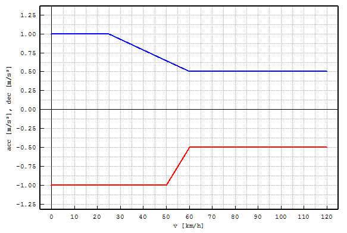

The graph shows the acceleration and deceleration limits depending on the current vehicle speed.

## Modal Results (.vmod)

Modal results are only created if enabled in the Options tab. One file is created for each calculation and stored in the same directory as the .vecto file.

In VECTO 3 the structure of the modal data output has been revised and re-structured. Basically for every powertrain component the .vmod file contains the power at the input shaft and the individual power losses for every component. For the engine the power, torque and engine speed at the output shaft is given along with the internal power and torque used for computing the fuel consumption. See Powertrain and Components Structure for schematics how the powertrain looks like and which positions in the powertrain the values represent.

Every line in the .vmod file represents the simulation interval from time - dt/2 to time + dt/2. All values represent the average power/torque/angular velocity during this simulation interval. If a certain power value can be described as function of the vehicle’s acceleration the average power is calculated by $P_{avg} = \frac{1}{simulation interval} \int{P(t) dt}$.

**Note:** Columns for the torque converter operating point represent the torque/angular speed at the end of the simulation interval!

### Quantities:

The following table lists the columns in the .vmod file:

**Note:** For dual-fuel vehicles the fuel consumption columns are present for each fuel (e.g., FC-Map_Diesel CI, FC-Map_NG CI).

| **Name** | **Unit** | **Component** | **Description** |
| --- | --- | --- | --- |
| time | [s] | DrivingCycle | Absolute time. Timestamp at the middle of the current simulation interval [time - dt/2, time + dt/2] |
| dt | [s] | DrivingCycle | Length of the current simulation interval |
| dist | [m] | DrivingCycle | Distance the vehicle traveled at the end of the current simulation interval |
| v_act | [km/h] | Vehicle | Average vehicle speed in the current simulation interval |
| v_targ | [km/h] | DrivingCycle | Target speed |
| acc | [m/s^2] | Driver | Vehicle’s acceleration, constant during the current simulation interval |
| grad | [%] | DrivingCycle | Road gradient |
| Gear | [-] | Transmission | Gear. “0” = clutch opened / neutral |
| TC locked | 0/1 | TorqueConverter | For AT-Gearboxes: if the torque converter is locked or not |
| n_ice_avg | [1/min] | CombustionEngine | Average engine speed in the current simulation interval. Used for interpolation of the engine’s fuel consumption |
| T_ice_fcmap | [Nm] | CombustionEngine | Engine torque used for interpolation of the engine’s fuel consumption. T_eng_fcmap is the sum of torque demand on the output shaft, torque demand of the auxiliaries , and engine’s inertia torque |
| Tq_full | [Nm] | CombustionEngine | Engine’s transient maximum torque (see transient full load) |
| Tq_drag | [Nm] | CombustionEngine | Engine’s drag torque, interpolated from the full-load curve |
| P_ice_fcmap | [kW] | CombustionEngine | Total power the engine has to provide, computed from n_eng_avg and T_eng_fcmap |
| P_ice_full | [kW] | CombustionEngine | Engine’s transient maximum power (see transient full load) |
| P_ice_full_stat | [kW] | CombustionEngine | Engine’s stationary maximum power |
| P_ice_drag | [kW] | CombustionEngine | Engine’s drag power |
| P_ice_inertia | [kW] | CombustionEngine | Power loss/gain due to the engine’s inertia |
| P_ice_out | [kW] | CombustionEngine | Power provided at the engine’s output shaft |
| P_REESS_T | [kW] | REESS | Electric power provided at the battery’s connector |
| P_REESS_int | [kW] | REESS | Internal battery power |
| P_REESS_loss | [kW] | REESS | Losses of the battery due to its internal resistance. |
| P_REESS_charge_max | [kW] | REESS | Maximum power the battery can be charged with |
| P_REESS_discharge_max | [kW] | REESS | Maximum power the battery can provide |
| REESS SOC | [%] | REESS | The battery’s current state of charge |
| U_REESS_T | [V] | REESS | Voltage at the battery’s connector |
| U_0_REESS | [V] | REESS | Battery’s internal voltage |
| I_REESS | [A] | REESS | Current charging/discharging the battery. |
| i_<POS>-em | [-] | ElectricMachine | Ratio between drivetrain and electric motor shaft |
| P_<POS>_out | [kW] | ElectricMachine | Power at the electric machine’s output shaft (drivetrain) |

[output cut: 99 more lines]

**Note:** The fuel name is only added to the fuel-consumption signals in case of dual-fuel engines.

P_eng_FCmap = T_eng_fcmap * n_eng_avg

P_eng_fcmap = P_eng_out + P_AUX + P_eng_inertia ( + P_PTO_Transm + P_PTO_Consumer ) = P_loss_total + P_AUX + P_eng_inertia

P_loss_total = P_clutch_loss + P_gbx_loss + P_ret_loss + P_gbx_inertia + P_angle_loss + P_axle_loss + P_brake_loss + P_wheel_inertia + P_air + P_roll + P_grad + P_veh_inertia (+ P_PTOconsumer + P_PTO_transm)

P_trac = P_veh_inertia + P_roll + P_air + P_slope

**Driving Action:**

| DrivingAction | Value |
| --- | --- |
| Halt | 0 |
| Roll | 2 |
| Coast | 4 |
| Accelerate | 6 |
| Brake | -5 |

## Summary Results (.vsum)

The .vsum file includes total / average results for each calculation run in one execution (ie. click of START Button). The file is located in the directory of the fist run .vecto file.

### Quantities:

**Note:** For dual-fuel vehicles the fuel consumption columns are present for each fuel (e.g., FC-Map_Diesel CI, FC-Map_NG CI).

| Name | Unit | Description |
| --- | --- | --- |
| Job | [-] | Job number in the format “X-Y” (with X as filenumber, and Y as cycle number) |
| Input File | [-] | Name of the input job file (.vecto) |
| Cycle | [-] | Name of the cycle file (or cycle name in declaration mode) |
| Status | [-] | The result status of the run (Success, Aborted) |
| Mass | [kg] | Vehicle mass (**Corrected Actual Curb Mass Vehicle** + **Curb Mass Extra Trailer/Body**, see Vehicle Editor) |
| Loading | [kg] | Vehicle loading (see Vehicle Editor) |
| Cargo Volume | [m^3] | Vehicle cargo volume (Declaration Mode only!) |
| time | [s] | Total simulation time |
| distance | [km] | Total traveled distance |
| speed | [km/h] | Average vehicle speed |
| altitudeDelta | [m] | Altitude difference between start and end of cycle |
| FC-Map<_FuelName> | [g/h], [g/km] | Average fuel consumption before all corrections, interpolated from Fuel Map, based on torque and engine speed. *Note:* The fuel name is only stated in case of dual fuel engines. |
| FC-NCVc<_FuelName> | [g/h], [g/km] | Average fuel consumption after correcting for the net calorific value (Based on FC-Map from .vmod) |
| FC-WHTCc<_FuelName> | [g/h], [g/km] | Average fuel consumption after WHTC Correction (Based on FC-NCVc from .vmod) |
| FC-ESS<_FuelName> | [g/h], [g/km] | Average fuel consumption considering the ICE is not always off during ICE-off periods in the simulation. Considers all auxiliary demands during Off-phases taking into account the ESS utility factors |
| FC-ESS_Corr<_FuelName> | [g/h], [g/km] | Average fuel consumption including fuel consumption during engine-off periods corrected for energy demand during engine-off periods not accounted (FC-ESS_Corr = FC_WHTCc + FC_ESS) |
| FC-BusAux_PS_Corr<_FuelName> | [g/h], [g/km] | Average fuel consumption corrected for the excessive/missing energy for the smart pneumatic system, also corrected for the air demand according to the correct driving time. |
| FC-BusAux_ES_Corr<_FuelName> | [g/h], [g/km] | Average fuel consumption corrected for the excessive/missing energy for the smart electric system |
| FC-WHR_Corr<_FuelName> | [g/h], [g/km] | Average fuel consumption including fuel consumption deduction due to electric power generated by an electric WHR system (FC-WHR_Corr = FC-ESS - E_WHR_el / eta_alternator * k_vehline) |
| FC-SoC<_FuelName> | [g/h], [g/km] | Average fuel consumption to correct the REESS SoC so that the SoC at the end of the cycle matches the SoC at the beginning |
| FC-SoC_Corr<_FuelName> | [g/h], [g/km] | Average fuel consumption including the correction for the REESS SoC |
| FC-BusAux_AuxHeater<_FuelName> | [g/h], [g/km] | Average fuel consumption of the additional heater. In case of dual-fuel vehicles the aux heater is fueled with the primary fuel |
| FC-BusAux_AuxHeater_Corr<_FuelName> | [g/h], [g/km] | Average fuel consumption corrected for the aux heater fuel demand |
| FC-Final<_FuelName> | [g/h], [g/km], [l/100km], [l/100tkm], [l/100m^3km] | Final average fuel consumption after ALL corrections (FC-Final = FC-ESS_Corr). Fuel consumption for calculation of CO<sub>2</sub> value. If Loading = 0[kg] the column [l/100tkm] is left empty. |
| k_vehline | [g/kWh] | Slope of the regression line derived from all operating points P_wheel vs. FC_final_mod where P_wheel > 0 and FC_final_mod > 0 |
| k_engline | [g/kWh] | Slope of the regression line used for the fuel consumption correction |
| CO2 | [g/km], [g/tkm], [g/m^3km] | Average CO<sub>2</sub> emissions (based on FC-Final value). Output for [l/100tkm] is empty when Loading = 0[kg]. |
| REESS Start SoC | [%] | State of charge of the REESS at the beginning of the simulation run |
| REESS End SoC | [%] | State of charge pf the REESS at the end of the simulation run |
| ΔE_REESS | [kWh] | Delta energy stored in the REESS between start and end of the simulation run. Calculated from P_REESS_int. |

[output cut: 76 more lines]

**Note:** The fuel name is only added to the fuel consumption signals for vehicles with dual-fuel engines. In case single-fuel and dual-fuel vehicles are simulated in one simulation run, the fuel consumption for single-fuel vehicles is reported without the fuel name suffix while the fuel consumption of dual fuel vehicles contains the fuel name suffix!

*Energy Bilance*

To ensure the energy bilance of the vehicle, the following formulas are always ensured:

- E_fcmap_pos = E_fcmap_neg + E_powertrain_inertia + E_aux_xxx E_clutch_loss + E_tc_loss + E_gbx_loss + E_ret_loss + E_angle_loss + E_axl_loss + E_brake + E_vehicle_inertia + E_air + E_roll + E_grad + E_PTO_CONSUM + E_PTO_TRANSM
- E_fcmap_pos = P_fcmap_pos * time

*Hint: E_shift_loss is not taken into account here, because it is already included in E_gbx_loss.*

## Application Files

VECTO uses a numbers of files to save GUI settings and file lists. All files are text-based and can be changed outside of VECTO *if VECTO is not running*.

### Settings.json

This file is located in VECTO’s **config** folder. Here all parameters of the Settings Dialog are saved. The file uses the JSON format.

### Job / Cycle lists

The job and cycle lists in the Main Form are saved in the **joblist.txt** / **cyclelist.txt** files of the **config** folder.

Both files save the full file paths separated by line breaks. Additionally it is saved whether each file’s checkbox is checked or not. “?1” after a file path means the file is checked (otherwise “?0”). However, this information can be omitted in which case the file will be loaded in checked state.

### LOG.txt

The tabulator-separated log file saves all messages of the Main Form’s Message List and is located in VECTO’s program directory. The file is restarted whenever the Logfile Size Limit is reached.One backup is always stored as LOG_backup.txt.

## Fuel Cell System Mass Flow Map

The Fuel Cell System Mass Flow Map File (.vfcm) contains the fuel cell system mass flow map.

Contains entries for the fuel consumption in g/h depending on the power demand in kW

**Example:**

```
P_el_out [kW],  m_H2 [g/h]
30.0,           2002.0
60.0,           3003.0
105.0,          5436.5
150.0,          8662.5
195.0,          12199.7
255.0,          17017.0
300.0,          21450.0
```

## Fuel Cell System Input File

The fuel cell system file (.vfcc) contains the input data for a single fuel cell system

**Example:**

```
{
  "Header": {
    "CreatedBy": "",
    "Date": "2023-10-11T10:34:56.5007858Z",
    "AppVersion": "3",
    "FileVersion": 1
  },
  "Body": {
    "SavedInDeclMode": false,
    "Manufacturer": "Fuel Cell Manufacturer",
    "Model": "Generic Fuel Cell",
    "MinElectricPower": 30.0,
    "MaxElectricPower": 100.0,
    "MassFlowMap": "GenericFuelCellMassflowMap_300kW.vfcm"
  }
}
```

# Changelog

**VECTO v5.1.1 Official Release (10*02*2026)**

- Features
  - CodeEU n.a.: Added input (axle*number specific) validation for multiple*powertrain vehicles. (vecto/vecto!537)
  - CodeEU n.a.: PCC for multiple powertrains. (vecto/vecto!565)
- Bug Fixes
  - CodeEU n.a.: Modified xArchitecture element in reports to support multiple powertrains. (vecto/vecto!533)
  - CodeEU n.a.: Calculate TotalPropulsionPower for multiple*powertrain vehicles (vecto/vecto!534)
  - CodeEU n.a.: Improved error message when not finding primary vehicle missions (vecto/vecto!535)
  - CodeEU n.a.: Removed engine power from calculation of total propulsion for SHEV (vecto/vecto!536)
  - CodeEU n.a.: Added missing parameter to method that creates gearbox. (vecto/vecto!538)
  - CodeEU n.a.: Modified method signature to satisfy interface (vecto/vecto!539)
  - CodeEU n.a.: Re*enabled unit tests, that required battery input data. (vecto/vecto!540)
  - CodeEU n.a.: Added OVC info to tests’ vehicle input (vecto/vecto!541)
  - CodeEU n.a.: Ignore monitoring data when calculating job hash for reports (vecto/vecto!544)
  - CodeEU n.a.: hashing tests (vecto/vecto!545)
  - CodeEU n.a.: Save vehicle in job editor (vecto/vecto!546)
  - CodeEU n.a.: Remove xml comments before calculating hash (vecto/vecto!547)
  - CodeEU n.a.: Hashing Tool ignores comments when verifying XML content, and Monitoring… (vecto/vecto!551)
  - CodeEU n.a.: Null reference & sample job file (vecto/vecto!552)
  - CodeEU n.a.: Handle cycles that fail during setup of the follow*up run. (vecto/vecto!553)
  - CodeEU n.a.: Added pre*processing for APT*N gearboxes (vecto/vecto!554)
  - CodeEU n.a.: Overloaded equality operators in GearshiftPosition (vecto/vecto!556)
  - CodeEU #778, #785, #1029, #849: TC dryRun Response in Motoring conditions (vecto/vecto!561)
  - CodeEU #639, #644, #646, #647, #664, #665, #666, #667, #668, #669, #670, #691: Brake Overload management (vecto/vecto!560)
  - CodeEU #1281: Handled PCC pre*processing for IEPC single*speed gearbox (vecto/vecto!562)
  - CodeEU n.a.: Corrected EM ElectricPowerToBattery for multiple powertrains. (vecto/vecto!563)
  - CodeEU n.a.: Added missing dummy axlegear to E4 axle*powertrain (vecto/vecto!564)
  - CodeEU n.a.: Avoid null reference in TestPowertrain Gearboxes (vecto/vecto!566)
  - CodeEU #1242.: verification of reports with bad job hashes (incl. Monitoring Data) (vecto/vecto!568)
  - CodeEU #1246: Handle primary cycles with insufficient fuel cell power (vecto/vecto!569)
  - CodeEU #535, #536, #539, #541, #600, #604, #993, #689, #690: IHPC * add ignoreReason for clutch slipping (vecto/vecto!567)
  - CodeEU #1042, #1133, #1138, #1139, #1182, #1191, #1244, #1277: Brake Overload management when engaged (vecto/vecto!570)
  - CodeEU #1286: date parsing in fuel cell component hashing (vecto/vecto!572)
  - CodeEU #1254, #1255, #1258, #1282: Integrate RESS ovl/underload in EM response (vecto/vecto!571)
  - CodeEU n.a.: failing unit tests for shift strategies (vecto/vecto!573)
  - CodeEU #1254, #1255, #1258, #1282: Integrate RESS ovl/underload in EM response * corrected (vecto/vecto!574)
  - CodeEU n.a.: Handle InterUrban cycle setup fail in FCHV primary bus (vecto/vecto!575)
  - CodeEU n.a.: fuel cell input in multiple*powertrain vehicle file (vecto/vecto!576)
  - CodeEU #1242: Modified version*checking method to accept versions without build part (vecto/vecto!577)
- Refact
  - CodeEU n.a.: Modified IDataBus properties/methods to handle single & multiple powertrains. (vecto/vecto!542)
  - CodeEU n.a.: Renamed VectoRunData properties to indicate single powertrain (vecto/vecto!543)
  - CodeEU n.a.: Minor cleanup/refactoring to reduce build*time warnings. (vecto/vecto!548)
  - CodeEU n.a.: Cleaned up root folder (vecto/vecto!549)
  - CodeEU n.a.: Cleanup/refactoring to reduce build*time warnings* part II. (vecto/vecto!550)
  - CodeEU n.a.: Reduce compile*time warnings part III (vecto/vecto!555)
  - CodeEU n.a.: Eliminated compile*time warnings in VectoCoreTests. (vecto/vecto!557)
  - CodeEU n.a.: Reduce compile*time warnings in new Test projects. (vecto/vecto!558)
  - CodeEU n.a.: Minor refactoring (vecto/vecto!559)

## VECTO v5.0.8*RC (16*12*2025)

- Features
  - multiple powertrains completed and single bus. (vecto/vecto!516)
  - Single*gear IEPC in multiple powertrains (vecto/vecto!524)
- Bug Fixes
  - Vecto console references (vecto/vecto!507)
  - Completed bus input generation for v2.7 (vecto/vecto!508)
  - DefaultDriverStrategy - add accel action after gearshift + roll + brake if overload (vecto/vecto!510)
  - Add retarder losses to TC max torque request (vecto/vecto!511)
  - Rename constructor parameter to match factory method (vecto/vecto!512)
  - Propagate ‘allowDeprecated’ parameter for XMLReader classes through injection hierarchy (vecto/vecto!513)
  - Multiple powertrain FCHV bus execution (vecto/vecto!515)
  - vsum fields for Retarder, Axlegear for multiple powertrains. (vecto/vecto!517)
  - Increase max iteration in InterpolateSearch (vecto/vecto!514)
  - use of battery SoC limits (input vs default) (vecto/vecto!519)
  - Create fuel cell in testpowertrain (required in shift strategy) (vecto/vecto!520)
  - Added missing function to DummyRunNinjectModule (vecto/vecto!521)
  - Calculation of axlegear efficiency for P4 vehicles: in case of an P4, use EM*in to calculate axlegear efficiency instead of Brake*in (vecto/vecto!522)
  - Added multiple-powertrain sample jobs (vecto/vecto!525)
  - Avoid null reference in DeclarationData.cs (vecto/vecto!526)
  - bugs regarding multiple powertrains. (vecto/vecto!527)
  - Modified Torque Converter columns to handle multiple powertrains. (vecto/vecto!528)
  - OVC-HEV mode for FCHV vehicles, null reference in fuel cells. (vecto/vecto!529)
  - Don’t allow unsupported variations of multiple powertrain vehicles. (vecto/vecto!530)
  - Enable unsupported vehicles in development mode (vecto/vecto!531)
- Refactor
  - Refactored multiple powertrains builder methods (vecto/vecto!509)
  - Reduced build-time warnings (vecto/vecto!518)
  - Project vecto sw3/task 2/unit tests amdm3 (vecto/vecto!460)

**VECTO v5.0.7 Official Release (14-10-2025)**

- Bug Fixes
  - CodeEU n.a.: Release notes link in GUI dialog (vecto/vecto!480)
  - CodeEU n.a.: Battery only mode for IHPC (vecto/vecto!481)
  - CodeEU #1180, #1183: Add System.Data.SqlClient to VECTO.vbproj (vecto/vecto!482)
  - CodeEU #1188: Treat ‘not applicable’ as ‘none’ in HeatPumpTypeDriverCompartmentType (vecto/vecto!483)
  - CodeEU #1189: Correct parsing of fuel cell in interim file (vecto/vecto!484)
  - CodeEU #1185: Proper mapping for ADC loss-map in XML (vecto/vecto!485)
  - CodeEU #1190, #1193: Improved error message for missing battery SoC bounds (vecto/vecto!486)
  - CodeEU n.a.: VETO main version in dialogs (vecto/vecto!488)
  - CodeEU n.a.: Corrected XSD dynamic charging types (vecto/vecto!491)
  - CodeEU #1184: Introduce new mod data postprocessing for BO-HEV (vecto/vecto!489)
  - CodeEU n.a.: Copy monitoring data from input (for completed vehicles) (vecto/vecto!494)
  - CodeEU n.a.: Generic vehicles engineering mode VTP files (vecto/vecto!492)
  - CodeEU #1195: Surround post-mortem analysis with try/catch block (vecto/vecto!495)
  - CodeEU #1181: Iepc gearshift (vecto/vecto!487)
  - CodeEU n.a.: Iepc gearshift torque reserve (post MR !487) (vecto/vecto!496)
  - CodeEU #1196: Corrected name for Tyre in VIF (vecto/vecto!497)
  - CodeEU n.a.: Corrected json sample file (vecto/vecto!498)
  - CodeEU n.a.: Added missing bindings for mod-data post processing (vecto/vecto!499)
  - CodeEU n.a.: Allow VTP with v2.4 vehicles. (vecto/vecto!503)
  - CodeEU n.a.: Updated some sample vehicles to v2.7 (vecto/vecto!504)
- Refact
  - CodeEU n.a.: Remove redundant code (vecto/vecto!493)

**VECTO v5.0.6-RC (22-09-2025)**

- Features
  - CodeEU n.a.: Update jobs in Generic Vehicles to version v2.7 (vecto/vecto!453)
  - CodeEU n.a.: Disable v2.4 jobs (vecto/vecto!458)
  - CodeEU #1140: Update multistep GUI to work with new XSDs (vecto/vecto!469)
  - CodeEU n.a.: Multiple axles partial implementation (vecto/vecto!471)
- Bug Fixes
  - CodeEU n.a.: Fix FCHV unit tests (vecto/vecto!448)
  - CodeEU n.a.: XMLConversionTool bug fixes, more test cases, refactoring (vecto/vecto!452)
  - CodeEU n.a.: Bug fixes for FCHV bus (vecto/vecto!454)
  - CodeEU #1147: Made FuelCell Minpower, Maxpower optional (vecto/vecto!456)
  - CodeEU n.a.: Engine-only simulation (vecto/vecto!457)
  - CodeEU n.a.: EM data in PHEV rundata creation (vecto/vecto!459)
  - CodeEU #1164: Lifetime ranges in reports for PEV, HEV-OVC. (vecto/vecto!461)
  - CodeEU n.a.: Work-around in ranges to make tests succeed (vecto/vecto!462)
  - CodeEU #1163: Respect job’s battery SoC limits (vecto/vecto!463)
  - CodeEU #870, #871, #924: Extend Accelerate condition after xEV Overload (vecto/vecto!466)
  - CodeEU n.a.: VTP generic vehicles (vecto/vecto!465)
  - CodeEU n.a.: Extend Accelerate condition after xEV Overload
  - CodeEU n.a.: Changed v2.6 XSD to allow DeltaCdxA_declared and DeltaTransferredCdxA value: zero (vecto/vecto!472)
  - CodeEU n.a.: Avoid cyclic refs from !473 (vecto/vecto!475)
  - CodeEU #1167: Added WheelEnd info to MRF (vecto/vecto!476)
  - CodeEU n.a.: Angledrive mod data, and PWheel axlegear efficiency (vecto/vecto!477)
  - CodeEU n.a.: Disable engineering mode for multiple powertrains (vecto/vecto!478)
  - CodeEU n.a.: VectoException using reference (vecto/vecto!479)
- Refact
  - CodeEU n.a.: FCHV iterative run strategy (vecto/vecto!449)
  - CodeEU n.a.: Update VECTO to NET 8 (vecto/vecto!467)
  - CodeEU n.a.: Old .NET references (vecto/vecto!468)
  - CodeEU n.a.: MultistepTool deprecated views (vecto/vecto!470)
  - CodeEU n.a.: Remove unnecessary usings and nugets (vecto/vecto!473)

**VECTO v5.0.4-DEV (25-08-2025)**

- Features
  - CodeEU n.a.: 3rd amendment reports for buses (vecto/vecto!421)
  - CodeEU n.a.: V1.0 reports for multiple powertrain lorries (vecto/vecto!395)
  - CodeEU n.a.: Add Diesel B100 CI fuel (vecto/vecto!399)
  - CodeEU n.a.: MRF and Monitoring report for multiple-powertrain primary buses (vecto/vecto!410)
  - CodeEU n.a.: battery only mode for P2 (vecto/vecto!425)
  - CodeEU n.a.: Run simulation for H2-ICE bus (primary + completed) (vecto/vecto!432)
  - CodeEU n.a.: FCHV bus simulation, primary & completed (vecto/vecto!433)
  - CodeEU n.a.: Single-bus mode for FCHV (vecto/vecto!435)
  - CodeEU n.a.: Enable all v2.7 vehicles (vecto/vecto!436)
  - CodeEU #1061: VTP input and formulas for buses and trucks (vecto/vecto!424)
- Bug Fixes
  - CodeEU #1058: Exception when getting MaxWindowsSize (vecto/vecto!422)
  - CodeEU #1096: For FCHV, APT-S/P gearboxes simulated as APT-N. (vecto/vecto!423)
  - CodeEU #1043: Ovc s-hev cs cd (vecto/vecto!420)
  - CodeEU n.a.: Convert property Type to Architecture in axle powertrains (vecto/vecto!393)
  - CodeEU n.a.: 3 job types for multiple powertrains (vecto/vecto!394)
  - CodeEU n.a.: Removed NgTankSystem from Multiple_SHEV primary bus (vecto/vecto!398)
  - CodeEU n.a.: Remove Retarder component from X4 architectures (vecto/vecto!400)
  - CodeEU n.a.: Use multiple factory methods for Retarder and Angledrive data providers (vecto/vecto!406)
  - CodeEU n.a.: Added FCHV missing gearbox bindings (vecto/vecto!427)
  - CodeEU n.a.: Airdrag element in VIF report. (vecto/vecto!430)
  - CodeEU n.a.: Do not require SoC limits for HV non-OVC (vecto/vecto!431)
  - CodeEU n.a.: B100 density to 890 kg/m3 (vecto/vecto!411)
  - CodeEU n.a.: Run old VIFs with v2.7 Completed vehicles (vecto/vecto!434)
  - CodeEU #1065: 1065 vehicle co2 group (vecto/vecto!428)
  - CodeEU #1066: DoCoast - add drive condition for overload (vecto/vecto!426)
  - CodeEU n.a.: Generic retarder and failing tests (vecto/vecto!437)
  - CodeEU #1109: IEPC data adaptation (vecto/vecto!438)
  - CodeEU n.a.: IHPC VECTO run data (vecto/vecto!439)
  - CodeEU n.a.: FCHV IEPC rundata gearbox creation (vecto/vecto!440)
  - CodeEU n.a.: Generic vehicles that failed to run (vecto/vecto!441)
  - CodeEU n.a.: WHRCharger creation (vecto/vecto!442)
  - CodeEU n.a.: Update wheelEnd sample (vecto/vecto!443)
  - CodeEU n.a.: FCHV files in engineering mode (vecto/vecto!444)
  - CodeEU n.a.: Initialize MaxChargingPower from static data if not available in input (vecto/vecto!445)
  - CodeEU n.a.: FCHV battery and CD and CS runs (vecto/vecto!446)
- Refactor
  - CodeEU n.a.: Merge refactoring branch (vecto/vecto!419)
  - CodeEU n.a.: Merging refactorings from SW3 project to (vecto/vecto!396)

**VECTO v5.0.3 Official Release (08-07-2025)**

- Bug Fixes
  - CodeEU n.a.: Avoid em conditioning calculation for non-FCHV (vecto/vecto!416)
  - CodeEU n.a.: Safe conditioning data lookup (vecto/vecto!417)

**VECTO v5.0.1 Official Release (03-07-2025)**

- Bug Fixes
  - CodeEU n.a.: FCHV engineering run (vecto/vecto!391)
  - CodeEU n.a.: H2 check in bus job (vecto/vecto!392)
  - CodeEU n.a.: Auxiliaries REESS connection (vecto/vecto!397)
  - CodeEU n.a.: Read PowerOutputConsumptionMap as kW (vecto/vecto!401)
  - CodeEU n.a.: Select pruned missions for FCHV primary bus (vecto/vecto!403)
  - CodeEU n.a.: Use angledrive in lorries’ gearshift data creation (vecto/vecto!404)
  - CodeEU n.a.: Remove wrong bus angledrive restrictions (vecto/vecto!405)
  - CodeEU #1058: Decl GUI error message when FCHV in eng mode (vecto/vecto!407)
  - CodeEU n.a.: Set NgTankSystem default for primary buses (vecto/vecto!408)
  - CodeEU n.a.: FCHV F-IEPC simulation runs! (vecto/vecto!409)
  - CodeEU #1047: Operational range for group 10 vehicle weights (vecto/vecto!402)
  - CodeEU #1045: Ovc fc weighting to correspond to CO2 computation (vecto/vecto!413)
  - CodeEU #848: 3s Buffer compute max EM PLoss for FL OPs (vecto/vecto!412)
  - CodeEU #1067: Conditioning power demand for FCHVs (vecto/vecto!414)

**VECTO v5.0.0-RC (05-06-2025)**

- Features
  - CodeEU n.a.: Readers for v2.7 vehicle XSD, and support for fuel cell vehicles. (vecto/vecto!341)
  - CodeEU n.a.: Read monitoring data from job (vecto/vecto!345)
  - CodeEU #1002: 3rd amendment mrf cif xml schemas (vecto/vecto!340)
  - CodeEU n.a.: MRF v1.0 vehicle (lorries and FCHV primary buses) writers (vecto/vecto!354)
  - CodeEU n.a.: CIF v1.0 vehicle part (v2.4 vehicles and v2.7 lorries) (vecto/vecto!355)
  - CodeEU n.a.: Use monitoring data from job to write report (vecto/vecto!360)
  - CodeEU n.a.: In motion charging postprocessing (vecto/vecto!344)
  - CodeEU n.a.: Disable (for RC & official) v27 vehicles except H2-ICE & FCHV lorries (vecto/vecto!375)
  - CodeEU n.a.: Readers for v2.7 buses, improved reader tests. (vecto/vecto!382)
  - CodeEU n.a.: HEV - Get Best dSOC in vsum (vecto/vecto!383)
  - CodeEU 968: Forbid AT upshift for reduced dt before brake (vecto/vecto!381)
  - CodeEU n.a.: New (v2.7) XSD for vehicles (vecto/vecto!334)
  - CodeEU n.a.: Partial implementation for new vehicle battery (vecto/vecto!337)
  - CodeEU n.a.: EM-IEPC Thermal Derating - Tq_max and Buffer Mods - Post VECTO-4.3.4 Feed-Back (vecto/vecto!378)
- Bug Fixes
  - CodeEU n.a.: Non-https link in manual (vecto/vecto!339)
  - CodeEU n.a.: V2.7 reader & XSD (vecto/vecto!342)
  - CodeEU n.a.: Updated XSLT file and hashing code for new vehicles and components. (vecto/vecto!338)
  - CodeEU #1007: Lock StoredResults list before accessing it to avoid race condition (vecto/vecto!343)
  - CodeEU n.a.: V27 vehicle issues (vecto/vecto!346)
  - CodeEU n.a.: 882 merge artifacts (vecto/vecto!347)
  - CodeEU n.a.: FCHV angledrive input (vecto/vecto!348)
  - CodeEU n.a.: Modify schema so that results can be written compatible with results for 2nd amendment: (vecto/vecto!349)
  - CodeEU n.a.: Restore deleted code in monitoring report (vecto/vecto!350)
  - CodeEU n.a.: Typo in MRF Inject module (vecto/vecto!351)
  - CodeEU n.a.: Proper namespace for VIF IEPC sub-element (vecto/vecto!352)
  - CodeEU n.a.: Mockup tests run successfully (vecto/vecto!353)
  - CodeEU #1002: Correcting errors in XML schema (and sample files): no engine output in… (vecto/vecto!356)
  - CodeEU n.a.: Bugfixes/updates for the Monitoring report and testing via the MockupTests. (vecto/vecto!357)
  - CodeEU n.a.: Replace U+2013 by regular dashes (vecto/vecto!359)
  - CodeEU n.a.: Added missing IMC testdata (vecto/vecto!361)
  - CodeEU n.a.: Retarder compulsory in all MRF vehicle components. (vecto/vecto!362)
  - CodeEU n.a.: Add further condition to decide which results to write in case the input data is a Multistep bus (vecto/vecto!363)
  - CodeEU n.a.: Check Articulated in json vehicle (vecto/vecto!365)
  - CodeEU n.a.: Segment in Bus AirDrag data creation (vecto/vecto!364)
  - CodeEU n.a.: FCHV pre-run execution (vecto/vecto!366)
  - CodeEU n.a.: Write ZeroCO2EmissionsRange and HydrogenRange to H2-ICE reports. (vecto/vecto!367)
  - CodeEU n.a.: Remove wrong angledrive restrictions (vecto/vecto!369)
  - CodeEU n.a.: Set vectorundata in completed bus results, (vecto/vecto!368)
  - CodeEU n.a.: Simulate OVC for FCHVs (vecto/vecto!370)
  - CodeEU n.a.: FCHV H2 range in reports (vecto/vecto!371)
  - CodeEU n.a.: Architecture in some MRF v1.0 tests (vecto/vecto!372)
  - CodeEU n.a.: H2 properties check in exempted vehicle input (vecto/vecto!373)
  - CodeEU n.a.: FCHV input classes inheritance (vecto/vecto!374)
  - CodeEU n.a.: Standard values enum entry for v2.6 (vecto/vecto!376)
  - CodeEU n.a.: Add Driving Actions for IEPC gearshift (vecto/vecto!377)
  - CodeEU n.a.: Of v2.7, allow only IMC, H2-ICE conventional, FCHV Lorries (vecto/vecto!384)
  - CodeEU n.a.: Disable reading data from external csv (vecto/vecto!385)
  - CodeEU n.a.: OVC results (vecto/vecto!387)
  - CodeEU n.a.: Ignore FCHV pre-run in best deltaSoC calculation (vecto/vecto!388)
  - CodeEU 972: Take battery limit into account for EM overload - REESS Empty (vecto/vecto!380)
  - CodeEU 994: ReEngage1C tolerance in AT (vecto/vecto!379)
  - CodeEU 886, 888, 889: Add Driving Actions for IEPC gearshift (vecto/vecto!377)
  - CodeEU n.a.: Updated Monitoring Report XSD (FCHV, Multiple powertrains) (vecto/vecto!335)
- Drop
  - CodeEU n.a.: MaxChargingPower requirement for OVC in v2.7 (vecto/vecto!358)

**VECTO 0.11.4-DEV (02.04.2025)**

- Features
  - CodeEU #855: IEPC with multiple load curves (!321)
  - H2 ICE vehicles in declaration mode (!325)
- Fixes
  - Add max-windows-size to fuel cell (!312)
  - Electric system power demand compensation for FCS (!313)
  - Add error message for unknown completed vehicle missions (!330)
  - Segment lookup method (!331)
  - FullLoadCurves proper initialization (!332)
  - Manage ‘GetTruckSegment’ exception behavior (!333)

- Bug Fixes
  - CodeEU #950: Check if XML element is signed (#950) (vecto/vecto!314)
  - CodeEU #954: NgTankSystem optional for HEV lorries MRF XSD (vecto/vecto!315)
  - fix: monitoring report for dual fuel vehicles (vecto/vecto!318)
  - fix: secure XML loading against external entity injection (vecto/vecto!319)
  - fix: correct interim supercap reader type (vecto/vecto!320)
  - fix: parameter IDs for XSDs v2.3 and v2.6 (vecto/vecto!322)
- Documentation
  - CodeEU n.a.: Update XSD parameter IDs documentation (vecto/vecto!327)

**VECTO v4.3.3 Official Release (03-03-2025)**

- Bug Fixes
  - CodeEU #950: Check if XML element is signed (#950) (vecto/vecto!314)
  - CodeEU #954: NgTankSystem optional for HEV lorries MRF XSD (vecto/vecto!315)
  - fix: monitoring report for dual fuel vehicles (vecto/vecto!318)
  - fix: secure XML loading against external entity injection (vecto/vecto!319)
  - fix: correct interim supercap reader type (vecto/vecto!320)
  - fix: parameter IDs for XSDs v2.3 and v2.6 (vecto/vecto!322)

**VECTO v4.3.2-RC (06-02-2025)**

- Features
  - CodeEU #872: New battery and supercap readers (vecto/vecto!309)
- Bug Fixes
  - CodeEU #861, #832, #880: ATShiftStrategyOptimized - No UpshiftFomL if not locked (vecto/vecto!301)
  - CodeEU #883: Forbid downshift to locked gear in APT-S if it generates direct upshift condition (vecto/vecto!307)
  - CodeEU #890: Add condition to write BusAuxiliaries output data in vsum (vecto/vecto!306)
  - Allow old XMLs for battery and supercap in development only (vecto/vecto!311)
  - Correct binding for supercap input data class; use correct xml data type in xml component reader for supercap (vecto/vecto!310)

**VECTO v4.2.7 Official Release (09-01-2025)**

- Bug Fixes
  - Track release_notes.md for release
  - CodeEU #858: Convert steering pump tech (vecto/vecto!303)
  - Converter Tool: ngTankSystem for dual fuel (vecto/vecto!304)
  - CodeEU #836: Restrictions on IEPC gear and MaxTorqueCurve XSD attributes (vecto/vecto!302)

**VECTO v4.2.6-RC (06-12-2024)**

- Features
  - Support Gitlab issue pattern (vecto/vecto!272)
  - CodeEU #854: Verify primary bus VIF hash against Job (vecto/vecto!295)
  - CodeEU #833, #834, #835, #836, #837: Add 3rd amendment XSD definitions (vecto/vecto!291)
  - CodeEU #838: Include Engine into v2.6 (vecto/vecto!297)
- Bug Fixes
  - Homogenize versions across tools (vecto/vecto!270)
  - CodeEU #807: Produce same data from ADC loss map (#807) (vecto/vecto!278)
  - Authors and readme metadata content (vecto/vecto!277)
  - CodeEU #809: Writing engine information in MRF (#809) (vecto/vecto!275)
  - CodeEU #842, #840, #841, #839, #798: Driver model: in case of an APT vehicle where the driving action is Brake… (vecto/vecto!287)
  - CodeEU #812, #788: Conversion of doubles for SI (vecto/vecto!283)
  - CodeEU #750, #758, #769, #816, #821, #829: Avoid wrong upshift and downshift for light SMT vehicles (vecto/vecto!290)
  - CodeEU #844, #705, #530: During a coasting action (look-ahead coasting) a gear hunting occurs in the… (vecto/vecto!289)
  - CodeEU #784: Override DoWriteModalResult for VTP (vecto/vecto!294)
  - CodeEU #495, #642, #739: Add SMT downshift condition - DroppedSpd>DisengSpd (vecto/vecto!293)

**VECTO v4.2.5 Official Release (02-10-2024)**

- Hot Fixes
  - Missing Build.props DefineConstants (!268)
  - Version 4th number read from Build.props (!269)

**VECTO v4.2.3 Official Release (01-10-2024)**

- Enhancements
  - CodeEU #799: Adapt VECTO for the new CI updates (!263)
- Bug Fixes
  - CodeEU #794: Added missing monitoring report file (!265)
  - CodeEU #780: Update weights for bus subgroups (!264)

**VECTO-4.2.2-RC**

**Build 3539 (2024-09-09)**

- Bugfixes
  - CodeEU-710: Hashing tool check fail with VECTO version 3330
  - CodeEU-711: Hashing tool check fail with VECTO 4.1.3.3415
  - CodeEU-712: VECTO VTP error
  - CodeEU-754: “Failed to find operating point”; “Failed to find mechanic power for given electric power” in E2 vehicle
  - CodeEU-727: Failure in simulating HEV in different VECTO versions
  - CodeEU-749: Double summary for electric vehicles
  - CodeEU-542: IVECO confidential : BUG REPORT : CRW LE T7D VOITH NXT 5.63
  - CodeEU-663: IHPC: Failed to find operating point
  - CodeEU-634: Article 10(2) issue - VIN YS2G6X20002202570
  - CodeEU-671: IHPC: simulation abort due to unexpected response

**VECTO-4.2.1**

**Build 3469 (2024-07-01)**

- Features
  - CodeEU-726: Build an XML converter tool for older VECTO jobs
- Bugfixes
  - CodeEU-719: the six new tyre dimensions from line 126 onwards to the latest “wheels.csv” file in the VECTO repository
  - CodeEU-717: VECTO-4.2.0.3448-RC - Buses AMT Gearbox Type with 1% higher C02 in primary results
  - CodeEU-724: Error in Primary Bus Simulation: Object reference not set to an instance of an object
  - CodeEU-716: VECTO-4.2.0.3448-RC - Buses Result Summary section missing in RLST_Customer.xml
  - CodeEU-694: Primary and Completed heavybus FCV article 9 exempted hashcode mismatch.
  - CodeEU-735: SMT strategy different between engineering and declaration mode
  - CodeEU-736: Existing customer reports (CIF) fail validation
  - CodeEU-737: Missing data from XML report

**VECTO-4.2.0-RC**

**Build 3448 (2024-06-10)**

- Features
  - CodeEU-697: Re-evaluate subgroup allocations for Long Haul
  - CodeEU-696: Double summary in CIF for vocationals and non vocational missions.
  - CodeEU-698: Incorporate missions RD, LH and EMS to class 16 vehicles
  - CodeEU-676: Feature: Implement monitoring report
- Bugfixes
  - CodeEU-471: VectoSimulationException: VF640J869RB022573
  - CodeEU-462: Article10-2-issue | Order-Nr 28206354 | HEV P1 Error Mercedes-Benz and Setra Hybrid Buses
  - CodeEU-326: Article10-2-issue | Order-Nr 28195581 | HEV P1 Error Mercedes-Benz and Setra Hybrid Buses
  - CodeEU-348: Article10-2-issue | Order-Nr 28204519 | HEV P1 Error Mercedes-Benz and Setra Hybrid Buses
  - CodeEU-457: Article10-2-issue | Order-Nr 28174000 | HEV P1 Error Mercedes-Benz and Setra Hybrid Buses
  - CodeEU-458: Article10-2-issue | Order-Nr 28186528 | HEV P1 Error Mercedes-Benz and Setra Hybrid Buses
  - CodeEU-459: Article10-2-issue | Order-Nr 28203057 | HEV P1 Error Mercedes-Benz and Setra Hybrid Buses
  - CodeEU-545: IVECO confidential : BUG REPORT : HEV-P1 : UW18m C9 VOITH NXT CRU 48V mild hybrid
  - CodeEU-346: Article10-2-issue | Order-Nr 28202338 | HEV P1 Error Mercedes-Benz and Setra Hybrid Buses
  - CodeEU-352: Article10-2-issue | Order-Nr 28202130 | HEV P1 Error Mercedes-Benz and Setra Hybrid Buses
  - CodeEU-394: Article10-2-issue | Order-Nr 28204065 | HEV P1 Error Mercedes-Benz and Setra Hybrid Buses
  - CodeEU-433: Article10-2-issue | Order-Nr 28192321 | HEV P1 Error Mercedes-Benz and Setra Hybrid Buses
  - CodeEU-451: Article10-2-issue | Order-Nr 28204280 | HEV P1 Error Mercedes-Benz and Setra Hybrid Buses
  - CodeEU-452: Article10-2-issue | Order-Nr 28197394 | HEV P1 Error Mercedes-Benz and Setra Hybrid Buses
  - CodeEU-453: Article10-2-issue | Order-Nr 28199435 | HEV P1 Error Mercedes-Benz and Setra Hybrid Buses
  - CodeEU-454: Article10-2-issue | Order-Nr 28206982 | HEV P1 Error Mercedes-Benz and Setra Hybrid Buses
  - CodeEU-655: Article10-2-issue | VECTO-4.0.3 | Order-Nr 28208126 | HEV P1 Error Mercedes-Benz and Setra Hybrid Buses
  - CodeEU-660: Retarder lossmap error in completed vehicle simulation
  - CodeEU-662: Generic retarder map speed range insufficient in some cases
  - CodeEU-648: Error in Multistep Tool PEV/P-HEV
  - CodeEU-618: PEV vehicles simulation error depending the time format
  - CodeEU-700: Factor Method Generic IHPC Powermap De-normaization bug
  - CodeEU-482: Article10-2-issue | Order-Nr 28203040 | HEV P1 Error Mercedes-Benz and Setra Hybrid Buses
  - CodeEU-514: Article10-2-issue | VECTO-4.0.3 | Order-Nr 28208051 | HEV P1 Error Mercedes-Benz and Setra Hybrid Buses
  - CodeEU-529: Article10-2-issue | VECTO-4.0.3 | Order-Nr 28199994 | HEV P1 Error Mercedes-Benz and Setra Hybrid Buses
  - CodeEU-544: IVECO confidential : BUG REPORT : HEV-P1 : CRW LE C9 VOITH NXT CRU 48V mild hybrid
  - CodeEU-552: Article10-2-issue | VECTO-4.0.3 | Order-Nr 28201759 | HEV P1 Error Mercedes-Benz and Setra Hybrid Buses
  - CodeEU-556: Article10-2-issue | VECTO-4.0.3 | Order-Nr 28208176 | HEV P1 Error Mercedes-Benz and Setra Hybrid Buses
  - CodeEU-557: Article10-2-issue | VECTO-4.0.3 | Order-Nr 28209751 | HEV P1 Error Mercedes-Benz and Setra Hybrid Buses
  - CodeEU-622: Article10-2-issue | VECTO-4.0.3 | Order-Nr 28210594 | HEV P1 Error Mercedes-Benz and Setra Hybrid Buses
  - CodeEU-632: Article10-2-issue | VECTO-4.0.3 | Order-Nr 28210591 | HEV P1 Error Mercedes-Benz and Setra Hybrid Buses
  - CodeEU-672: Article10-2-issue | VECTO-4.1.3 | Order-Nr 28208841 | HEV P1 Error Mercedes-Benz and Setra Hybrid Buses
  - CodeEU-673: Article10-2-issue | VECTO-4.1.3 | Order-Nr 28209179 | HEV P1 Error Mercedes-Benz and Setra Hybrid Buses
  - CodeEU-674: Article10-2-issue | VECTO-4.1.3 | Order-Nr 28211540 | HEV P1 Error Mercedes-Benz and Setra Hybrid Buses
  - CodeEU-678: Article10-2-issue | VECTO-4.1.3 | Order-Nr 28192673 | HEV P1 Error Mercedes-Benz and Setra Hybrid Buses
  - CodeEU-697: Article10-2-issue | VECTO-4.1.3 | Order-Nr 28209551 | HEV P1 Error Mercedes-Benz and Setra Hybrid Buses
  - CodeEU-685: Article10-2-issue | VECTO-4.1.3 | Order-Nr 28200286 | HEV P1 Error Mercedes-Benz and Setra Hybrid Buses
  - CodeEU-686: Article10-2-issue | VECTO-4.1.3 | Order-Nr 28201178 | HEV P1 Error Mercedes-Benz and Setra Hybrid Buses
  - CodeEU-687: Article10-2-issue | VECTO-4.1.3 | Order-Nr 28209679 | HEV P1 Error Mercedes-Benz and Setra Hybrid Buses
  - CodeEU-692: Article10-2-issue | VECTO-4.1.3 | Order-Nr 28209789 | HEV P1 Error Mercedes-Benz and Setra Hybrid Buses

**VECTO-4.1.3**

*Build 3415 (2024-05-08)*

- Hotfixes
  - CodeEU-638: Incorrect construction payloads for group 9 non-vocational vehicle

**VECTO-4.1.1**

*Build 3413 (2024-05-06)*

- Bugfixes
  - CodeEU-615: Multistep freezes after loading VIF chassis
  - CodeEU-616: Multistep tool freezes
  - CodeEU-619: restore wrong exempted techs in XSD for backwards compatibility
  - CodeEU-617: Results change depending the time format
  - CodeEU-635: Revert multiple summary in CIF

**VECTO-4.1.0-RC**

*Build 3392 (2024-04-15)*

- Features
  - CodeEU-577: Add missing mission profiles to vocational and non-vocational
- Bugfixes
  - CodeEU-331: Gear 1 DrivingActionAccelerate: Fail
  - CodeEU-367: Gear 1 DrivingActionAccelerate: Fail
  - CodeEU-372: ADT Error on Bus Category Primary Vehicle Simulation on VECTO
  - CodeEU-373: ADT Error on Bus Category Primary Vehicle Simulation on VECTO
  - CodeEU-374: ADT Error on Bus Category Primary Vehicle Simulation on VECTO
  - CodeEU-375: ADT Error on Bus Category Primary Vehicle Simulation on VECTO
  - CodeEU-393: Finished Run VEH-PrimaryBus_nonSmart Interurban _P32SD_ReferenceLoad with ERROR: 16
  - CodeEU-439: 615 (Interurban _P32DD_ReferenceLoad) - absTime: 7129.6359 [s], distance: 53875.9765 [m], dt: 0.6388 [s], v: 0.5098 [m/s], Gear: 1 | DrivingActionAccelerate: Failed
  - CodeEU-446: Finished Run VEH-PrimaryBus_nonSmart Interurban _P32SD_ReferenceLoad with ERROR: 16
  - CodeEU-449: Finished Run VEH-PrimaryBus_nonSmart Interurban _P32SD_ReferenceLoad with ERROR: 16
  - CodeEU-478: Finished Run VEH-PrimaryBus_nonSmart Urban _P31SD_ReferenceLoad with ERROR: 4 (Urban _P31SD_ReferenceLoad) - absTime: 8606.6241 [s], distance: 39112.5127 [m], dt: 1.1131 [s], v: 0.1833 [m/s], Gear: 1 | DrivingActionAccelerate: Failed to find operating poi
  - CodeEU-481: Finished Run VEH-PrimaryBus_nonSmart Urban _P31SD_ReferenceLoad with ERROR: 4 (Urban _P31SD_ReferenceLoad) - absTime: 8606.6241 [s], distance: 39112.5127 [m], dt: 1.1131 [s], v: 0.1833 [m/s], Gear: 1 |
  - CodeEU-488: Finished Run VEH-PrimaryBus_nonSmart Urban _P31SD_ReferenceLoad with ERROR: 4 (Urban _P31SD_ReferenceLoad) - absTime: 8606.6241 [s], distance: 39112.5127 [m], dt: 1.1131 [s], v: 0.1833 [m/s], Gear: 1 | DrivingActionAccelerate: Failed to find operating poi
  - CodeEU-494: Finished Run VEH-PrimaryBus_nonSmart Urban _P31SD_ReferenceLoad with ERROR: 26 (Urban _P31SD_ReferenceLoad) - absTime: 8606.6241 [s], distance: 39112.5127 [m], dt: 1.1131 [s], v: 0.1833 [m/s], Gear: 1 | DrivingActionAccelerate: Failed to fi
  - CodeEU-420: Finished Run VEH-PrimaryBus_nonSmart Interurban _P32SD_ReferenceLoad with ERROR: 16
  - CodeEU-573: Unhandled powertrain architecture Conventional Vehicle to calculate gradability
  - CodeEU-582: unhandled powertrain architecture ConventionalVehicle to calculate gradability, 11:44:36.63,
  - CodeEU-595: Inconsistency exempted vehicles “Fuel cell vehicle” vs. “FCV Article 9 exempted”
  - CodeEU-501: Help regarding VTP vdri format is not up to date in v4
  - CodeEU-594: inadequate validation for auxiliaries in completed vehicle XML
  - CodeEU-580: Potential error in XML schema v2.4 (exempted vehicles)
  - CodeEU-551: Article-10-2 XLRASF5E00G419905
  - CodeEU-547: Max ICE Off timespan for buses
  - CodeEU-583: Incorrect internal resistance for SuperCap used in factor method
  - CodeEU-571: Article10-2-issue | VECTO-4.0.3 | Order-Nr 28202896 | HEV P1 Error Mercedes-Benz and Setra Hybrid Buses
  - CodeEU-526: VTP calculation aborted on fuel consumption map
  - CodeEU-502: Error in VECTO calculation WMA10CZZ0RF022326
  - CodeEU-401: Electric steering system with conventional vehicle not according to 2017/2400
  - CodeEU-476: Setting Initial SoC in REESS editor leads to error
  - CodeEU-533: Question about heavy lorry_IEPC_Gb×4speed: Failed to generate electric power map - at least two negative entries are required
  - CodeEU-456: Clarification Documentation official Results
  - CodeEU-506: Article 10(2) issue - VIN YS2P6X200R2201285
  - CodeEU-507: Article 10(2) issue - VIN YS2P6X20005732399
  - CodeEU-508: Article 10(2) issue - VIN S2P6X20005734199
  - CodeEU-499: Object Reference not set Error
  - CodeEU-546: Problem with P181 (Cooling Fan Technology) for a conventional vehicle
  - CodeEU-516: Article10-2-issue | VECTO-4.0.3 | Order-Nr 28208044 | HEV P1 Error Mercedes-Benz and Setra Hybrid Buses
  - CodeEU-517: Article10-2-issue | VECTO-4.0.3 | Order-Nr 28208037 | HEV P1 Error Mercedes-Benz and Setra Hybrid Buses
  - CodeEU-519: Article10-2-issue | VECTO-4.0.3 | Order-Nr 10098181 | HEV P1 Error Mercedes-Benz and Setra Hybrid Buses
  - CodeEU-527: Article10-2-issue | VECTO-4.0.3 | Order-Nr 28196233 | HEV P1 Error Mercedes-Benz and Setra Hybrid Buses
  - CodeEU-528: Article10-2-issue | VECTO-4.0.3 | Order-Nr 28196652 | HEV P1 Error Mercedes-Benz and Setra Hybrid Buses
  - CodeEU-338: Eco-roll only, without engine stop, impact on CO2 emission
  - CodeEU-475: XML files loading in VTP Job not OK; No auxiliary data and torque curve visible, Job can’t be saved in VECTO 4.0.3.3330
  - CodeEU-610: VTP mode is broken due to changes in the Clutch component.

**VECTO-4.0.3**

*Build 3330 (2024-02-13)*

- Bugfixes
  - CodeEU-293: DistanceRun got an unexpected response
  - CodeEU-298: Object reference not set to an instance of an object
  - CodeEU-300: Full drive torque miscalculation
  - CodeEU-336: Feature: Hashing tool must validate the previous step data for multi-step jobs
  - CodeEU-337: Electric Citybus - ERROR with “31a-Specific” bus configuration
  - CodeEU-343: Cannot simulate Primary Vehicle using vectocmd.exe
  - CodeEU-387: VECTO sometimes fails to properly read Tyre data from primary vehicle xml
  - CodeEU-427: Vehicle speed resulting to exceeding max gearbox speed
  - CodeEU-428: Remove speed safety margin for gearbox re-engaging
  - CodeEU-438: Mismatch XML schema vs Regulation (exempted vehicles)
  - CodeEU-248: Bus P2 hybrid VECTO error in urban cycle
  - CodeEU-278: Simulation crash when writing fuel consumption results to reports
  - CodeEU-284: New error message and failed simulation obtained for P2 hybrid buses
  - CodeEU-285: PEV vehicle error in routine to write the results with new vecto version 4.0.2.3275
  - CodeEU-287: PEV_IEPC error message:“can only operate on SI Objects with the same unit”
  - CodeEU-289: VECTO Simulation Error for bus with validated input data

**VECTO-4.0.2**

*Build 3275 (2023-12-20)*

- Hotfix
  - CodeEU-273, CodeEU-274: Changes in the AMT shift strategy regarding idling speed caused simulation aborts
  - CodeEU-260: regression fix handling overload buffer

*Build 3273 (2023-12-18)*

- Bugfixes
  - CodeEU-94: DistanceRun got an unexpected response
  - CodeEU-153: DrivingActionAccelerate: Failed to find operating point after Overload
  - CodeEU-158: Urban RefLoad DrivingActionAccelerate: Failed to find operating point (IEPC Wheelhub 1 measured)
  - CodeEU-168: Vecto Declaration Simulation with P1-Hybrid shows multiple errors - Simulation Aborts!
  - CodeEU-191: Boosting limits HEV ovc are not working
  - CodeEU-202: EMS Standard Values: Continuous/Overload Torque 0 Nm
  - CodeEU-203: HybridStrategy error for IHPC type 1 hybrid lorry
  - CodeEU-206: VTP + PEMS test done by Renault Trucks France - VECTO tool errors most probably linked to automatic gearbox (with torque converter)
  - CodeEU-211: Hybrid P1 configurations with errors
  - CodeEU-215: MultiStep tool help
  - CodeEU-216: NrOfGears in CIF is 1 for IEPC no matter how many gears it has
  - CodeEU-220: Error manual transmission 2. gear
  - CodeEU-224: Issue with PEV complete vehicle simulation (Vecto MultiStage)
  - CodeEU-231: IVECO CONFIDENTIAL : hybrid buses completed simulation aborted
  - CodeEU-234: Error Conventional Lorry Gear: 1C DistanceRun got an unexpected response
  - CodeEU-235: Tyre error calculation buses “invalid xsi:type ‘TyreDataDeclarationType’”
  - CodeEU-238: Bus VIF files not valid in Multistep VECTO
  - CodeEU-243: Simulation aborted: Gear 5 Lossmap not sufficiant
  - CodeEU-244: Signature validation fails for old (prior to v4) Manufacturer reports
  - CodeEU-246: VTP report generation problems (failing to read some data from MRF)
  - CodeEU-249: Fix handling gear torque limits in case of IEPC WheelHub motor and only one side is measured
  - CodeEU-250: Maximum vehicle speed exceeded during pre-processing
  - CodeEU-253: Replace VTP HeavyBus in Generic Vehicles with VTP Truck
  - CodeEU-259: Inconsistent calculation of AverageRRC in CIF
  - CodeEU-260: Handling of overload buffer in case Continuous Torque is 0Nm
  - CodeEU-261: SuperCap internal resistance standard values correction
  - CodeEU-263: Determination of rated power for IEPCs for MRF and CIF
  - CodeEU-266: Fix Measured Speed Testcases

**VECTO-4.0.1**

*Build 3217 (2023-10-23) OFFICIAL RELEASE*

- Improvements
  - VTP mode: create zip archive for input and output files
- Bugfixes
  - bugfix in CIF for complete(d) buses - do not write PrimaryVehicleSubgroup element
  - fix hybrid strategy: power comparison
  - fix exempted vehicles do not work (error message that XML version is not supported)
  - bugfix in XML schema: remove wrong PS technology entry for lorries
  - bugfix for conditioning power demand for IHPC vehicles

**VECTO-4.0.0**

*Build 3211 (2023-10-16) OFFICIAL RELEASE*

- First official VECTO release for the 2nd amendment of Regulation (EU) 2017/2400
- Features
  - Declaration Mode simulation
    - xEV heavy lorries
    - Conventional medium lorries
    - xEV medium lorries
    - conventional buses (primary and complete(d))
    - xEV buses (primary and complete(d))
  - Dedicated user interface for simulating buses in declaration mode using the multistep tool
  - Updated XML reports (MRF, CIF, VIF)
  - Updated simulation output (.vsum, .vmod)
  - XML job files in version below 2.4 are no longer supported
    - XML component data is still supported in all XML versions
  - Dropped support for .NET Framework 4.5 (EOL 04/2022)
  - Engineering mode simulation of xEV vehicles

*Build 3078 (2023-06-06) RELEASE CANDIDATE*

- First fully functional tool version according to the provisions of the 2nd amendment of Regulation (EU) 2017/2400.
- Changes
  - Dropped support for .Net Framework 4.5 (EOL 04/2022)
  - Multi-target build. Supported .Net versions: .Net Framework 4.8, .Net 6.0
  - Implementation of Declaration-Mode for xEV-Lorries (see release notes)
  - Implementation of Declaration-Mode for xEV-Buses (see release notes)
  - New generic vehicles (XML)
- Known issues
  - Elements not yet implemented
    - Battery connectors / junction box not included  define and implement generic additional resistances (i.e. loss factors)
    - Technical elements as resulting from the revision of the CO2 Standards to be added
      - Sub-group allocation for the for the newly covered vehicle groups
      - Generation of weighted results for vocational vehicles
      - Anything related to ZEV definition?
  - Elements still under discussion
    - Medium lorries mission profile and payload weighting factors (equally weighted, only preliminary)
    - Multiple SOC level(s) for VECTO PEV simulation and respective weighting of results (?)

**VECTO-3.3.10**

*Build 2401 (2021-07-29) OFFICIAL RELEASE*

- Bugfixes (compared to 3.3.10.2373)
  - *No additional bugfixes*

*Build 2373 (2021-07-01) RELEASE CANDIDATE*

- Improvements
  - [VECTO-1421] – Added vehicle sub-group (CO2-standards to MRF and CIF)
  - [VECTO 1449] – Handling of exempted vehicles: See next slide for details
  - [VECTO-1404] – Corrected URL for CSS in MRF and CIF
- Bugfixes
  - [VECTO-1419] – Simulation abort in urban cycle: failed to find operating point on search braking power with TC gear
  - [VECTO-1439] – Bugfix handling duplicate entries in engine full-load curve when intersecting with max-torque of gearbox
  - [VECTO-1429] – error in XML schema 2.x for exempted vehicles – MaxNetPower1/2 are optional input parameters

*Handling of exempted vehicles*

- Axle configuration and sleeper cab are optional input parameters for exempted vehicles (XML schema 1.0 and 2.2.1).
  - OEMs are recommended to provide these parameters for exempted vehicles.
  - If the axle configuration is provided as input parameter, the MRF contains the vehicle group.
  - The sleeper cab input parameter is also part of the MRF if provided as input.
- Input parameters MaxNetPower1/2 are optional input parameters for all exempted vehicles.
  - If provided in the input these parameters are part of the MRF for all exempted vehicle types
  - It is recommended that those parameters are used to specify the rated power also for PEV (pure electric vehicles)

**VECTO-3.3.9**

*Build 2175 (2020-12-15) OFFICIAL RELEASE*

- Bugfixes (compared to 3.3.9.2147)
  - [VECTO-1374] - VECTO VTP error - regression update

*Build 2147 (2020-11-17) RELEASE CANDIDATE*

- Bugfixes
  - [VECTO-1331] - VTP Mode does not function for vehicles of group 3
  - [VECTO-1355] - VTP Simulation Abort
  - [VECTO-1356] - PTO Losses not considered in VTP simulation
  - [VECTO-1361] - Torque Converter in use for the First and Second Gear VTP file does not allow for this
  - [VECTO-1372] - Deviation of CdxA Input vs. Output for HDV16
  - [VECTO-1374] - VECTO VTP error
- Improvements
  - [VECTO-1360] - make unit tests execute in parallel

**VECTO-3.3.8**

*Build 2052 (2020-08-14) OFFICIAL RELEASE*

- Bugfixes (compared to 3.3.8.2024)
  - *No additional bugfixes*

*Build 2024 (2020-07-17) RELEASE CANDIDATE*

- Bugfixes
  - [VECTO-1288] - Simulation Abort UD RL
  - [VECTO-1327] - Simulation abort Construction RefLoad: unexpected response ResponseOverload
  - [VECTO-1266] - Gear 4 Loss-Map was extrapolated

**VECTO 3.3.7**

*Build 1964 (2020-05-18) OFFICIAL RELEASE*

- Bugfixes
  - [VECTO-1254] - Hashing method does not ignore certain XML attributes
  - [VECTO-1259] - Mission profile weighting factors for vehicles of group 16 are not correct

**VECTO 3.3.6**

*Build 1916 (2020-03-31) OFFICIAL RELEASE*

- Bugfixes
  - [VECTO-1250] - Error creating new gearbox file from scratch

*Build 1898 (2020-03-13) RELEASE CANDIDATE*

- Improvement
  - [VECTO-1239] - Adaptation of Mission Profile Weighting Factors
  - [VECTO-1241] - Engineering mode: Adding support for additional PTO activations
- Bugfixes
  - [VECTO-1243] - Bug in VTP mode for heavy lorries
  - [VECTO-1234] - urban cycle at reference load not running for bug when find braking operating point

**VECTO 3.3.5**

*Build 1812 (2019-12-18) OFFICIAL RELEASE*

- Bugfixes
  - [VECTO-1220] - Simulation Abort Urban Delivery RefLoad

*Build 1783 (2019-11-19) RELEASE CANDIDATE*

- Improvement
  - [VECTO-1194] - Handling input parameter ‘vocational’ for groups other than 4, 5, 9, 10
  - [VECTO-1147] - Updating declaration mode cycles values in user manual
  - [VECTO-1207] - run VECTO in 64bit mode by default
- Bugfixes
  - [VECTO-1074] - Vecto Calculation Aborts with Interpolation Error
  - [VECTO-1159] - Simulation Abort in UrbanDelivery LowLoading
  - [VECTO-1189] - Error in delaunay triangulation invariant violated
  - [VECTO-1209] - Unexpected Response Response Overload
  - [VECTO-1211] - Simulation Abort Urban Delivery Ref Load
  - [VECTO-1214] - Validation of input data fails when gearbox speed limits are applied

**VECTO 3.3.4**

*Build 1716 (2019-09-13) OFFICIAL RELEASE*

- Bugfixes
  - [VECTO-1074] - Vecto Calculation Aborts with Interpolation Error ([VECTO-1046])
  - [VECTO-1111] - Simulation Abort in Municipal Reference Load

*Build 1686 (2019-08-14) RELEASE CANDIDATE*

- Improvement
  - [VECTO-1042] - Add option to write results into a certain directory
  - [VECTO-1064] - add weighting factors for vehicle groups 1, 2, 3, 11, 12, 16
- Bugfixes
  - [VECTO-1030] - Exceeded max iterations when searching for operating point! Failed to find operating point!
  - [VECTO-1032] - Gear 5 LossMap data was extrapolated in Declaration Mode: range for loss map is not sufficient
  - [VECTO-1067] - Vair and Beta correction for Aerodynamics
  - [VECTO-1000] - Error Loss-Map extrapolation in Declaration Mode
  - [VECTO-1040] - Gear 6 LossMap data was extrapolated in Declaration Mode
  - [VECTO-1047] - Failed to find operating point on construction cycle, ref load, AT gearbox

**VECTO 3.3.3**

*Build 1639 (2019-06-27) OFFICIAL RELEASE*

- Bugfixes (compared to VECTO 3.3.3.1609-RC)
  - [VECTO-1003] - Vecto Error: Loss-Map extrapolation in declaration mode required (issue VECTO-991)
  - [VECTO-1006] - Failed to find torque converter operating point on UD cycle (issue VECTO-996)
  - [VECTO-1010] - Unexpected Response: ResponseOverload in UD cycle (issue VECTO-996)
  - [VECTO-1015] - XML Schema not correctly identified
  - [VECTO-1019] - Error opening job in case a file is missing
  - [VECTO-1020] - HashingTool Crashes
  - [VECTO-1021] - Invalid hash of job data

*Build 1609 (2019-05-29) RELEASE CANDIDATE*

- Improvement
  - [VECTO-916] - Adding new tyre sizes
  - [VECTO-946] - Refactoring XML reading
  - [VECTO-965] - Add input fields for ADAS into VECTO GUI
  - [VECTO-966] - Allow selecting Tank System for NG engines in GUI
  - [VECTO-932] - Consistency in NA values in the vsum file
- Bugfixes
  - [VECTO-954] - Failed to find operating point for braking power (Fix for Notification Art. 10(2) - [VECTO-952])
  - [VECTO-979] - VECTO Simulation abort with 8-speed MT transmission (Fix for Notification Art. 10(2) - [VECTO-978])
  - [VECTO-931] - AT error in VECTO version 3.3.2.1519
  - [VECTO-950] - Error when loading Engine Full-load curve
  - [VECTO-967] - Engine-Only mode: Engine Torque reported in .vmod does not match the provided cycle
  - [VECTO-980] - Error during simulation run

**VECTO 3.3.2**

*Build 1548 (2019-03-29) OFFICIAL RELEASE*

- Bugfixes
  - [VECTO-861] - 3.3.1: Torque converter not working correctly
  - [VECTO-904] - Range for gear loss map not sufficient.
  - [VECTO-909] - 3.3.2.1519: Problems running more than one input .xml
  - [VECTO-917] - TargetVelocity (0.0000) and VehicleVelocity (>0) must be zero when vehicle is halting
  - [VECTO-918] - RegionalDeliveryEMS LowLoading - ResponseSpeedLimitExceeded
  - [VECTO-920] - Urban Delivery: Simulation Run Aborted, TargetVelocity and VehicleVelocity must be zero when vehicle is halting!

*Build 1519 (2019-03-01) RELEASE CANDIDATE*

Release Notes - VECTO: Vehicle Energy Calculation Tool - Version 3.3.2.1519-RC

- Improvement
  - [VECTO-869] - change new vehicle input fields (ADAS, sleeper cab, etc.) to be mandatory
  - [VECTO-784] - Configuration file for VECTO log files
  - [VECTO-865] - Extend Sum-Data
  - [VECTO-873] - Add digest value to SumData
- Bugfixes
  - [VECTO-729] - Bugs APT submodel
  - [VECTO-787] - APT: DrivingAction Accelerate after Overload
  - [VECTO-789] - APT: ResponseUnderload
  - [VECTO-797] - VECTO abort with AT transmission and TC table value
  - [VECTO-798] - VECTO abort with certified AT transmission data and certified TC data
  - [VECTO-807] - VECTO errors in vehicle class 1/2/3
  - [VECTO-827] - Torque converter inertia
  - [VECTO-838] - APT: ResponseOverload
  - [VECTO-843] - AT Transmissions problem on VECTO 3.3.1.1463
  - [VECTO-844] - Error with AT gearbox model
  - [VECTO-847] - Simulation abort due to error in NLog?
  - [VECTO-848] - AT Gearbox Simulation abort (was: Problem related to Tyres?)
  - [VECTO-858] - Urban Delivery Abort - with APT-S Transmission and TC
  - [VECTO-861] - 3.3.1: Torque converter not working correctly
  - [VECTO-872] - MRF/CIF: Torque Converter certification method and certification number not correctly set
  - [VECTO-879] - SIMULATION RUN ABORTED DistanceRun got an unexpected response
  - [VECTO-883] - Traction interruption may be too long
  - [VECTO-815] - Unexpected Response: SpeedLimitExceeded
  - [VECTO-816] - object reference not set to an instance of an object
  - [VECTO-817] - TargetVelocity and VehicleVelocity must not be 0
  - [VECTO-820] - DistanceRun got an unexpected response: ResponseSpeedLimitExceeded
  - [VECTO-864] - Prevent VECTO loss-map extension to result in negative torque loss

**VECTO 3.3.1**

*Build 1492 (2019-02-01) OFFICIAL RELEASE*

- Bugfixes (compared to 3.3.1.1463)
  - [VECTO-845] - Fixing bug for VECTO-840
  - [VECTO-826] - DistanceRun got an unexpected response: ResponseSpeedLimitExceeded
  - [VECTO-837] - VECTO GUI displays incorrect cycles prior to simulation
  - [VECTO-831] - Addition of indication to be added in Help and Release notes for simulations with LNG

*Build 1463 (2019-01-03) RELEASE CANDIDATE*

- Changes according to 2017/2400 amendments
  - [VECTO-761] - Adaptation of input XML Schema
  - [VECTO-762] - Extension of Input Interfaces
  - [VECTO-763] - Extension of Segmentation Table
  - [VECTO-764] - ADAS benefits
  - [VECTO-766] - Update Powerdemand Auxiliaires
  - [VECTO-767] - Report for exempted vehicles
  - [VECTO-768] - VTP mode
  - [VECTO-770] - Fuel Types
  - [VECTO-771] - Handling of exempted vehicles
  - [VECTO-824] - Throw exception for certain combinations of exempted vehicle parameters
  - [VECTO-773] - Correction Factor for Reference Fuel
  - [VECTO-790] - Adapt generic data for construction/municipal utility
  - [VECTO-493] - Implementation of generic body weights and air drag values for construction cycle
  - [VECTO-565] - Consideration of LNG as possible fuel is missing
- Changes/Improvements
  - [VECTO-799] - Remove TUG Logos from Simulation Tool, Hashing Tool
  - [VECTO-808] - Add Moitoring Report
  - [VECTO-754] - Extending Loss-Maps in case of AT gearbox for each gear, axlegear, gearbox
  - [VECTO-757] - Correct contact mail address in Hashing Tool
  - [VECTO-779] - Update Construction Cycle - shorter stop times
  - [VECTO-783] - Rename columns in segmentation table and GUI
  - [VECTO-709] - VTP editor from user manual not matching new VECTO one: updated documentation
  - [VECTO-785] - Handling of Vehicles that cannot reach the cycle’s target speed: Limit max speed in driver model
  - [VECTO-716] - Validate data in Settings Tab: update documentation
  - [VECTO-793] - Inconsistency between GUI, Help and Regulation: update wording in GUI and user manual
  - [VECTO-796] - Adaptation of FuelProperties
  - [VECTO-806] - extend loss-maps (gbx, axl, angl) for MT and AMT transmissions
  - [VECTO-750] - Simulation error DrivingAction: adapt downshift rules for AT to drive over hill with 6% inclination
- Bugfixes
  - [VECTO-819] - object reference not set to an instance of an object
  - [VECTO-818] - SearchOperatingPoint: Unknown response type. ResponseOverload
  - [VECTO-813] - Error “Infinity [] is not allowed for SI-Value”
  - [VECTO-769] - DrivingAction Brake: request failed after braking power was found.ResponseEngineSpeedTooHigh
  - [VECTO-804] - Error on simulation with VECTO 3.3.0.1433
  - [VECTO-805] - Total vehicle mass exceeds TPMLM
  - [VECTO-811] - AMT: ResponseGearShift
  - [VECTO-812] - AMT: ResponseOverload
  - [VECTO-822] - SIMULATION RUN ABORTED by Infinity
  - [VECTO-792] - Vecto Hashing Tool - error object reference not set to an instance of an object (overwriting Date element)
  - [VECTO-696] - Problem with Primary Retarder: regression update, set torque loss to 0 for 0 speed and engaged gear
  - [VECTO-776] - Decision Factor (DF) field is emptied after each simulation
  - [VECTO-814] - Error: DistanceRun got an unexpected response: ResponseGearshift

**VECTO 3.3.0**

*Build 1433 (2018-12-03) OFFICIAL RELEASE*

- Bugfixes (compared to 3.3.0.1250)
  - [VECTO-723] - Simulation aborts with engine speed too high in RD cycle
  - [VECTO-724] - Simulation aborts with error ‘EngineSpeedTooHigh’ - duplicate of VECTO-744
  - [VECTO-728] - Simulation aborts when vehicle’s max speed (n95h) is below the target speed
  - [VECTO-730] - Simulation Aborts with ResponseOverload
  - [VECTO-744] - ResponseEngineSpeedTooHigh (due to torque limits in gearbox)
  - [VECTO-731] - Case Mismatch - Torque Converter
  - [VECTO-711] - Elements without types in CIF and MRF
  - [VECTO-757] - Correct contact mail address in Hashing Tool
  - [VECTO-703] - PTO output in MRF file
  - [VECTO-713] - Manufacturer Information File in the legislation is not compatible with the Simulation results
  - [VECTO-704] - Allow VTP-simulations for AT gearboxes
- Changes (compared to 3.3.0.1398)
  - [VECTO-795] - VECTO Hashing Tool crashes
  - [VECTO-802] - Error in XML schema for manufacturer’s record file

*Build 1398 (2018-10-30) RELEASE CANDIDATE*

- Bugfixes (since 3.3.0.1250)
  - [VECTO-723] - Simulation aborts with engine speed too high in RD cycle
  - [VECTO-724] - Simulation aborts with error ‘EngineSpeedTooHigh’ - duplicate of VECTO-744
  - [VECTO-728] - Simulation aborts when vehicle’s max speed (n95h) is below the target speed
  - [VECTO-730] - Simulation Aborts with ResponseOverload
  - [VECTO-744] - ResponseEngineSpeedTooHigh (due to torque limits in gearbox)
  - [VECTO-731] - Case Mismatch - Torque Converter
  - [VECTO-711] - Elements without types in CIF and MRF
  - [VECTO-757] - Correct contact mail address in Hashing Tool
  - [VECTO-703] - PTO output in MRF file
  - [VECTO-713] - Manufacturer Information File in the legislation is not compatible with the Simulation results
  - [VECTO-704] - Allow VTP-simulations for AT gearboxes

*Build 1250 (2018-06-04)*

- Improvement
  - [VECTO-665] - Adding style information to XML Reports
  - [VECTO-669] - Group 1 vehicle comprises vehicles with gross vehicle weight > 7.5t
  - [VECTO-672] - Keep manual choice for “Validate data”
  - [VECTO-682] - VTP Simulation in declaration mode
  - [VECTO-652] - VTP: Check Cycle matches simulation mode
  - [VECTO-683] - VTP: Quality and plausibility checks for recorded data from VTP
  - [VECTO-685] - VTP Programming of standard VECTO VTP report
  - [VECTO-689] - Additional Tyre sizes
  - [VECTO-702] - Hashing tool: adapt warnings
  - [VECTO-667] - Removing NCV Correction Factor
  - [VECTO-679] - Engine n95h computation gives wrong (too high) engine speed (above measured FLD, n70h)
  - [VECTO-693] - extend vehicle performance in manufacturer record
- Bugfixes
  - [VECTO-656] - Distance computation in vsum
  - [VECTO-666] - CF_RegPer no effect in vehicle simulation – added to the engine correction factors
  - [VECTO-687] - Saving a Engine-Only Job is not possible
  - [VECTO-695] - Bug in vectocmd.exe - process does not terminate
  - [VECTO-699] - Output in manufacturer report and customer report (VECTO) uses different units than described in legislation
  - [VECTO-700] - errorr in simulation with 0 stop time at the beginning of the cycle

**VECTO 3.2.1**

*Build 1133 (2018-02-07)*

- Improvement
  - [VECTO-634] - VTP Mode: specific fuel consumption
- Bugfixes
  - [VECTO-642] - VECTO BUG – secondary retarder losses: **IMPORTANT:** Fuel-consumption relevant bug! wrong calculation of retarder losses for retarder ratio not equal to 1
  - [VECTO-624] - Crash w/o comment: Infinite recursion
  - [VECTO-627] - Cannot open Engine-Only Job
  - [VECTO-629] - Vecto crashes without errror message (same issue as VECTO-624)
  - [VECTO-639] - Failed to find operating point for braking power: cycle with low target speed (3km/h). allow driving with slipping clutch
  - [VECTO-640] - Exceeded max. iterations: driving fully-loaded vehicle steep uphill. fixed by allowing full-stop and drive off again
  - [VECTO-633] - unable to start VTP Mode simulation
  - [VECTO-645] - Encountered error while validating Vecto output (generated by API) through Hashing tool for vehicle without retarder

*Build 1079 (2017-12-15)*

- Improvements
  - [VECTO-618] - Add Hash value of tyres to manufacturer’s record file
  - [VECTO-590] - Handling of hash values: customer’s record contains hash of manufacturer’s record
  - [VECTO-612] - Continuously changing hashes: Info in GUI of HashingTool
  - [VECTO-560] - Change Mail-Address of general VECTO contact
  - [VECTO-616] - SI-Unit - display derived unit instead of base units
- Bugfixes
  - [VECTO-608] - Power balance in EPT-mode not closed
  - [VECTO-611] - Invalid input. Cannot cast Newtonsoft.Json.Linq.JObject to Newtonsoft.Json.Linq.JToken
  - [VECTO-610] - TyreCertificationNumber missing in Manufacturer Report
  - [VECTO-613] - Incomplete description of allowed values of LegislativeClass (p251) in VECTO parameter documentation
  - [VECTO-625] - Update XML Schema: Tyre dimensions according to Technicall Annex, trailing spaces in enums
- Support
  - [VECTO-615] - Error torque interpolation in declaration jobs exported to XML

*Build 1054 (2017-11-20)*

- Improvements
  - [VECTO-592] - NEW VTP Simulation Mode
  - [VECTO-605] - Improve simulation speed
- Bugfixes
  - [VECTO-602] - Error in simulation without airdrag component
  - [VECTO-589] - Scheme .xml error

**VECTO 3.2.0**

*Build 1022 (2017-10-19)*

- Bugfixes
  - [VECTO-585, VECTO-587] – VECTO Simulation aborts when run as WCF Service
  - [VECTO-586] – Gearshiftcout in reports too high
  - [VECTO-573] – Use of old library references .net framework 2.0

*Build 1005 (2017-10-01)*

- Improvements
  - Release of *VECTO Hashing Tool*
- Bugfixes
  - [VECTO-569] - ‘Engine Retarder’ not correctly recognized as input
  - [VECTO-571] - Customer Report – wrong output format of average RRC
  - [VECTO-573] - Correction of displayed units in graph window
  - [VECTO-575] - Correction of simulation aborts (due to gearbox inertia, engineering mode)
  - [VECTO-577] - Correction of XML export functionality
  - [VECTO-579] - Bug fix GUI crashes on invalid input
  - [VECTO-558] - Correction of output in .vsum file – BFColdHot always 0
  - [VECTO-564] - Bug fix: correct output of vehicle group in XML report
  - [VECTO-566] - Vehicle height not correctly read (engineering mode)
  - [VECTO-545] - Update documentation on Settings dialog

*Build 940 (2017-07-28)*

- Bugfixes:
  - [VECTO-546] - GearboxCertificationOptionType Option 2 not accepted by VECTO
  - [VECTO-547] - Engine Manufacturer and Engine Model are empty in .vsum
  - [VECTO-548] - online user manual
  - [VECTO-549] - Inconsistent (and wrong) decimal separator in XML output (manufacturer report)
  - [VECTO-551] - Average Tyre RRC not in Customer Information File output
  - [VECTO-536] - GUI: improvements vehicle dialog (add missing pictures for vehicle categories)
  - [VECTO-550] - Allow custom settings for AirDensity in Engineering mode
  - [VECTO-552] - set engine rated power, rated speed to computed values from FLD if not provided as input

*Build 925 (2017-07-13)*

- Improvements
  - [VECTO-366] added EMS vehicle configuration, EMS is only simulated when engine rated power > 300kW
  - [VECTO-463] add pneumatic system technology ‘vacuum pump’
  - [VECTO-465] change RRC value of trailers (declaration mode) from 0.00555 to 0.0055 (due to limits in user interface)
  - [VECTO-477] AT Gearbox, powershift losses: remove inertia factor
  - [VECTO-471] update cross-wind correction model: height-dependent wind speed (see Excel spreadsheet in User Manual folder for details)
  - [VECTO-367] Add Vehicle Design Speed to segmentation table
  - [VECTO-470] Add XML reading and export functionality
  - [VECTO-486] Adding hashing library
  - [VECTO-469] Limit engine max torque (either due to vehicle or gearbox limits), limit gearbox input speed
  - [VECTO-466] Update vehicle payloads: 10% loaded and reference load are simulated
  - [VECTO-467] Add generic PTO activation in municipal cycle
  - [VECTO-468] Add PTO losses (idle) in declaration mode
  - [VECTO-479] Added PTO option ‘only one engaged gearwheel above oil level’ with 0 losses
  - [VECTO-483] Adapt CdxA supplement for additional trailers
  - [VECTO-494] Implementation of different fuel types
  - [VECTO-502] Implementing standard values for air-drag area (if not measured)
  - [VECTO-501] Implement engine idle speed set in vehicle (must be higher than engine’s idle speed value)
  - [VECTO-504] Adding HVAC technology ‘none’
  - [VECTO-489] Extrapolate gearbox lossmaps (required when torque limitation by gearbox is ignored)
  - [VECTO-505] Implement AT transmissions in declaration mode
  - [VECTO-507] Allow to ignore validation of model data when starting a simulation (significant improvement on simulation startup time - about 10s)
  - [VECTO-506] modified method how torque-converter characteristics in drag is extended. allow drag-values in the input, only add one point at a high speed ratio
  - [VECTO-509] Add axle-type (vehicle driven, vehicle non-driven, trailer) to GUI
  - [VECTO-511] Add engine idle speed to Vehicle input form (GUI)
  - [VECTO-510] Write XML reports (manufacturer, customer information) in declaration mode
  - [VECTO-474] new driving cycles for Municipal and Regional Delivery
  - [VECTO-522] step-up ratio for using torque converter in second gear set to 1.85 for busses (still 1.8 for trucks)
  - [VECTO-525] remove info-box with max loading in GUI
  - [VECTO-531] Payload calculation: limit truck payload to the truck’s max payload. (earlier versions only limited the total payload of truc + trailer to the total max. payload, i.e. allowed to shifted loading from truck to the trailer)
  - [VECTO-533] allow second driven axle, rdyn is calculated as average of both driven axles
  - [VECTO-537] new Suburban driving cycles
  - [VECTO-541] increase declaration mode PT1 curve to higher speeds (2500 is too low for some engines)
- Bugfixes:
  - [VECTO-462] fix: decision if PTO cycle is simulated
  - [VECTO-473] fix: adapt range for validation of torque converter characteristics
  - [VECTO-464] fix: extrapolation of engine full-load curve gives neg. max. torque. Limit engine speed to n95h
  - [VECTO-480] fix: a_pos in .vsum was less than zero
  - [VECTO-487] fix: Duration of PTO cycle was computed incorrectly if PTO cycle does not start at t=0
  - [VECTO-514] fix: sort entries in .vsum numerically, not lexically
  - [VECTO-516] fix: consider axlegear losses for estimation of acceleration after gearshifts
  - [VECTO-517] fix: valid shift polygon was considered invalid when extended to very high torque ranges
  - [VECTO-424] fix: VectoCore.dll could not be found when the current working directory is different to the directory of the vectocmd.exe
  - [VECTO-425] fix: vectocmd.exe - check if the output is redirected, and skip updating of the progress bar when this is the case
  - [VECTO-426] fix: vectocmd.exe - log errors to STDERR
  - [VECTO-519] fix: computation of n95h fails for a valid full-load curve due to numerical inaccuracy. add tolerance when searching for solutions
  - [VECTO-520] fix: gearashift count in vsum is 0

**VECTO 3.1.2**

*Build 810 (2017-03-21)*

- Improvements:
  - [VECTO-445] Additional columns in vsum file
  - Allow splitting shift losses among multiple simulation intervals
  - Allow coasting overspeed only if vehicle speed > 0
  - Torque converter: better handling of ‘creeping’ situations
- Bugfixes:
  - [VECTO-443] Bugfix in AMT shift strategy: skip gears not working correctly

*Build 796 (2017-03-07)*

- Improvements:
  - [VECTO-405] Adding clutch-losses for AMT/MT gearboxes during drive-off, reduce drive-off distance after stop from 1m to 0.25m, set clutch closing speed (normalized) to 6.5%, changes in clutch model
  - [VECTO-379] Make GUI more tolerant against missing files. Instead of aborting reading the input data the GUI shows a suffix for missing input files
  - [VECTO-411] Allow a traction interruption of 0s for AMT/MT gearboxes
  - [VECTO-408] Gearbox Inertia for AT gearboxes set to 0
  - [VECTO-419] Adapted error messages, added list of errors
  - [VECTO-421,VECTO-439] Added volume-related results to vsum file (volume is computed based on default bodies)
  - [] Energy balance (vsum) and balance of engine power output and power consumers (vmod) level
  - [VECTO-430] AT shift strategy: upshifts may happen too early
  - [VECTO-431] AMT shift strategy always started in first gear due to changes in clutch model
  - [VECTO-433] adapt generic vehicles: use typical WHTC correction factors
  - [VECTO-437] set vehicle speed at clutch-closed to 1.3 m/s
  - [VECTO-436] fix simulation aborts with AT gearbox (neg. braking power, unexpected response, underload)
- Bugfixes:
  - [VECTO-415] Powershift Losses were not considered for AT gearboxes with PowerSplit
  - [VECTO-416] Measured Speed with gear failed when cycle contained parts with eco-roll (computation of next gear failed)
  - [VECTO-428] Sum of timeshares adds up to 100%
  - [VECTO-429] Min Velocity for lookahead coasting was not written to JSON file

**VECTO 3.1.1**

*Build 748 (2017-01-18)*

- Bugfixes:
  - [VECTO-404] Driving Cycle with PTO stopped simulation after first PTO activation

*Build 742 (2017-01-12)*

- Improvements:
  - [VECTO-390, VECTO-400] Adapt engine speed to estimated engine speed after gear shift during traction interruption (double clutching)
  - [VECTO-396, VECTO-388] Add shift losses for AT power shifts
  - [VECTO-389] new gear shift rules for AT gearboxes
  - [VECTO-387] added max input speed for torque converter
  - [VECTO-385] Automatically add generic torque converter data for drag
  - [VECTO-399] Add missions and loadings for vehicle categories 11, 12, and 16 (declaration mode)
  - [VECTO-384] cleanup memory after simulation run
  - [VECTO-394] new option for vectocmd to disable all output
  - [VECTO-392] make the GUI scale depending on the Windows font size
  - [VECTO-391] Gearbox output speed and output torque added to .vmod files
  - [VECTO-386] Gearbox window: disable input fields not applicable for the selected gearbox type
- Bugfixes:
  - [VECTO-401] Computation of n_95h etc. fails if engine’s max torque is constant 0 Lookup of Airdrag parameters in declaration mode
  - [VECTO-378] Improved file-handling in AAUX module

**VECTO 3.1.0**

*Build 683 (2016-11-14)*

- Bugfixes:
  - [VECTO-375] Fixed bug when braking during slope change from negative to positive values.
  - [VECTO-372] Added check for unusual acceleration/deceleration data which could lead to error when halting.
  - [VECTO-371] Added additional behavior to overcome such situations
  - [VECTO-370] Added additional behavior to overcome such situations
  - [VECTO-369] CrosswindCorrection is now saved and read again from JSON files
  - [VECTO-373] WHTC-Engineering correction factor now correctly read/write in JSON files
  - [VECTO-368] Fixed validation for specific cases when values are intentionally invalid.
  - [VECTO-357] Updated GUI to not show ECO-Roll option to avoid confusion
  - Fixed numerous bugs in AT-ShiftStrategy regarding the Torque Converter
  - Fixed numerous bugs in MeasuredSpeed Mode (and MeasuredSpeed with Gear) in connection with AT-Gearbox and TorqueConverter
  - Fixed a bug when PTO-Cycle was missing
  - Corrected axle loss maps for Generic Vehicles in Declaration Mode to match technical annex
  - Corrected SumFile Cruise Time Share. Added checks that timeshares must add up to 100%
- Improvements:
  - [VECTO-355] Updated documentation, added powertrain schematics in chapter “Simulation Models”
  - [VECTO-374] Check range for Torque Converter speed ratio input data to be at least between 0 and 2.2
  - Updated many error messages to be more explicit about the reason of error
  - Added “Mission Profiles” Directory with driving cycles publicly available in the application root directory.
  - Added “Declaration” directory with the declaration data files in the application root directory.
  - Added warning when engine inertia is 0
  - Added check that engine speed must not fall below idle speed (even in measured speed mode)
  - Shift curve validation for AT gearboxes: shift curves may now overlap due to different shift logic in AutomaticTransmissions.
  - Updated Crosswind Coefficients for Tractor+Semitrailer

*Build 662 (2016-10-24)*

- Bugfixes:
  - [VECTO-360] Fixed error during startup of VECTO (loading of DLLs).
  - [VECTO-358] Fixed errors during simulation where vehicle unintentionally was driving backwards. Added stricter sanity checks and invariants to avoid such errors. Fixed 1Hz-Filter for ModFiles (distance was wrong under certain circumstances, vehicle seemingly jumping back before halt).
  - [VECTO-361] Fixed classification of vehicles with GVM of exactly 7500kg (Class 1).
  - [VECTO-364] Fixed an error in measured speed mode (run aborts).
  - [VECTO-363] Compute shift polygons in declaration mode now uses correct boundary for full load margin.
  - [VECTO-365] Fixed editing gears in declaration mode
- Improvements:
  - [VECTO-355] User Manual updated (Screenshots, Descriptions, File Formats, Vecto V2 Comments removed).
  - [VECTO-317] Declaration data for Wheel sizes updated
  - [VECTO-359] Simplified code regarding PT1 behavior.
  - [VECTO-323] PTO-Cycle may now be left empty when not used in driving cycle.

*Build 652 (2016-10-14)*

- Main Updates
  - Removed VECTO Core 2.2
  - Refactoring of the User-Interface Backend: loading, saving files and validating user input uses Vecto 3 models
  - AT-Gearbox Model: differentiate between AT gearbox with serial torque converter and AT gearbox using powersplit
  - Numbering of gears with AT gearbox corresponds to mechanical gears, new column TC_locked in .vmod file to indicate if torque converter is active
  - Torque converter gear no longer allowed in input (added by Vecto depending on the AT model)
  - New implementation of torque converter model (analytic solutions)
  - Added PTO option for municipal utility vehicles: PTO idle losses, separate PTO cycle during standstill
  - Added Angledrive Component
  - Option for constant Auxiliary Power Demand in Job-File
  - Normalize x/y values before triangulating Delaunay map (transmission loss-maps, fuel consumption loss map)
  - Additional fuel consumption correction factor in declaration mode: cold/hot balancing factor
  - Added fuel consumption correction factor (WHTC, Cold/Hot balancing, …) in engineering mode
  - Update auxiliaries power demand according to latest whitebook
  - Allow multiple steered axles
  - Adapted engine idle controller (during declutch) – engine speed decreases faster
  - SUM-File: split E_axl_gbx into two columns, E_axl and E_gbx
  - New columns in mod-file: PTO, torque converter
  - Removed full-load curve per gear, only single value MaxTorque
  - Removed rims (dynamic wheel radius depends on wheel type)
  - Fixes in AAUX module: open correct file-browser, save selected files

**VECTO 3.0.4**

*Build 565 (2016-07-19)*

- Bugfixes
  - AAUX HVAC Dialog does not store path to ActuationsMap and SSMSource
  - GUI: check for axle loads in declaration mode renders editing dialog useless
  - Vecto 2.2: Simulation aborts (Vecto terminates) when simulating EngineOnly cycles
  - Vecto 3: Building SimulationRun EngineOnly simulation failed

*Build 544 (2016-06-28)*

- Main Updates
  - New gear shift strategy according to White Book 2016
  - New coasting strategy according to White Book 2016
  - New input parameters (enineering mode) for coasting and gear shift behavior
  - Use SI units in Advanced Auxiliaries Module and compile with strict compiler settings (no implicit casts, etc.)
  - Allow efficiency for transmission losses (in engineering mode)
- Bugfixes
  - Auxiliary TechList not read from JSON input data
  - Improvements in driver strategy
  - Bugfixes in MeasuredSpeed mode

**VECTO 3.0.3**

*Build 537 (2016-06-21)*

- Main Updates
  - Support for Advanced Auxiliaries (Ricardo) in Vecto 3.0.3 and Vecto 2.2
  - Performance improvements
  - Gearshift polygons according to WB 2016
  - Revision of SUM-data file, changed order of columns, changed column headers
- Bugfixes
  - Delaunay Maps: additional check for duplicate input points
  - Creation of PDF Report when running multiple jobs at once
  - Sanity checks for gear shift lines
  - Improvements DriverStrategy: handling special cases

*Build 495 (2016-05-10)*

- Main Updates
  - Support for Advanced Auxiliaries (Ricardo) in Vecto 3.0.3 and Vecto 2.2
  - Performance improvements
  - Gearshift polygons according to WB 2016
  - Revision of SUM-data file, changed order of columns, changed column headers
- Bugfixes
  - Delaunay Maps: additional check for duplicate input points
  - Creation of PDF Report when running multiple jobs at once
  - Sanity checks for gear shift lines
  - Improvements DriverStrategy: handling special cases

**VECTO 3.0.2**

*Build 466 (2016-04-11)*

- Bugfix: calculation of CO2 consumption based on FC-Final (instead of FC-map)
- Bugfix: acceleration in .vmod was 0 in certain cases (error in output)
- Bugfix: syncronized access to cycle cache (declaration)

*Build 448 (2016-03-24)*

- Bugfix: set WHTC factors to a valid default value in engineering mode
- Bugfix: first page of declaration report was missing
- fixed inconsistencies in user manual
- Bugfix: better error message roll resistance calculation could not be calculated
- Bugfix: measured speed now calculates distance correctly
- Bugfix: measured speed fills missing moddata columns (acc, dist, grad)
- Bugfix: better error message when driving cycle is missing.
- Bugfix: vectocmd errormsg when writing progress

*Build 434 (2016-03-10)*

- New simulation modes:
  - Measured Speed
  - Measured Speed with Gear
  - Pwheel (SiCo)
- Adaptations of powertrain components architecture
  - Move wheels inertia from vehicle to wheels
  - Auxiliaries no longer connected via clutch to the engine but via a separate port
  - Engine checks overload of gearbox and engine overload
- Fixed some driving behavior related issues in VectoCore:
  - When the vehicle comes to a halt during gear shift, instead of aborting the cycle, it tries to drive away again with an appropriate gear.
- ModData Format changed for better information and clarity
- Entries in the sum-file are sorted in the same way as in Vecto 2.2
- In engineering mode the execution mode (distance-based, time-based measured speed, time-based measured speed with gear, engine only) are detected based on the cycle
- Added validation of input values
- Gravity constant set to 9.80665 (NIST standard acceleration for gravity)
- Improved input data handling: sort input values of full-load curves (engine, gbx, retarder)
- Better Integration of VectoCore into GUI (Notifications and Messages)
- Speed dependent cross-wind correction (vcdv) and v_air/beta cross-wind correction (vcdb) impemented
- For all calculations the averaged values of the current simulation step are used for interpolations in loss-maps.
- Allow extrapolation of loss maps in engineering mode (warnings)
- Refactoring of input data handling: separate InputDataProvider interfaces for model data
- Refactoring of result handling: separate result container and output writer
- New Long-Haul driving cycle included
- User Manual updated for VECTO V3.x
- Fix: sparse representation of declaration cycles had some missing entries
- Bugfix: error in computation of engine’s preferred speed
- Bugfix: wrong vehicle class lookup
- Bugfix: duplicate entries in intersected full-load curves
- Bugfix: retarder takes the retarder ratio into account for lossmap lookup
- Bugfix: use unique identifier for jobs in job list
- Bugfix: error in triagulation of fuel consumption map